```python
pip install seaborn
```

```python
pip install --upgrade scikit-learn
```

```python
import os
import numpy as np
import pandas as pd
import matplotlib.pyplot as plt
import seaborn as sns
%matplotlib inline
from sklearn import preprocessing
le = preprocessing.LabelEncoder()
```

# Part 1: Data exploration

## Variable Identification

```python
#A breif overview of the first 5 rows in the data set
df = pd.read_csv("lending_clubFull_Data_Set.csv")
pd.set_option('display.max_columns', None)
df
```

|  | Unnamed: 0 | id | member_id | loan_amnt | term | int_rate | installment | grade | sub_grade | emp_title | emp_length | home_ownership | annual_inc | verification_status | loan_status | pymnt_plan | desc | purpose | title | zip_code | addr_state | dti | delinq_2yrs | earliest_cr_line | fico_range_low | fico_range_high | inq_last_6mths | mths_since_last_delinq | mths_since_last_record | … |
| --- | --- | --- | --- | --- | --- | --- | --- | --- | --- | --- | --- | --- | --- | --- | --- | --- | --- | --- | --- | --- | --- | --- | --- | --- | --- | --- | --- | --- | --- | --- |
| 0 | 0 | 263591 | 545710 | 20000.0 | 60 months | 17.93 | 342.94 | E | E5 | Wylie ISD | 1 year | MORTGAGE | 44304.0 | Verified | Charged Off | n | NaN | debt_consolidation | Todd's Loan | 750xx | TX | 18.47 | 0.0 | 1995-11-01 00:00:00 | 690.0 | 694.0 | 0.0 | 33.0 | NaN | … |
| 1 | 1 | 1613916 | 69664096 | 30000.0 | 36 months | 11.99 | 996.29 | C | C1 | Sergeant | 10+ years | MORTGAGE | 136000.0 | Verified | Current | n | NaN | debt_consolidation | Debt consolidation | 080xx | NJ | 20.63 | 3.0 | 2003-10-01 00:00:00 | 670.0 | 674.0 | 1.0 | 7.0 | 73.0 | … |
| 2 | 2 | 818934 | 8965180 | 21500.0 | 36 months | 11.99 | 714.01 | B | B3 | Designer | 1 year | RENT | 50000.0 | Source Verified | Fully Paid | n | Borrower added on 11/24/13 > We are consolid... | debt_consolidation | Debt Be Gone | 760xx | TX | 29.62 | 0.0 | 1999-10-01 00:00:00 | 735.0 | 739.0 | 1.0 | NaN | NaN | … |
| 3 | 3 | 1606612 | 70572960 | 10000.0 | 36 months | 13.67 | 340.18 | C | C3 | NaN | NaN | RENT | 64400.0 | Source Verified | Fully Paid | n | NaN | debt_consolidation | Debt consolidation | 029xx | RI | 16.68 | 3.0 | 1983-11-01 00:00:00 | 675.0 | 679.0 | 0.0 | 8.0 | NaN | … |
| 4 | 4 | 1639932 | 68589517 | 5000.0 | 36 months | 8.49 | 157.82 | B | B1 | Sr. Manufacturing Engineer | 10+ years | MORTGAGE | 88000.0 | Source Verified | Current | n | NaN | debt_consolidation | Debt consolidation | 301xx | GA | 5.32 | 0.0 | 2000-04-01 00:00:00 | 660.0 | 664.0 | 0.0 | 27.0 | NaN | … |
| ... | ... | ... | ... | ... | ... | ... | ... | ... | ... | ... | ... | ... | ... | ... | ... | ... | ... | ... | ... | ... | ... | ... | ... | ... | ... | ... | ... | ... | ... | … |
| 24995 | 24995 | 901888 | 4974773 | 10500.0 | 36 months | 10.16 | 339.60 | B | B1 | Schneider Electric | 5 years | MORTGAGE | 78000.0 | Not Verified | Fully Paid | n | Borrower added on 05/07/13 > My loan is for ... | home_improvement | Front Porch & Wall Removal/Support | 021xx | MA | 9.58 | 0.0 | 1998-04-01 00:00:00 | 685.0 | 689.0 | 1.0 | NaN | NaN | … |
| 24996 | 24996 | 945413 | 1279809 | 12000.0 | 36 months | 14.33 | 412.06 | C | C1 | Clark County School District | 10+ years | RENT | 82000.0 | Not Verified | Fully Paid | n | Borrower added on 11/24/12 > I am looking to... | debt_consolidation | Consolidation Loan | 891xx | NV | 11.75 | 0.0 | 1995-07-01 00:00:00 | 690.0 | 694.0 | 1.0 | NaN | NaN | … |
| 24997 | 24997 | 366944 | 63496281 | 25000.0 | 36 months | 12.69 | 838.63 | C | C2 | sales consultant | < 1 year | MORTGAGE | 60000.0 | Source Verified | Late (31-120 days) | n | NaN | debt_consolidation | Debt consolidation | 325xx | FL | 13.34 | 1.0 | 1996-12-01 00:00:00 | 665.0 | 669.0 | 1.0 | 14.0 | NaN | … |
| 24998 | 24998 | 1043529 | 98124387 | 12200.0 | 60 months | 13.49 | 280.66 | C | C2 | NaN | NaN | OWN | 44400.0 | Not Verified | Current | n | NaN | debt_consolidation | Debt consolidation | 010xx | MA | 10.59 | 0.0 | 2002-05-01 00:00:00 | 695.0 | 699.0 | 0.0 | NaN | NaN | … |
| 24999 | 24999 | 1239942 | 115704642 | 5000.0 | 36 months | 19.03 | 183.36 | D | D3 | Web Developer | 6 years | RENT | 50000.0 | Source Verified | Current | n | NaN | small_business | Business | 906xx | CA | 27.43 | 0.0 | 2007-01-01 00:00:00 | 660.0 | 664.0 | 0.0 | 32.0 | NaN | … |

25000 rows × 135 columns

```python
#Opened the Data Dictionary CSV to make it easier to understand the variables
df_Description = pd.read_csv("lendingclub_datadictionary.csv")
pd.set_option('display.max_rows', 135)
pd.set_option('max_colwidth', 200)
df_Description
```

|  | column_name | Description |
| --- | --- | --- |
| 0 | id | A unique LC assigned ID for the loan listing. |
| 1 | member_id | A unique LC assigned Id for the borrower member. |
| 2 | loan_amnt | The listed amount of the loan applied for by the borrower. If at some point in time, the credit department reduces the loan amount, then it will be reflected in this value. |
| 3 | term | The number of payments on the loan. Values are in months and can be either 36 or 60. |
| 4 | int_rate | Interest Rate on the loan |
| 5 | installment | The monthly payment owed by the borrower if the loan originates. |
| 6 | grade | LC assigned loan grade |
| 7 | sub_grade | LC assigned loan subgrade |
| 8 | emp_title | The job title supplied by the Borrower when applying for the loan.* |
| 9 | emp_length | Employment length in years. Possible values are between 0 and 10 where 0 means less than one year and 10 means ten or more years. |
| 10 | home_ownership | The home ownership status provided by the borrower during registration or obtained from the credit report. Our values are: RENT, OWN, MORTGAGE, OTHER |
| 11 | annual_inc | The self-reported annual income provided by the borrower during registration. |
| 12 | verification_status | Indicates if income was verified by LC, not verified, or if the income source was verified |
| 13 | loan_status | Current status of the loan |
| 14 | pymnt_plan | Indicates if a payment plan has been put in place for the loan |
| 15 | desc | Loan description provided by the borrower |
| 16 | purpose | A category provided by the borrower for the loan request. |
| 17 | title | The loan title provided by the borrower |
| 18 | zip_code | The first 3 numbers of the zip code provided by the borrower in the loan application. |
| 19 | addr_state | The state provided by the borrower in the loan application |
| 20 | dti | A ratio calculated using the borrower’s total monthly debt payments on the total debt obligations, excluding mortgage and the requested LC loan, divided by the borrower’s self-reported monthly inc... |
| 21 | delinq_2yrs | The number of 30+ days past-due incidences of delinquency in the borrower's credit file for the past 2 years |
| 22 | earliest_cr_line | The month the borrower's earliest reported credit line was opened |
| 23 | fico_range_low | The lower boundary range the borrower’s FICO at loan origination belongs to. |
| 24 | fico_range_high | The upper boundary range the borrower’s FICO at loan origination belongs to. |
| 25 | inq_last_6mths | The number of inquiries in past 6 months (excluding auto and mortgage inquiries) |
| 26 | mths_since_last_delinq | The number of months since the borrower's last delinquency. |
| 27 | mths_since_last_record | The number of months since the last public record. |
| 28 | open_acc | The number of open credit lines in the borrower's credit file. |
| 29 | pub_rec | Number of derogatory public records |

[output cut: 104 more lines]

```python
#There are 25000 rows and 135 columns
df.shape
```

```
(25000, 135)
```

```python
#A list of all the columns
list(df.columns)
```

```
['Unnamed: 0',
 'id',
 'member_id',
 'loan_amnt',
 'term',
 'int_rate',
 'installment',
 'grade',
 'sub_grade',
 'emp_title',
 'emp_length',
 'home_ownership',
 'annual_inc',
 'verification_status',
 'loan_status',
 'pymnt_plan',
 'desc',
 'purpose',
 'title',
 'zip_code',
 'addr_state',
 'dti',
 'delinq_2yrs',
 'earliest_cr_line',
 'fico_range_low',
 'fico_range_high',
 'inq_last_6mths',
 'mths_since_last_delinq',
 'mths_since_last_record',
 'open_acc',
 'pub_rec',
 'revol_bal',
 'revol_util',
 'total_acc',
 'initial_list_status',
 'next_pymnt_d',
 'last_credit_pull_d',
 'last_fico_range_high',
 'last_fico_range_low',
 'collections_12_mths_ex_med',
```

[output cut: 80 more lines]

```
 'hardship_start_date',
 'hardship_end_date',
 'payment_plan_start_date',
 'hardship_length',
 'hardship_dpd',
 'hardship_loan_status',
 'orig_projected_additional_accrued_interest',
 'hardship_payoff_balance_amount',
 'hardship_last_payment_amount',
 'debt_settlement_flag_date',
 'settlement_status',
 'settlement_date',
 'settlement_amount',
 'settlement_percentage',
 'settlement_term']
```

```python
df.info(verbose=True, show_counts=True)
```

```
<class 'pandas.core.frame.DataFrame'>
RangeIndex: 25000 entries, 0 to 24999
Data columns (total 135 columns):
 #    Column                                      Non-Null Count  Dtype
---   ------                                      --------------  -----
 0    Unnamed: 0                                  25000 non-null  int64
 1    id                                          25000 non-null  int64
 2    member_id                                   25000 non-null  object
 3    loan_amnt                                   24999 non-null  float64
 4    term                                        24999 non-null  object
 5    int_rate                                    24999 non-null  float64
 6    installment                                 24999 non-null  float64
 7    grade                                       24999 non-null  object
 8    sub_grade                                   24999 non-null  object
 9    emp_title                                   23394 non-null  object
```

[output cut: 127 more lines]

## Univariate Analysis

```python
#An overview of all numerical variables
df.describe()
```

|  | Unnamed: 0 | id | loan_amnt | int_rate | installment | annual_inc | dti | delinq_2yrs | fico_range_low | fico_range_high | inq_last_6mths | mths_since_last_delinq | mths_since_last_record | open_acc | pub_rec | revol_bal | revol_util | total_acc | last_fico_range_high | last_fico_range_low | collections_12_mths_ex_med | mths_since_last_major_derog | policy_code | annual_inc_joint | dti_joint | acc_now_delinq | tot_coll_amt | tot_cur_bal | open_acc_6m | … |
| --- | --- | --- | --- | --- | --- | --- | --- | --- | --- | --- | --- | --- | --- | --- | --- | --- | --- | --- | --- | --- | --- | --- | --- | --- | --- | --- | --- | --- | --- | --- |
| count | 25000.000000 | 2.500000e+04 | 24999.000000 | 24999.000000 | 24999.000000 | 2.499900e+04 | 24988.00000 | 24998.000000 | 24999.000000 | 24999.000000 | 24998.000000 | 12707.000000 | 4318.000000 | 24998.000000 | 24998.000000 | 24999.000000 | 24983.000000 | 24998.000000 | 24999.000000 | 24999.000000 | 24997.000000 | 6734.000000 | 24999.0 | 537.000000 | 537.000000 | 24998.000000 | 23996.000000 | 2.399600e+04 | 11976.000000 | … |
| mean | 12499.500000 | 8.261669e+05 | 14687.002480 | 13.218843 | 436.788993 | 7.706611e+04 | 18.61075 | 0.337747 | 695.570623 | 699.570903 | 0.615329 | 33.816636 | 69.916628 | 11.653172 | 0.221418 | 16806.116925 | 52.853404 | 24.736579 | 686.657746 | 676.044842 | 0.018882 | 44.515890 | 1.0 | 115898.332849 | 18.325680 | 0.006120 | 254.371520 | 1.426286e+05 | 0.951820 | … |
| std | 7217.022701 | 4.788021e+05 | 8763.621362 | 4.741118 | 256.009134 | 5.497013e+04 | 14.04028 | 0.910338 | 31.257024 | 31.258367 | 0.924112 | 21.795179 | 26.226442 | 5.524478 | 0.588370 | 21637.229501 | 24.111841 | 11.903770 | 69.129295 | 102.421949 | 0.151945 | 21.931248 | 0.0 | 60889.902650 | 6.954908 | 0.088111 | 6200.891735 | 1.593745e+05 | 1.141189 | … |
| min | 0.000000 | 6.000000e+00 | 600.000000 | 5.320000 | 21.590000 | 0.000000e+00 | 0.00000 | 0.000000 | 640.000000 | 644.000000 | 0.000000 | 0.000000 | 0.000000 | 1.000000 | 0.000000 | 0.000000 | 0.000000 | 2.000000 | 0.000000 | 0.000000 | 0.000000 | 0.000000 | 1.0 | 23378.000000 | 1.360000 | 0.000000 | 0.000000 | 0.000000e+00 | 0.000000 | … |
| 25% | 6249.750000 | 4.085615e+05 | 8000.000000 | 9.760000 | 251.580000 | 4.600000e+04 | 12.06000 | 0.000000 | 670.000000 | 674.000000 | 0.000000 | 15.000000 | 53.000000 | 8.000000 | 0.000000 | 6244.500000 | 35.000000 | 16.000000 | 659.000000 | 655.000000 | 0.000000 | 27.000000 | 1.0 | 79500.000000 | 13.570000 | 0.000000 | 0.000000 | 2.990250e+04 | 0.000000 | … |
| 50% | 12499.500000 | 8.244205e+05 | 12725.000000 | 12.740000 | 377.620000 | 6.500000e+04 | 17.81000 | 0.000000 | 690.000000 | 694.000000 | 0.000000 | 31.000000 | 71.000000 | 11.000000 | 0.000000 | 11568.000000 | 53.300000 | 23.000000 | 694.000000 | 690.000000 | 0.000000 | 45.000000 | 1.0 | 106000.000000 | 18.420000 | 0.000000 | 0.000000 | 8.087300e+04 | 1.000000 | … |
| 75% | 18749.250000 | 1.243292e+06 | 20000.000000 | 15.990000 | 577.035000 | 9.200000e+04 | 24.27000 | 0.000000 | 710.000000 | 714.000000 | 1.000000 | 50.000000 | 88.000000 | 14.000000 | 0.000000 | 20313.500000 | 71.400000 | 31.000000 | 729.000000 | 725.000000 | 0.000000 | 61.000000 | 1.0 | 140600.000000 | 23.260000 | 0.000000 | 0.000000 | 2.111380e+05 | 1.000000 | … |
| max | 24999.000000 | 1.646774e+06 | 40000.000000 | 30.990000 | 1501.000000 | 1.500000e+06 | 999.00000 | 20.000000 | 845.000000 | 850.000000 | 15.000000 | 170.000000 | 119.000000 | 81.000000 | 11.000000 | 482050.000000 | 155.300000 | 138.000000 | 850.000000 | 845.000000 | 5.000000 | 170.000000 | 1.0 | 760000.000000 | 43.970000 | 4.000000 | 932461.000000 | 3.080029e+06 | 10.000000 | … |

### Loan Amount

The data type for the variable 'loan_amnt' is a float64. This is a numerical variable which is great as it doesn't need to be transformed for the model.

```python
df['loan_amnt'].info()
```

```
<class 'pandas.core.series.Series'>
RangeIndex: 25000 entries, 0 to 24999
Series name: loan_amnt
Non-Null Count  Dtype
--------------  -----
24999 non-null  float64
dtypes: float64(1)
memory usage: 195.4 KB
```

There appears to be 1 missing value in Row #23975 which shouldn't be a problem as it can be easily removed later on.

```python
print(df['loan_amnt'].isnull().sum())
df[df['loan_amnt'].isna()]
```

```
1
```

|  | Unnamed: 0 | id | member_id | loan_amnt | term | int_rate | installment | grade | sub_grade | emp_title | emp_length | home_ownership | annual_inc | verification_status | loan_status | pymnt_plan | desc | purpose | title | zip_code | addr_state | dti | delinq_2yrs | earliest_cr_line | fico_range_low | fico_range_high | inq_last_6mths | mths_since_last_delinq | mths_since_last_record | … |
| --- | --- | --- | --- | --- | --- | --- | --- | --- | --- | --- | --- | --- | --- | --- | --- | --- | --- | --- | --- | --- | --- | --- | --- | --- | --- | --- | --- | --- | --- | --- |
| 23975 | 23975 | 804718 | Total amount funded in policy code 2: 608903141 | NaN | NaN | NaN | NaN | NaN | NaN | NaN | NaN | NaN | NaN | NaN | NaN | NaN | NaN | NaN | NaN | NaN | NaN | NaN | NaN | NaN | NaN | NaN | NaN | NaN | NaN | … |

There appears to be 23813 rows where the 'loan_amnt' appears more than once. I wouldn't say this is a big issue because its very common to take out the same sized loan as other individuals. When taking a breif look at the first 5 and last 5 duplicates we can see that other columns vary. I want to capture how a different combination of interest rates, employment length, grade, etc. while keeping the loan ammount fixed will impact the probability of an individual defaulting. Due to this reason I will keep the duplicates.

```python
print(df['loan_amnt'].duplicated().sum())
dup = df[df['loan_amnt'].duplicated(keep=False)]
dup.sort_values(by=['loan_amnt'])
```

```
23813
```

|  | Unnamed: 0 | id | member_id | loan_amnt | term | int_rate | installment | grade | sub_grade | emp_title | emp_length | home_ownership | annual_inc | verification_status | loan_status | pymnt_plan | desc | purpose | title | zip_code | addr_state | dti | delinq_2yrs | earliest_cr_line | fico_range_low | fico_range_high | inq_last_6mths | mths_since_last_delinq | mths_since_last_record | … |
| --- | --- | --- | --- | --- | --- | --- | --- | --- | --- | --- | --- | --- | --- | --- | --- | --- | --- | --- | --- | --- | --- | --- | --- | --- | --- | --- | --- | --- | --- | --- |
| 1690 | 1690 | 1463087 | 93102515 | 1000.0 | 36 months | 16.99 | 35.65 | D | D1 | Distribution manager | < 1 year | MORTGAGE | 110000.0 | Verified | Current | n | NaN | home_improvement | Home improvement | 160xx | PA | 12.87 | 0.0 | 1989-08-01 00:00:00 | 690.0 | 694.0 | 0.0 | NaN | NaN | … |
| 24612 | 24612 | 1124923 | 88473119 | 1000.0 | 36 months | 11.49 | 32.98 | B | B5 | Scoring supervisor | 9 years | RENT | 26000.0 | Source Verified | Current | n | NaN | home_improvement | Home improvement | 787xx | TX | 14.87 | 0.0 | 1996-05-01 00:00:00 | 700.0 | 704.0 | 0.0 | NaN | NaN | … |
| 12534 | 12534 | 222919 | 10855106 | 1000.0 | 36 months | 20.50 | 37.42 | E | E1 | Fleet Manager | < 1 year | RENT | 30000.0 | Not Verified | Fully Paid | n | NaN | major_purchase | Major purchase | 799xx | TX | 18.08 | 0.0 | 2002-12-01 00:00:00 | 670.0 | 674.0 | 1.0 | NaN | NaN | … |
| 22582 | 22582 | 1204599 | 117949283 | 1000.0 | 36 months | 9.44 | 32.01 | B | B1 | Librarian | 3 years | RENT | 55123.0 | Source Verified | Current | n | NaN | other | Other | 111xx | NY | 11.39 | 0.0 | 2002-08-01 00:00:00 | 725.0 | 729.0 | 1.0 | NaN | NaN | … |
| 1371 | 1371 | 719273 | 109082254 | 1000.0 | 36 months | 12.62 | 33.52 | C | C1 | NaN | NaN | RENT | 29000.0 | Verified | Current | n | NaN | debt_consolidation | Debt consolidation | 088xx | NJ | 27.81 | 2.0 | 2007-01-01 00:00:00 | 670.0 | 674.0 | 0.0 | 13.0 | NaN | … |
| ... | ... | ... | ... | ... | ... | ... | ... | ... | ... | ... | ... | ... | ... | ... | ... | ... | ... | ... | ... | ... | ... | ... | ... | ... | ... | ... | ... | ... | ... | … |
| 12117 | 12117 | 1410522 | 95896620 | 40000.0 | 36 months | 10.49 | 1299.91 | B | B2 | Field Supervisor | 10+ years | MORTGAGE | 110000.0 | Verified | Current | n | NaN | credit_card | Credit card refinancing | 968xx | HI | 12.92 | 0.0 | 1998-01-01 00:00:00 | 680.0 | 684.0 | 0.0 | NaN | NaN | … |
| 10111 | 10111 | 1073454 | 96394998 | 40000.0 | 60 months | 7.99 | 810.87 | A | A5 | Executive Creative Director | 2 years | MORTGAGE | 220000.0 | Verified | Current | n | NaN | home_improvement | Home improvement | 100xx | NY | 4.61 | 0.0 | 2003-12-01 00:00:00 | 815.0 | 819.0 | 0.0 | NaN | NaN | … |
| 16125 | 16125 | 1242204 | 116821393 | 40000.0 | 36 months | 9.44 | 1280.20 | B | B1 | Line worker | < 1 year | MORTGAGE | 68000.0 | Source Verified | Current | n | NaN | debt_consolidation | Debt consolidation | 465xx | IN | 35.49 | 0.0 | 2007-09-01 00:00:00 | 685.0 | 689.0 | 1.0 | 49.0 | NaN | … |
| 22534 | 22534 | 1064150 | 96691979 | 40000.0 | 36 months | 13.49 | 1357.22 | C | C2 | Senior Electrical Engineer | 10+ years | RENT | 100000.0 | Verified | Fully Paid | n | NaN | debt_consolidation | Debt consolidation | 662xx | KS | 30.35 | 0.0 | 1997-06-01 00:00:00 | 715.0 | 719.0 | 0.0 | NaN | NaN | … |
| 9628 | 9628 | 1136331 | 85629931 | 40000.0 | 36 months | 15.59 | 1398.20 | C | C5 | President | 10+ years | MORTGAGE | 170000.0 | Verified | Charged Off | n | NaN | debt_consolidation | Debt consolidation | 440xx | OH | 5.94 | 0.0 | 1992-10-01 00:00:00 | 710.0 | 714.0 | 1.0 | 43.0 | 79.0 | … |

24744 rows × 135 columns

According to the Skewness and Kurtosis values, the 'loan_amnt' column exhibits a right skewed. The distribution of the loan ammount column has a short tails as all the outliers appear on the right of the upper whisker. I would like to capture how these individuals with high loan ammount behave so I will keep the outliers.

```
Skewness: 0.743667
Kurtosis: -0.128620
```

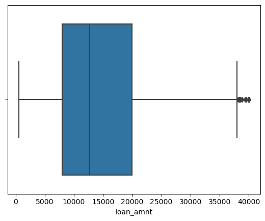

```python
#Skewness and Kurtosis
print("Skewness: %f" % df['loan_amnt'].skew())
print("Kurtosis: %f" % df['loan_amnt'].kurt())
sns.boxplot(x=df['loan_amnt'])
```

There were few individuals surveyed in some levels of loan amount. However, it does look faily balanced as there isn't any evident patterns in the count.

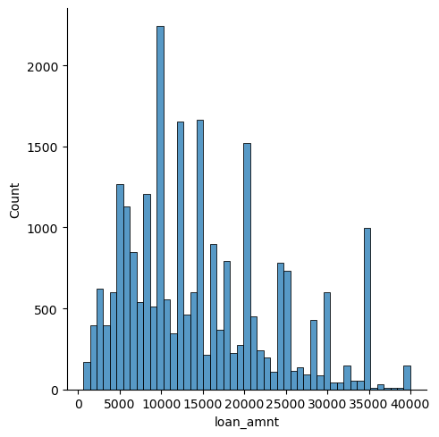

```python
sns.displot(df['loan_amnt'])
```

```python
df['loan_amnt'].describe()
```

```
count    24999.000000
mean     14687.002480
std       8763.621362
min        600.000000
25%       8000.000000
50%      12725.000000
75%      20000.000000
max      40000.000000
Name: loan_amnt, dtype: float64
```

### Interset Rate

The data type for the variable 'int_rate' is a float64. This is a numerical variable which is great as it doesn't need to be transformed for the model.

```python
df['int_rate'].info()
```

```
<class 'pandas.core.series.Series'>
RangeIndex: 25000 entries, 0 to 24999
Series name: int_rate
Non-Null Count  Dtype
--------------  -----
24999 non-null  float64
dtypes: float64(1)
memory usage: 195.4 KB
```

There appears to be 1 missing value in Row #23975 which shouldn't be a problem as it can be easily removed later on.

```python
df['int_rate'].isnull().sum()
df[df['int_rate'].isna()]
```

|  | Unnamed: 0 | id | member_id | loan_amnt | term | int_rate | installment | grade | sub_grade | emp_title | emp_length | home_ownership | annual_inc | verification_status | loan_status | pymnt_plan | desc | purpose | title | zip_code | addr_state | dti | delinq_2yrs | earliest_cr_line | fico_range_low | fico_range_high | inq_last_6mths | mths_since_last_delinq | mths_since_last_record | … |
| --- | --- | --- | --- | --- | --- | --- | --- | --- | --- | --- | --- | --- | --- | --- | --- | --- | --- | --- | --- | --- | --- | --- | --- | --- | --- | --- | --- | --- | --- | --- |
| 23975 | 23975 | 804718 | Total amount funded in policy code 2: 608903141 | NaN | NaN | NaN | NaN | NaN | NaN | NaN | NaN | NaN | NaN | NaN | NaN | NaN | NaN | NaN | NaN | NaN | NaN | NaN | NaN | NaN | NaN | NaN | NaN | NaN | NaN | … |

There appears to be 24555 rows where the 'int_rate' appears more than once. I wouldn't say this is a big issue because its very common to take out loans with the same interest rate as other individuals. When taking a breif look at the first 5 and last 5 duplicates we can see that other columns vary. I want to capture how a different combination of of variables while keeping interest rates constant will impact the probability of an individual defaulting. Due to this reason I will keep the duplicates.

```python
print(df['int_rate'].duplicated().sum())
dup = df[df['int_rate'].duplicated(keep=False)]
dup.sort_values(by=['int_rate'])
```

```
24555
```

|  | Unnamed: 0 | id | member_id | loan_amnt | term | int_rate | installment | grade | sub_grade | emp_title | emp_length | home_ownership | annual_inc | verification_status | loan_status | pymnt_plan | desc | purpose | title | zip_code | addr_state | dti | delinq_2yrs | earliest_cr_line | fico_range_low | fico_range_high | inq_last_6mths | mths_since_last_delinq | mths_since_last_record | … |
| --- | --- | --- | --- | --- | --- | --- | --- | --- | --- | --- | --- | --- | --- | --- | --- | --- | --- | --- | --- | --- | --- | --- | --- | --- | --- | --- | --- | --- | --- | --- |
| 11378 | 11378 | 1012124 | 102345184 | 15000.0 | 36 months | 5.32 | 451.73 | A | A1 | QA Manager | 10+ years | MORTGAGE | 75000.0 | Source Verified | Fully Paid | n | NaN | credit_card | Credit card refinancing | 747xx | OK | 6.78 | 0.0 | 1988-05-01 00:00:00 | 740.0 | 744.0 | 0.0 | NaN | NaN | … |
| 10938 | 10938 | 415471 | 60706950 | 16000.0 | 36 months | 5.32 | 481.84 | A | A1 | Advisor | 2 years | MORTGAGE | 145000.0 | Not Verified | Fully Paid | n | NaN | debt_consolidation | Debt consolidation | 232xx | VA | 15.01 | 0.0 | 1999-11-01 00:00:00 | 775.0 | 779.0 | 0.0 | NaN | NaN | … |
| 10932 | 10932 | 498559 | 55139001 | 13000.0 | 36 months | 5.32 | 391.50 | A | A1 | agent | 9 years | MORTGAGE | 99000.0 | Source Verified | Fully Paid | n | NaN | credit_card | Credit card refinancing | 799xx | TX | 10.80 | 0.0 | 2005-03-01 00:00:00 | 755.0 | 759.0 | 0.0 | NaN | NaN | … |
| 10908 | 10908 | 332925 | 65671331 | 12000.0 | 36 months | 5.32 | 361.38 | A | A1 | Senior Engineer | 10+ years | MORTGAGE | 93600.0 | Source Verified | Current | n | NaN | debt_consolidation | Debt consolidation | 445xx | OH | 16.22 | 0.0 | 1987-08-01 00:00:00 | 685.0 | 689.0 | 0.0 | NaN | NaN | … |
| 10906 | 10906 | 1367469 | 78318313 | 22000.0 | 36 months | 5.32 | 662.53 | A | A1 | owner | 5 years | MORTGAGE | 70000.0 | Source Verified | Fully Paid | n | NaN | credit_card | Credit card refinancing | 463xx | IN | 16.94 | 0.0 | 2006-03-01 00:00:00 | 785.0 | 789.0 | 0.0 | NaN | NaN | … |
| ... | ... | ... | ... | ... | ... | ... | ... | ... | ... | ... | ... | ... | ... | ... | ... | ... | ... | ... | ... | ... | ... | ... | ... | ... | ... | ... | ... | ... | ... | … |
| 5130 | 5130 | 1416707 | 93930151 | 11200.0 | 60 months | 30.99 | 369.20 | G | G5 | Teacher | 5 years | MORTGAGE | 50000.0 | Not Verified | In Grace Period | n | NaN | debt_consolidation | Debt consolidation | 871xx | NM | 30.60 | 1.0 | 1976-12-01 00:00:00 | 665.0 | 669.0 | 0.0 | 6.0 | NaN | … |
| 2656 | 2656 | 1223536 | 117876161 | 18700.0 | 36 months | 30.99 | 804.02 | G | G5 | Welder | < 1 year | RENT | 52000.0 | Verified | Current | n | NaN | other | Other | 432xx | OH | 14.56 | 0.0 | 2007-08-01 00:00:00 | 675.0 | 679.0 | 2.0 | NaN | NaN | … |
| 17797 | 17797 | 1343230 | 78719510 | 21000.0 | 60 months | 30.99 | 692.25 | G | G5 | lending manager | 10+ years | OWN | 110000.0 | Source Verified | Current | n | NaN | debt_consolidation | Debt consolidation | 554xx | MN | 26.93 | 0.0 | 1994-10-01 00:00:00 | 660.0 | 664.0 | 3.0 | 36.0 | 71.0 | … |
| 3227 | 3227 | 1191544 | 119768071 | 11500.0 | 60 months | 30.99 | 379.09 | G | G5 | Manager | 2 years | RENT | 28800.0 | Not Verified | Current | n | NaN | other | Other | 301xx | GA | 12.33 | 0.0 | 2014-07-01 00:00:00 | 705.0 | 709.0 | 0.0 | NaN | NaN | … |
| 12165 | 12165 | 702056 | 111776955 | 20000.0 | 60 months | 30.99 | 659.29 | G | G5 | Product Developer | 1 year | RENT | 76000.0 | Source Verified | Current | n | NaN | debt_consolidation | Debt consolidation | 110xx | NY | 17.07 | 0.0 | 2004-08-01 00:00:00 | 660.0 | 664.0 | 0.0 | NaN | 69.0 | … |

24927 rows × 135 columns

According to the Skewness and Kurtosis values, the 'int_rate' column exhibits a right skewed. The distribution of the interst rate column has a short tails as all the outliers appear on the right of the upper whisker. I would like to capture how these individuals with high levels on interest rates behave so I will keep the outliers.

```
Skewness: 0.733792
Kurtosis: 0.593184
```

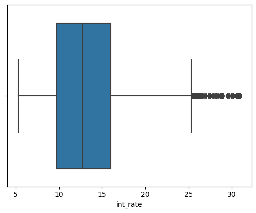

```python
#Skewness and Kurtosis
print("Skewness: %f" % df['int_rate'].skew())
print("Kurtosis: %f" % df['int_rate'].kurt())
sns.boxplot(x=df['int_rate'])
```

When looking at the interest rate, it doesn't seem like the spread is balanced as there aren't many individuals with interest rate >19%

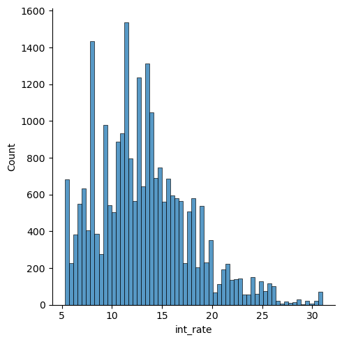

```python
sns.displot(df['int_rate'])
```

```python
df['int_rate'].describe()
```

```
count    24999.000000
mean        13.218843
std          4.741118
min          5.320000
25%          9.760000
50%         12.740000
75%         15.990000
max         30.990000
Name: int_rate, dtype: float64
```

### Installment

The data type for the variable 'installment' is a float64. This is a numerical variable which is great as it doesn't need to be transformed for the model.

```python
df['installment'].info()
```

```
<class 'pandas.core.series.Series'>
RangeIndex: 25000 entries, 0 to 24999
Series name: installment
Non-Null Count  Dtype
--------------  -----
24999 non-null  float64
dtypes: float64(1)
memory usage: 195.4 KB
```

There appears to be 1 missing value in Row #23975 which shouldn't be a problem as it can be easily removed later on.

```python
df['installment'].isnull().sum()
df[df['installment'].isna()]
```

|  | Unnamed: 0 | id | member_id | loan_amnt | term | int_rate | installment | grade | sub_grade | emp_title | emp_length | home_ownership | annual_inc | verification_status | loan_status | pymnt_plan | desc | purpose | title | zip_code | addr_state | dti | delinq_2yrs | earliest_cr_line | fico_range_low | fico_range_high | inq_last_6mths | mths_since_last_delinq | mths_since_last_record | … |
| --- | --- | --- | --- | --- | --- | --- | --- | --- | --- | --- | --- | --- | --- | --- | --- | --- | --- | --- | --- | --- | --- | --- | --- | --- | --- | --- | --- | --- | --- | --- |
| 23975 | 23975 | 804718 | Total amount funded in policy code 2: 608903141 | NaN | NaN | NaN | NaN | NaN | NaN | NaN | NaN | NaN | NaN | NaN | NaN | NaN | NaN | NaN | NaN | NaN | NaN | NaN | NaN | NaN | NaN | NaN | NaN | NaN | NaN | … |

There appears to be 13285 rows where the 'installment' appears more than once. I wouldn't say this is a big issue because its very common to take out loans with the same monthly payments as other individuals. When taking a breif look at the first 5 and last 5 duplicates we can see that other columns vary. I want to capture how a different combination of variables while keeping installments constant will impact the probability of an individual defaulting. Due to this reason I will keep the duplicates.

```python
print(df['installment'].duplicated().sum())
dup = df[df['installment'].duplicated(keep=False)]
dup.sort_values(by=['installment'])
```

```
13285
```

|  | Unnamed: 0 | id | member_id | loan_amnt | term | int_rate | installment | grade | sub_grade | emp_title | emp_length | home_ownership | annual_inc | verification_status | loan_status | pymnt_plan | desc | purpose | title | zip_code | addr_state | dti | delinq_2yrs | earliest_cr_line | fico_range_low | fico_range_high | inq_last_6mths | mths_since_last_delinq | mths_since_last_record | … |
| --- | --- | --- | --- | --- | --- | --- | --- | --- | --- | --- | --- | --- | --- | --- | --- | --- | --- | --- | --- | --- | --- | --- | --- | --- | --- | --- | --- | --- | --- | --- |
| 16400 | 16400 | 1462370 | 92991888 | 1000.0 | 36 months | 7.99 | 31.34 | A | A5 | Professor | < 1 year | MORTGAGE | 74000.0 | Verified | Fully Paid | n | NaN | small_business | Business | 957xx | CA | 16.84 | 1.0 | 1992-03-01 00:00:00 | 715.0 | 719.0 | 0.0 | 4.0 | NaN | … |
| 891 | 891 | 1494007 | 91355274 | 1000.0 | 36 months | 7.99 | 31.34 | A | A5 | Billing Coordinator | 3 years | RENT | 40000.0 | Not Verified | Fully Paid | n | NaN | other | Other | 211xx | MD | 3.15 | 0.0 | 2011-09-01 00:00:00 | 735.0 | 739.0 | 0.0 | NaN | NaN | … |
| 24293 | 24293 | 1293733 | 113094099 | 1000.0 | 36 months | 9.44 | 32.01 | B | B1 | Police Officer | < 1 year | RENT | 44000.0 | Not Verified | Current | n | NaN | credit_card | Credit card refinancing | 563xx | MN | 11.81 | 0.0 | 2007-07-01 00:00:00 | 670.0 | 674.0 | 0.0 | 30.0 | NaN | … |
| 22582 | 22582 | 1204599 | 117949283 | 1000.0 | 36 months | 9.44 | 32.01 | B | B1 | Librarian | 3 years | RENT | 55123.0 | Source Verified | Current | n | NaN | other | Other | 111xx | NY | 11.39 | 0.0 | 2002-08-01 00:00:00 | 725.0 | 729.0 | 1.0 | NaN | NaN | … |
| 14409 | 14409 | 1217727 | 118321254 | 1000.0 | 36 months | 9.93 | 32.24 | B | B2 | CSR PAP Compliance | < 1 year | RENT | 25000.0 | Source Verified | Current | n | NaN | credit_card | Credit card refinancing | 271xx | NC | 18.00 | 0.0 | 2010-05-01 00:00:00 | 670.0 | 674.0 | 0.0 | NaN | NaN | … |
| ... | ... | ... | ... | ... | ... | ... | ... | ... | ... | ... | ... | ... | ... | ... | ... | ... | ... | ... | ... | ... | ... | ... | ... | ... | ... | ... | ... | ... | ... | … |
| 13465 | 13465 | 719077 | 109739714 | 40000.0 | 36 months | 16.02 | 1406.68 | C | C5 | Managing Partner | 8 years | RENT | 150000.0 | Verified | Current | n | NaN | debt_consolidation | Debt consolidation | 902xx | CA | 24.56 | 0.0 | 2001-03-01 00:00:00 | 700.0 | 704.0 | 2.0 | 66.0 | NaN | … |
| 13734 | 13734 | 1202269 | 119258833 | 40000.0 | 36 months | 16.02 | 1406.68 | C | C5 | court officer | 4 years | MORTGAGE | 120000.0 | Source Verified | Current | n | NaN | debt_consolidation | Debt consolidation | 109xx | NY | 15.67 | 0.0 | 2004-06-01 00:00:00 | 735.0 | 739.0 | 0.0 | NaN | NaN | … |
| 19307 | 19307 | 715640 | 110355731 | 40000.0 | 36 months | 16.02 | 1406.68 | C | C5 | Service Technician | 3 years | RENT | 85000.0 | Verified | Current | n | NaN | credit_card | Credit card refinancing | 782xx | TX | 15.71 | 0.0 | 2003-03-01 00:00:00 | 705.0 | 709.0 | 0.0 | NaN | NaN | … |
| 5939 | 5939 | 779878 | 105403176 | 40000.0 | 36 months | 16.99 | 1425.92 | D | D1 | Sr. Quality Control Manager | 7 years | MORTGAGE | 132000.0 | Verified | Current | n | NaN | debt_consolidation | Debt consolidation | 221xx | VA | 21.26 | 1.0 | 2004-12-01 00:00:00 | 685.0 | 689.0 | 0.0 | 21.0 | NaN | … |
| 21588 | 21588 | 1016018 | 99232056 | 40000.0 | 36 months | 16.99 | 1425.92 | D | D1 | Materials Scientist, President | 10+ years | MORTGAGE | 120000.0 | Verified | Charged Off | n | NaN | small_business | Business | 148xx | NY | 7.27 | 0.0 | 2001-06-01 00:00:00 | 740.0 | 744.0 | 2.0 | NaN | NaN | … |

17176 rows × 135 columns

According to the Skewness and Kurtosis values, the 'installment' column exhibits a right skewed. The distribution of the interst rate column has a short tails as all the outliers appear on the right of the upper whisker. I would like to capture how these individuals with high levels of monthly payments behave so I will keep the outliers.

```
Skewness: 1.003158
Kurtosis: 0.854328
```

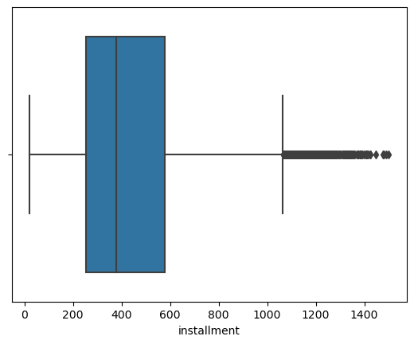

```python
#skewness and kurtosis
print("Skewness: %f" % df['installment'].skew())
print("Kurtosis: %f" % df['installment'].kurt())
sns.boxplot(x=df['installment'])
```

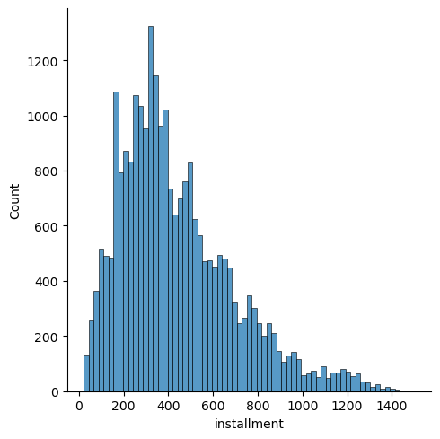

```python
sns.displot(df['installment'])
```

```python
df['installment'].describe()
```

```
count    24999.000000
mean       436.788993
std        256.009134
min         21.590000
25%        251.580000
50%        377.620000
75%        577.035000
max       1501.000000
Name: installment, dtype: float64
```

### Annual Income

The data type for the variable 'annual_inc' is a float64. This is a numerical variable which is great as it doesn't need to be transformed for the model.

```python
df['annual_inc'].info()
```

```
<class 'pandas.core.series.Series'>
RangeIndex: 25000 entries, 0 to 24999
Series name: annual_inc
Non-Null Count  Dtype
--------------  -----
24999 non-null  float64
dtypes: float64(1)
memory usage: 195.4 KB
```

There appears to be 1 missing value in Row #23975 which shouldn't be a problem as it can be easily removed later on.

```python
print(df['annual_inc'].isnull().sum())
df[df['annual_inc'].isna()]
```

```
1
```

|  | Unnamed: 0 | id | member_id | loan_amnt | term | int_rate | installment | grade | sub_grade | emp_title | emp_length | home_ownership | annual_inc | verification_status | loan_status | pymnt_plan | desc | purpose | title | zip_code | addr_state | dti | delinq_2yrs | earliest_cr_line | fico_range_low | fico_range_high | inq_last_6mths | mths_since_last_delinq | mths_since_last_record | … |
| --- | --- | --- | --- | --- | --- | --- | --- | --- | --- | --- | --- | --- | --- | --- | --- | --- | --- | --- | --- | --- | --- | --- | --- | --- | --- | --- | --- | --- | --- | --- |
| 23975 | 23975 | 804718 | Total amount funded in policy code 2: 608903141 | NaN | NaN | NaN | NaN | NaN | NaN | NaN | NaN | NaN | NaN | NaN | NaN | NaN | NaN | NaN | NaN | NaN | NaN | NaN | NaN | NaN | NaN | NaN | NaN | NaN | NaN | … |

There appears to be 21903 rows where the 'annual_inc' appears more than once. I wouldn't say this is a big issue because its very common to have similar incomes to other individuals especially when annual income are typically rounded. When taking a breif look at the first 5 and last 5 duplicates we can see that other columns vary. I want to capture how a different combination of variables while keeping annual income constant will impact the probability of an individual defaulting. Due to this reason I will keep the duplicates.

```python
print(df['annual_inc'].duplicated().sum())
dup = df[df['annual_inc'].duplicated(keep=False)]
dup.sort_values(by=['annual_inc'])
```

```
21903
```

|  | Unnamed: 0 | id | member_id | loan_amnt | term | int_rate | installment | grade | sub_grade | emp_title | emp_length | home_ownership | annual_inc | verification_status | loan_status | pymnt_plan | desc | purpose | title | zip_code | addr_state | dti | delinq_2yrs | earliest_cr_line | fico_range_low | fico_range_high | inq_last_6mths | mths_since_last_delinq | mths_since_last_record | … |
| --- | --- | --- | --- | --- | --- | --- | --- | --- | --- | --- | --- | --- | --- | --- | --- | --- | --- | --- | --- | --- | --- | --- | --- | --- | --- | --- | --- | --- | --- | --- |
| 12012 | 12012 | 1220395 | 117561794 | 6400.0 | 36 months | 13.59 | 217.47 | C | C2 | NaN | NaN | MORTGAGE | 0.0 | Not Verified | Current | n | NaN | debt_consolidation | Debt consolidation | 320xx | FL | NaN | 0.0 | 2009-06-01 00:00:00 | 675.0 | 679.0 | 0.0 | NaN | NaN | … |
| 20830 | 20830 | 766060 | 106788277 | 32000.0 | 60 months | 15.99 | 778.01 | C | C5 | Owner | < 1 year | MORTGAGE | 0.0 | Not Verified | Current | n | NaN | debt_consolidation | Debt consolidation | 761xx | TX | NaN | 0.0 | 2006-12-01 00:00:00 | 700.0 | 704.0 | 0.0 | NaN | 116.0 | … |
| 7015 | 7015 | 1308906 | 111045991 | 19200.0 | 36 months | 14.08 | 656.96 | C | C3 | NaN | NaN | RENT | 0.0 | Not Verified | Current | n | NaN | moving | Moving and relocation | 321xx | FL | NaN | 0.0 | 1999-02-01 00:00:00 | 665.0 | 669.0 | 0.0 | 27.0 | NaN | … |
| 21188 | 21188 | 1253816 | 115051365 | 12000.0 | 60 months | 26.30 | 361.42 | E | E5 | NaN | NaN | MORTGAGE | 0.0 | Not Verified | Current | n | NaN | credit_card | Credit card refinancing | 856xx | AZ | NaN | 0.0 | 2006-07-01 00:00:00 | 670.0 | 674.0 | 0.0 | NaN | NaN | … |
| 10380 | 10380 | 719761 | 110672834 | 23775.0 | 36 months | 16.02 | 836.10 | C | C5 | NaN | NaN | MORTGAGE | 0.0 | Not Verified | Current | n | NaN | debt_consolidation | Debt consolidation | 781xx | TX | NaN | 0.0 | 2006-12-01 00:00:00 | 710.0 | 714.0 | 0.0 | NaN | NaN | … |
| ... | ... | ... | ... | ... | ... | ... | ... | ... | ... | ... | ... | ... | ... | ... | ... | ... | ... | ... | ... | ... | ... | ... | ... | ... | ... | ... | ... | ... | ... | … |
| 10426 | 10426 | 447724 | 58450649 | 24000.0 | 36 months | 17.57 | 862.49 | D | D4 | Program Manager | 8 years | MORTGAGE | 800000.0 | Source Verified | Fully Paid | n | NaN | debt_consolidation | Debt consolidation | 075xx | NJ | 2.17 | 3.0 | 1992-11-01 00:00:00 | 670.0 | 674.0 | 2.0 | NaN | 89.0 | … |
| 24476 | 24476 | 589411 | 46537433 | 7500.0 | 36 months | 6.92 | 231.31 | A | A4 | Assistant Athletic Director, Stadium Mgr | 1 year | MORTGAGE | 1000000.0 | Source Verified | Charged Off | n | NaN | debt_consolidation | Debt consolidation | 400xx | KY | 1.96 | 2.0 | 1991-08-01 00:00:00 | 730.0 | 734.0 | 0.0 | 12.0 | NaN | … |
| 6921 | 6921 | 1593135 | 71472622 | 20000.0 | 36 months | 7.89 | 625.72 | A | A5 | Driver | 10+ years | OWN | 1000000.0 | Verified | Charged Off | n | NaN | credit_card | Credit card refinancing | 882xx | NM | 2.66 | 0.0 | 2003-03-01 00:00:00 | 685.0 | 689.0 | 1.0 | NaN | NaN | … |
| 3086 | 3086 | 1032445 | 97993825 | 16000.0 | 36 months | 12.74 | 537.11 | C | C1 | President | 10+ years | MORTGAGE | 1500000.0 | Verified | Fully Paid | n | NaN | major_purchase | Major purchase | 330xx | FL | 5.34 | 0.0 | 1995-11-01 00:00:00 | 705.0 | 709.0 | 1.0 | NaN | NaN | … |
| 14819 | 14819 | 1619784 | 69874070 | 30000.0 | 36 months | 9.17 | 956.37 | B | B2 | Managing Director | 10+ years | RENT | 1500000.0 | Source Verified | Current | n | NaN | moving | Moving and relocation | 100xx | NY | 3.37 | 0.0 | 1991-09-01 00:00:00 | 715.0 | 719.0 | 0.0 | NaN | NaN | … |

22554 rows × 135 columns

```
Skewness: 5.835136
Kurtosis: 80.960307
```

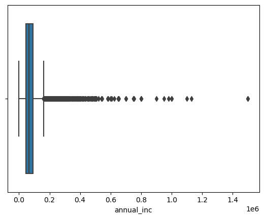

```python
#skewness and kurtosis
print("Skewness: %f" % df['annual_inc'].skew())
print("Kurtosis: %f" % df['annual_inc'].kurt())
sns.boxplot(x=df['annual_inc'])
```

The annual income is spread does appear to be too balanced as there aren't many people surveyed with high incomes. The x-axis goes to 1.5 million and we can't really see the bar, but there are most likely to be 1-5 people in these bins.

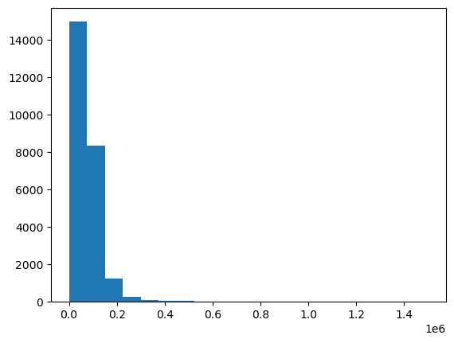

```python
plt.hist(df['annual_inc'],bins=20)
```

```python
df['annual_inc'].describe()
```

```
count    2.499900e+04
mean     7.706611e+04
std      5.497013e+04
min      0.000000e+00
25%      4.600000e+04
50%      6.500000e+04
75%      9.200000e+04
max      1.500000e+06
Name: annual_inc, dtype: float64
```

### Employment Length

The data type for the variable 'emp_length' is a object. There are symbols, numbers, and letter within this column. This column will need to be altered in order to be used for the model.

```python
df['emp_length'].info()
```

```
<class 'pandas.core.series.Series'>
RangeIndex: 25000 entries, 0 to 24999
Series name: emp_length
Non-Null Count  Dtype
--------------  -----
23498 non-null  object
dtypes: object(1)
memory usage: 195.4+ KB
```

There appears to be 1502 missing value which shouldn't be a problem as it can be easily removed later on. 1502 rows can be removed without impacting that data too much as there are 25000 rows.

```python
df['emp_length'].isnull().sum()
```

```
1502
```

There are 24988 duplicates within the column 'emp_length', this is understandable as this column only have values from 1 to 10

```python
print(df['emp_length'].duplicated().sum())
```

```
24988
```

Below I am converting the column into a numerical variable to perform calculations regarding the spread and distribution.

```python
df=df.replace('< 1 year','0 years')
emp_length_numeric = df.emp_length.str.extract('(^\d*)')
df['emp_length'] = emp_length_numeric
df
```

|  | Unnamed: 0 | id | member_id | loan_amnt | term | int_rate | installment | grade | sub_grade | emp_title | emp_length | home_ownership | annual_inc | verification_status | loan_status | pymnt_plan | desc | purpose | title | zip_code | addr_state | dti | delinq_2yrs | earliest_cr_line | fico_range_low | fico_range_high | inq_last_6mths | mths_since_last_delinq | mths_since_last_record | … |
| --- | --- | --- | --- | --- | --- | --- | --- | --- | --- | --- | --- | --- | --- | --- | --- | --- | --- | --- | --- | --- | --- | --- | --- | --- | --- | --- | --- | --- | --- | --- |
| 0 | 0 | 263591 | 545710 | 20000.0 | 60 months | 17.93 | 342.94 | E | E5 | Wylie ISD | 1 | MORTGAGE | 44304.0 | Verified | Charged Off | n | NaN | debt_consolidation | Todd's Loan | 750xx | TX | 18.47 | 0.0 | 1995-11-01 00:00:00 | 690.0 | 694.0 | 0.0 | 33.0 | NaN | … |
| 1 | 1 | 1613916 | 69664096 | 30000.0 | 36 months | 11.99 | 996.29 | C | C1 | Sergeant | 10 | MORTGAGE | 136000.0 | Verified | Current | n | NaN | debt_consolidation | Debt consolidation | 080xx | NJ | 20.63 | 3.0 | 2003-10-01 00:00:00 | 670.0 | 674.0 | 1.0 | 7.0 | 73.0 | … |
| 2 | 2 | 818934 | 8965180 | 21500.0 | 36 months | 11.99 | 714.01 | B | B3 | Designer | 1 | RENT | 50000.0 | Source Verified | Fully Paid | n | Borrower added on 11/24/13 > We are consolidating our debt so we can get it paid off to purchase a home<br> | debt_consolidation | Debt Be Gone | 760xx | TX | 29.62 | 0.0 | 1999-10-01 00:00:00 | 735.0 | 739.0 | 1.0 | NaN | NaN | … |
| 3 | 3 | 1606612 | 70572960 | 10000.0 | 36 months | 13.67 | 340.18 | C | C3 | NaN | NaN | RENT | 64400.0 | Source Verified | Fully Paid | n | NaN | debt_consolidation | Debt consolidation | 029xx | RI | 16.68 | 3.0 | 1983-11-01 00:00:00 | 675.0 | 679.0 | 0.0 | 8.0 | NaN | … |
| 4 | 4 | 1639932 | 68589517 | 5000.0 | 36 months | 8.49 | 157.82 | B | B1 | Sr. Manufacturing Engineer | 10 | MORTGAGE | 88000.0 | Source Verified | Current | n | NaN | debt_consolidation | Debt consolidation | 301xx | GA | 5.32 | 0.0 | 2000-04-01 00:00:00 | 660.0 | 664.0 | 0.0 | 27.0 | NaN | … |
| ... | ... | ... | ... | ... | ... | ... | ... | ... | ... | ... | ... | ... | ... | ... | ... | ... | ... | ... | ... | ... | ... | ... | ... | ... | ... | ... | ... | ... | ... | … |
| 24995 | 24995 | 901888 | 4974773 | 10500.0 | 36 months | 10.16 | 339.60 | B | B1 | Schneider Electric | 5 | MORTGAGE | 78000.0 | Not Verified | Fully Paid | n | Borrower added on 05/07/13 > My loan is for a home renovation project. I am replacing my front steps, which are falling apart. In addition I am having a front porch built and a 20' section of ... | home_improvement | Front Porch & Wall Removal/Support | 021xx | MA | 9.58 | 0.0 | 1998-04-01 00:00:00 | 685.0 | 689.0 | 1.0 | NaN | NaN | … |
| 24996 | 24996 | 945413 | 1279809 | 12000.0 | 36 months | 14.33 | 412.06 | C | C1 | Clark County School District | 10 | RENT | 82000.0 | Not Verified | Fully Paid | n | Borrower added on 11/24/12 > I am looking to be debt free in three years. Consolidating my debt into one payment is something I am really looking forward to.<br> | debt_consolidation | Consolidation Loan | 891xx | NV | 11.75 | 0.0 | 1995-07-01 00:00:00 | 690.0 | 694.0 | 1.0 | NaN | NaN | … |
| 24997 | 24997 | 366944 | 63496281 | 25000.0 | 36 months | 12.69 | 838.63 | C | C2 | sales consultant | 0 | MORTGAGE | 60000.0 | Source Verified | Late (31-120 days) | n | NaN | debt_consolidation | Debt consolidation | 325xx | FL | 13.34 | 1.0 | 1996-12-01 00:00:00 | 665.0 | 669.0 | 1.0 | 14.0 | NaN | … |
| 24998 | 24998 | 1043529 | 98124387 | 12200.0 | 60 months | 13.49 | 280.66 | C | C2 | NaN | NaN | OWN | 44400.0 | Not Verified | Current | n | NaN | debt_consolidation | Debt consolidation | 010xx | MA | 10.59 | 0.0 | 2002-05-01 00:00:00 | 695.0 | 699.0 | 0.0 | NaN | NaN | … |
| 24999 | 24999 | 1239942 | 115704642 | 5000.0 | 36 months | 19.03 | 183.36 | D | D3 | Web Developer | 6 | RENT | 50000.0 | Source Verified | Current | n | NaN | small_business | Business | 906xx | CA | 27.43 | 0.0 | 2007-01-01 00:00:00 | 660.0 | 664.0 | 0.0 | 32.0 | NaN | … |

25000 rows × 135 columns

```python
Emp_Length_Data = df.dropna(subset=['emp_length'])
Emp_Length_Data['emp_length'] = pd.to_numeric(Emp_Length_Data['emp_length'])
```

```
Skewness: -0.239748
Kurtosis: -1.492397
```

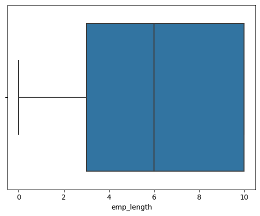

```python
#skewness and kurtosis
print("Skewness: %f" % Emp_Length_Data['emp_length'].skew())
print("Kurtosis: %f" % Emp_Length_Data['emp_length'].kurt())
sns.boxplot(x=Emp_Length_Data['emp_length'])
```

The data does appear to be somwhat balance when disregarding the individuals who have worked 10+ years

```
([0, 1, 2, 3, 4, 5, 6, 7, 8, 9, 10],
 [Text(0, 0, '1'),
```

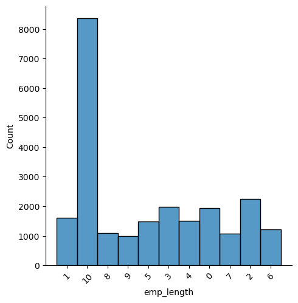

```python
sns.displot(df['emp_length'])
plt.xticks(rotation=45)
```

```python
Emp_Length_Data['emp_length'].describe()
```

```
count    23498.000000
mean         6.024555
std          3.687065
min          0.000000
25%          3.000000
50%          6.000000
75%         10.000000
max         10.000000
Name: emp_length, dtype: float64
```

### Debt to Income Ratio (DTI)

The data type for the variable 'dti' is a float64. This is a numerical variable which is great as it doesn't need to be transformed for the model.

```python
df['dti'].info()
```

```
<class 'pandas.core.series.Series'>
RangeIndex: 25000 entries, 0 to 24999
Series name: dti
Non-Null Count  Dtype
--------------  -----
24988 non-null  float64
dtypes: float64(1)
memory usage: 195.4 KB
```

There appears to be 12 missing value which shouldn't be a problem as it can be easily removed later on. 12 rows can be removed without impacting that data too much as there are 25000 rows.

```python
df['dti'].isnull().sum()
```

```
12
```

There appears to be 21146 rows where the 'dti' appears more than once. When taking a breif look at the first 5 and last 5 duplicates we can see that other columns vary. I want to capture how a different combination of variables while keeping DTI constant will impact the probability of an individual defaulting. Due to this reason I will keep the duplicates

```python
print(df['dti'].duplicated().sum())
dup = df[df['dti'].duplicated(keep=False)]
dup.sort_values(by=['dti'])
```

```
21146
```

|  | Unnamed: 0 | id | member_id | loan_amnt | term | int_rate | installment | grade | sub_grade | emp_title | emp_length | home_ownership | annual_inc | verification_status | loan_status | pymnt_plan | desc | purpose | title | zip_code | addr_state | dti | delinq_2yrs | earliest_cr_line | fico_range_low | fico_range_high | inq_last_6mths | mths_since_last_delinq | mths_since_last_record | … |
| --- | --- | --- | --- | --- | --- | --- | --- | --- | --- | --- | --- | --- | --- | --- | --- | --- | --- | --- | --- | --- | --- | --- | --- | --- | --- | --- | --- | --- | --- | --- |
| 13878 | 13878 | 1413896 | 95755186 | 35000.0 | 36 months | 15.99 | 1230.33 | C | C5 | Merchandise Planner | 7 | OWN | 90000.0 | Source Verified | Current | n | NaN | major_purchase | Major purchase | 071xx | NJ | 0.0 | 1.0 | 2002-11-01 00:00:00 | 820.0 | 824.0 | 0.0 | 22.0 | NaN | … |
| 21174 | 21174 | 1001578 | 102584773 | 18000.0 | 36 months | 11.49 | 593.49 | B | B5 | NaN | NaN | OWN | 51288.0 | Verified | Current | n | NaN | major_purchase | Major purchase | 908xx | CA | 0.0 | 0.0 | 2006-05-01 00:00:00 | 675.0 | 679.0 | 0.0 | NaN | 30.0 | … |
| 1322 | 1322 | 273045 | 382001 | 8000.0 | 36 months | 12.21 | 266.52 | B | B5 | Self Employed | 4 | RENT | 20000.0 | Not Verified | Fully Paid | n | I'm working on getting out of debt, and it would be really nice to have a lower interest rate than what I'm currently paying. I am a self-employed web programmer/martial arts instructor working o... | credit_card | Help me get out of debt. | 961xx | CA | 0.0 | 0.0 | 1997-11-01 00:00:00 | 770.0 | 774.0 | 0.0 | NaN | NaN | … |
| 10593 | 10593 | 196978 | 12895761 | 10000.0 | 36 months | 14.64 | 344.90 | C | C3 | semi driver | 10 | MORTGAGE | 90000.0 | Verified | Fully Paid | n | Borrower added on 03/12/14 > Roof front porch<br> | home_improvement | Home improvement | 471xx | IN | 0.0 | 0.0 | 2002-09-01 00:00:00 | 700.0 | 704.0 | 1.0 | NaN | 101.0 | … |
| 11088 | 11088 | 709867 | 111156879 | 1000.0 | 36 months | 15.05 | 34.69 | C | C4 | Research Technician | 4 | RENT | 40000.0 | Not Verified | Current | n | NaN | car | Car financing | 769xx | TX | 0.0 | 0.0 | 1999-05-01 00:00:00 | 755.0 | 759.0 | 0.0 | NaN | NaN | … |
| ... | ... | ... | ... | ... | ... | ... | ... | ... | ... | ... | ... | ... | ... | ... | ... | ... | ... | ... | ... | ... | ... | ... | ... | ... | ... | ... | ... | ... | ... | … |
| 20830 | 20830 | 766060 | 106788277 | 32000.0 | 60 months | 15.99 | 778.01 | C | C5 | Owner | 0 | MORTGAGE | 0.0 | Not Verified | Current | n | NaN | debt_consolidation | Debt consolidation | 761xx | TX | NaN | 0.0 | 2006-12-01 00:00:00 | 700.0 | 704.0 | 0.0 | NaN | 116.0 | … |
| 21188 | 21188 | 1253816 | 115051365 | 12000.0 | 60 months | 26.30 | 361.42 | E | E5 | NaN | NaN | MORTGAGE | 0.0 | Not Verified | Current | n | NaN | credit_card | Credit card refinancing | 856xx | AZ | NaN | 0.0 | 2006-07-01 00:00:00 | 670.0 | 674.0 | 0.0 | NaN | NaN | … |
| 23435 | 23435 | 1288672 | 112486737 | 15900.0 | 36 months | 17.09 | 567.60 | D | D1 | NaN | NaN | RENT | 0.0 | Not Verified | Current | n | NaN | medical | Medical expenses | 347xx | FL | NaN | 0.0 | 2012-09-01 00:00:00 | 720.0 | 724.0 | 0.0 | NaN | NaN | … |
| 23620 | 23620 | 1190299 | 120112121 | 5000.0 | 36 months | 10.42 | 162.33 | B | B3 | NaN | NaN | MORTGAGE | 0.0 | Not Verified | Current | n | NaN | home_improvement | Home improvement | 457xx | OH | NaN | 0.0 | 2008-09-01 00:00:00 | 725.0 | 729.0 | 0.0 | NaN | NaN | … |
| 23975 | 23975 | 804718 | Total amount funded in policy code 2: 608903141 | NaN | NaN | NaN | NaN | NaN | NaN | NaN | NaN | NaN | NaN | NaN | NaN | NaN | NaN | NaN | NaN | NaN | NaN | NaN | NaN | NaN | NaN | NaN | NaN | NaN | NaN | … |

24475 rows × 135 columns

According to the Skewness and Kurtosis values, the 'dti' column exhibits a right skewed. The distribution of the annual income column has a long tails as all the outliers appear on the right of the upper whisker and the Kurtosis is much greater than 3. I would like to capture how these individuals with high levels of DTI will behave so I will keep the outliers.

```
Skewness: 37.009291
Kurtosis: 2382.515150
```

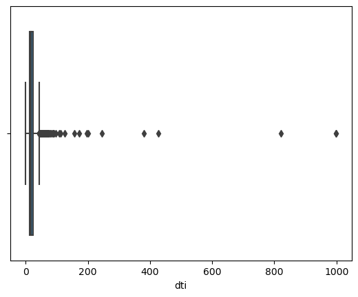

```python
#skewness and kurtosis
print("Skewness: %f" % df['dti'].skew())
print("Kurtosis: %f" % df['dti'].kurt())
sns.boxplot(x=df['dti'])
```

Most individuals appear to have a dti closer to 0 as there arevery few that have dti in the higher levels (such as >49.95)

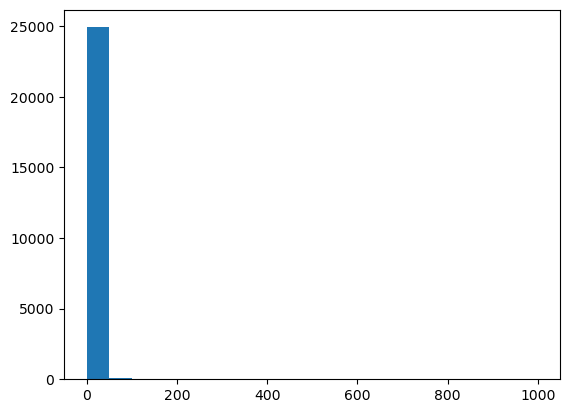

```python
plt.hist(df['dti'],bins=20)
```

```python
df['dti'].describe()
```

```
count    24988.00000
mean        18.61075
std         14.04028
min          0.00000
25%         12.06000
50%         17.81000
75%         24.27000
max        999.00000
Name: dti, dtype: float64
```

### Grade

The data type for the variable 'grade' is a object. There is a letter within this column. This column will need to be altered in order to be used for the model.

```python
df['grade'].info()
```

```
<class 'pandas.core.series.Series'>
RangeIndex: 25000 entries, 0 to 24999
Series name: grade
Non-Null Count  Dtype
--------------  -----
24999 non-null  object
dtypes: object(1)
memory usage: 195.4+ KB
```

```python
df['grade'].isnull().sum()
```

```
1
```

```python
print(df['grade'].duplicated().sum())
```

```
24992
```

```python
df['grade'] = le.fit_transform(df['grade'])
df.head()
```

|  | Unnamed: 0 | id | member_id | loan_amnt | term | int_rate | installment | grade | sub_grade | emp_title | emp_length | home_ownership | annual_inc | verification_status | loan_status | pymnt_plan | desc | purpose | title | zip_code | addr_state | dti | delinq_2yrs | earliest_cr_line | fico_range_low | fico_range_high | inq_last_6mths | mths_since_last_delinq | mths_since_last_record | … |
| --- | --- | --- | --- | --- | --- | --- | --- | --- | --- | --- | --- | --- | --- | --- | --- | --- | --- | --- | --- | --- | --- | --- | --- | --- | --- | --- | --- | --- | --- | --- |
| 0 | 0 | 263591 | 545710 | 20000.0 | 60 months | 17.93 | 342.94 | 4 | E5 | Wylie ISD | 1 | MORTGAGE | 44304.0 | Verified | Charged Off | n | NaN | debt_consolidation | Todd's Loan | 750xx | TX | 18.47 | 0.0 | 1995-11-01 00:00:00 | 690.0 | 694.0 | 0.0 | 33.0 | NaN | … |
| 1 | 1 | 1613916 | 69664096 | 30000.0 | 36 months | 11.99 | 996.29 | 2 | C1 | Sergeant | 10 | MORTGAGE | 136000.0 | Verified | Current | n | NaN | debt_consolidation | Debt consolidation | 080xx | NJ | 20.63 | 3.0 | 2003-10-01 00:00:00 | 670.0 | 674.0 | 1.0 | 7.0 | 73.0 | … |
| 2 | 2 | 818934 | 8965180 | 21500.0 | 36 months | 11.99 | 714.01 | 1 | B3 | Designer | 1 | RENT | 50000.0 | Source Verified | Fully Paid | n | Borrower added on 11/24/13 > We are consolidating our debt so we can get it paid off to purchase a home<br> | debt_consolidation | Debt Be Gone | 760xx | TX | 29.62 | 0.0 | 1999-10-01 00:00:00 | 735.0 | 739.0 | 1.0 | NaN | NaN | … |
| 3 | 3 | 1606612 | 70572960 | 10000.0 | 36 months | 13.67 | 340.18 | 2 | C3 | NaN | NaN | RENT | 64400.0 | Source Verified | Fully Paid | n | NaN | debt_consolidation | Debt consolidation | 029xx | RI | 16.68 | 3.0 | 1983-11-01 00:00:00 | 675.0 | 679.0 | 0.0 | 8.0 | NaN | … |
| 4 | 4 | 1639932 | 68589517 | 5000.0 | 36 months | 8.49 | 157.82 | 1 | B1 | Sr. Manufacturing Engineer | 10 | MORTGAGE | 88000.0 | Source Verified | Current | n | NaN | debt_consolidation | Debt consolidation | 301xx | GA | 5.32 | 0.0 | 2000-04-01 00:00:00 | 660.0 | 664.0 | 0.0 | 27.0 | NaN | … |

There doesn't appear to be too much of a skew for the variable 'grade' as we can approximate a normal. However, there seem to be some outliers. I would like to see how individual with a lower credit grade will behave when paying back a loan. Therefore I will keep the outlier.

```
Skewness: 0.648776
Kurtosis: 0.161172
```

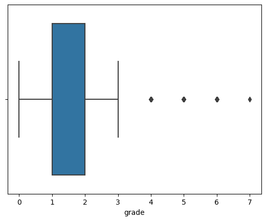

```python
#skewness and kurtosis
print("Skewness: %f" % df['grade'].skew())
print("Kurtosis: %f" % df['grade'].kurt())
sns.boxplot(x=df['grade'])
```

The data isn't balanced as there are fewer individuals with worse grades (such as E,F,G)

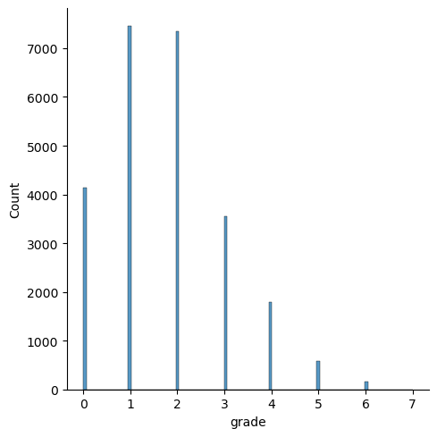

```python
sns.displot(df['grade'])
```

```python
df['grade'].describe()
```

```
count    25000.000000
mean         1.751040
std          1.278313
min          0.000000
25%          1.000000
50%          2.000000
75%          2.000000
max          7.000000
Name: grade, dtype: float64
```

### Total collection Amounts ever Owed

The data type for the variable 'tot_coll_amt' is a float64. This is a numerical variable which is great as it doesn't need to be transformed for the model.

```python
df['tot_coll_amt'].info()
```

```
<class 'pandas.core.series.Series'>
RangeIndex: 25000 entries, 0 to 24999
Series name: tot_coll_amt
Non-Null Count  Dtype
--------------  -----
23996 non-null  float64
dtypes: float64(1)
memory usage: 195.4 KB
```

There appears to be 1004 missing value which shouldn't be a problem as it can be easily removed later on. 1004 rows can be removed without impacting that data too much as there are 25000 rows

```python
df['tot_coll_amt'].isnull().sum()
```

```
1004
```

There appear to be 23321 duplicates.

```python
print(df['tot_coll_amt'].duplicated().sum())
```

```
23321
```

Just as expected most of the duplicates are 0 in the column tot_coll_amt as most individuals have a $0 total collection Amounts ever Owed

```python
(df['tot_coll_amt'] == 0).sum()
```

```
20234
```

According to the Skewness and Kurtosis values, the 'tot_coll_amt' column exhibits a right skewed. The distribution of the annual income column has a long tails as all the outliers appear on the right of the upper whisker and the Kurtosis is much greater than 3. I would like to capture how these individuals with high levels of total collection amounts will behave so I will keep the outliers.

```
Skewness: 141.877494
Kurtosis: 21291.091539
```

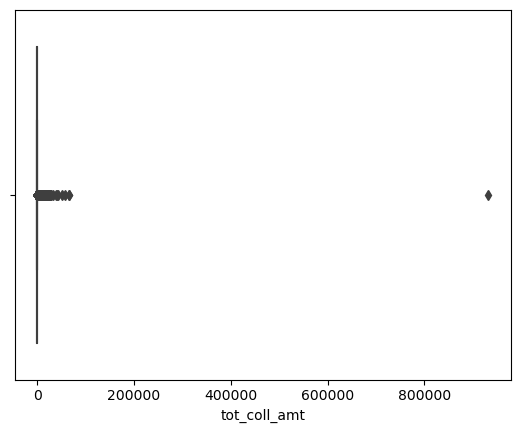

```python
#skewness and kurtosis
print("Skewness: %f" % df['tot_coll_amt'].skew())
print("Kurtosis: %f" % df['tot_coll_amt'].kurt())
sns.boxplot(x=df['tot_coll_amt'])
```

The 'tot_coll_amt' column is not balanced as most individuals have a total collections ammount of 0.

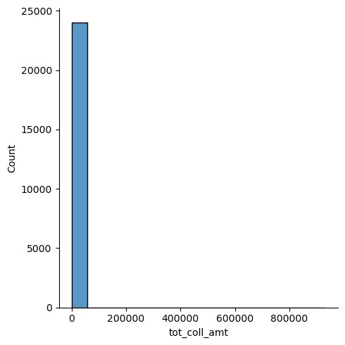

```python
sns.displot(df['tot_coll_amt'])
```

```python
df['tot_coll_amt'].describe()
```

```
count     23996.000000
mean        254.371520
std        6200.891735
min           0.000000
25%           0.000000
50%           0.000000
75%           0.000000
max      932461.000000
Name: tot_coll_amt, dtype: float64
```

### Number of mortgage accounts.

The data type for the variable 'mort_acc' is a float64. This is a numerical variable which is great as it doesn't need to be transformed for the model.

```python
df['mort_acc'].info()
```

```
<class 'pandas.core.series.Series'>
RangeIndex: 25000 entries, 0 to 24999
Series name: mort_acc
Non-Null Count  Dtype
--------------  -----
24257 non-null  float64
dtypes: float64(1)
memory usage: 195.4 KB
```

There appears to be 743 missing value which shouldn't be a problem as it can be easily removed later on. The 743 rows can be removed without impacting that data too much as there are 25000 rows.

```python
df['mort_acc'].isnull().sum()
```

```
743
```

There appears to be 24980 duplicates. It would be better to see the count of each unique value within the column 'mort_acc'

```python
print(df['mort_acc'].duplicated().sum())
```

```
24980
```

```python
ZEROS = (df['mort_acc'] == 0).sum()
ONES = (df['mort_acc'] == 1).sum()
TWOS = (df['mort_acc'] == 2).sum()
print("Number of 0's: " + str(ZEROS))
print("Number of 1's: " + str(ONES))
print("Number of 1's: " + str(TWOS))
```

```
Number of 0's: 9926
Number of 1's: 4247
Number of 1's: 3438
```

```
Skewness: 1.557346
Kurtosis: 3.661365
```

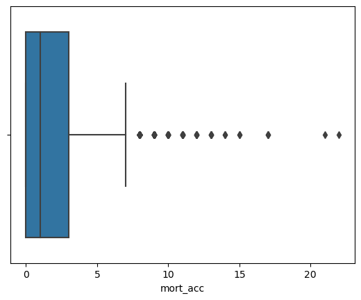

```python
#skewness and kurtosis
print("Skewness: %f" % df['mort_acc'].skew())
print("Kurtosis: %f" % df['mort_acc'].kurt())
sns.boxplot(x=df['mort_acc'])
```

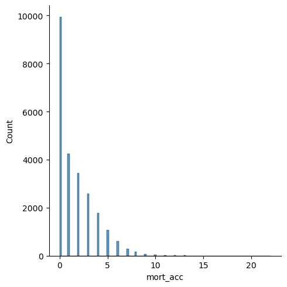

```python
sns.displot(df['mort_acc'])
```

```python
df['mort_acc'].describe()
```

```
count    24257.000000
mean         1.646865
std          1.980789
min          0.000000
25%          0.000000
50%          1.000000
75%          3.000000
max         22.000000
Name: mort_acc, dtype: float64
```

### Average Current Balance

The data type for the variable 'avg_cur_bal' is a float64. This is a numerical variable which is great as it doesn't need to be transformed for the model.

```python
df['avg_cur_bal'].info()
```

```
<class 'pandas.core.series.Series'>
RangeIndex: 25000 entries, 0 to 24999
Series name: avg_cur_bal
Non-Null Count  Dtype
--------------  -----
23996 non-null  float64
dtypes: float64(1)
memory usage: 195.4 KB
```

There appears to be 1004 missing value which shouldn't be a problem as it can be easily removed later on. 1004 rows can be removed without impacting that data too much as there are 25000 rows.

```python
print(df['avg_cur_bal'].isnull().sum())
```

```
1004
```

There appears to be 9266 rows where the 'avg_cur_bal' appears more than once. When taking a breif look at the first 5 and last 5 duplicates we can see that other columns vary. I want to capture how a different combination of variables while keeping bank balances constant will impact the probability of an individual defaulting. Due to this reason I will keep the duplicates.

```python
print(df['avg_cur_bal'].duplicated().sum())
dup = df[df['avg_cur_bal'].duplicated(keep=False)]
dup.sort_values(by=['avg_cur_bal'])
```

```
9266
```

|  | Unnamed: 0 | id | member_id | loan_amnt | term | int_rate | installment | grade | sub_grade | emp_title | emp_length | home_ownership | annual_inc | verification_status | loan_status | pymnt_plan | desc | purpose | title | zip_code | addr_state | dti | delinq_2yrs | earliest_cr_line | fico_range_low | fico_range_high | inq_last_6mths | mths_since_last_delinq | mths_since_last_record | … |
| --- | --- | --- | --- | --- | --- | --- | --- | --- | --- | --- | --- | --- | --- | --- | --- | --- | --- | --- | --- | --- | --- | --- | --- | --- | --- | --- | --- | --- | --- | --- |
| 11088 | 11088 | 709867 | 111156879 | 1000.0 | 36 months | 15.05 | 34.69 | 2 | C4 | Research Technician | 4 | RENT | 40000.0 | Not Verified | Current | n | NaN | car | Car financing | 769xx | TX | 0.00 | 0.0 | 1999-05-01 00:00:00 | 755.0 | 759.0 | 0.0 | NaN | NaN | … |
| 9277 | 9277 | 761611 | 106793665 | 1000.0 | 36 months | 19.99 | 37.16 | 3 | D4 | NaN | NaN | RENT | 9000.0 | Source Verified | Fully Paid | n | NaN | major_purchase | Major purchase | 454xx | OH | 0.00 | 0.0 | 2005-06-01 00:00:00 | 770.0 | 774.0 | 1.0 | NaN | NaN | … |
| 21174 | 21174 | 1001578 | 102584773 | 18000.0 | 36 months | 11.49 | 593.49 | 1 | B5 | NaN | NaN | OWN | 51288.0 | Verified | Current | n | NaN | major_purchase | Major purchase | 908xx | CA | 0.00 | 0.0 | 2006-05-01 00:00:00 | 675.0 | 679.0 | 0.0 | NaN | 30.0 | … |
| 20722 | 20722 | 43956 | 31557305 | 23500.0 | 60 months | 15.61 | 566.62 | 3 | D1 | Nurse | 3 | RENT | 75000.0 | Verified | Current | n | NaN | other | Other | 439xx | OH | 10.02 | 0.0 | 1990-12-01 00:00:00 | 680.0 | 684.0 | 0.0 | 37.0 | NaN | … |
| 19388 | 19388 | 1525599 | 74786254 | 10000.0 | 36 months | 7.39 | 310.56 | 0 | A4 | Production operator | 2 | RENT | 25480.0 | Source Verified | Current | n | NaN | debt_consolidation | Debt consolidation | 948xx | CA | 2.36 | 0.0 | 2003-09-01 00:00:00 | 790.0 | 794.0 | 0.0 | NaN | NaN | … |
| ... | ... | ... | ... | ... | ... | ... | ... | ... | ... | ... | ... | ... | ... | ... | ... | ... | ... | ... | ... | ... | ... | ... | ... | ... | ... | ... | ... | ... | ... | … |
| 24819 | 24819 | 275331 | 131223 | 20000.0 | 36 months | 15.65 | 699.69 | 5 | F3 | Chevy Chase Bank | 6 | RENT | 92000.0 | Not Verified | Fully Paid | n | Finance the working capital needs of Cabe Microfinance Capital Management LLC, a new business in which I am involved. | small_business | Working Capital | 208xx | MD | 1.53 | 0.0 | 1997-11-01 00:00:00 | 665.0 | 669.0 | 1.0 | 34.0 | 0.0 | … |
| 24822 | 24822 | 237227 | 1048659 | 15850.0 | 60 months | 17.27 | 396.22 | 3 | D3 | MNMC | 0 | RENT | 28000.0 | Not Verified | Charged Off | n | Borrower added on 11/22/11 > i am working full time.. i want to pay off my credit card ..<br>Borrower added on 11/22/11 > i am working full time.. i want to pay off my credit card ..<br> Borrowe... | credit_card | credit card | 168xx | PA | 15.90 | 0.0 | 2004-11-01 00:00:00 | 695.0 | 699.0 | 1.0 | 46.0 | NaN | … |
| 24896 | 24896 | 240872 | 988586 | 12500.0 | 36 months | 6.03 | 380.45 | 0 | A1 | Sanford Burnham Medical Research Inst. | 3 | MORTGAGE | 53000.0 | Not Verified | Fully Paid | n | Borrower added on 10/13/11 > I plan to use the fund to pay off medical bills and other debt. I have excellent credit and have NEVER been late on a payment for any bill. I have been at my current... | medical | 2011-10-01 00:00:00 | 328xx | FL | 12.09 | 0.0 | 2000-11-01 00:00:00 | 755.0 | 759.0 | 0.0 | NaN | NaN | … |
| 24922 | 24922 | 260038 | 601784 | 10000.0 | 36 months | 6.91 | 308.36 | 0 | A5 | vallarta supermarkets | 8 | RENT | 28000.0 | Source Verified | Fully Paid | n | Borrower added on 10/21/10 > need to finish paying bill<br/> Borrower added on 10/21/10 > need to buy everything that is needed for my 4 month baby<br/> Borrower added on 10/24/10 > paying off c... | debt_consolidation | pay dept | 916xx | CA | 0.43 | 0.0 | 2002-11-01 00:00:00 | 750.0 | 754.0 | 4.0 | 38.0 | NaN | … |
| 24946 | 24946 | 239832 | 1007042 | 12000.0 | 36 months | 9.91 | 386.70 | 1 | B1 | NaN | 3 | RENT | 140000.0 | Verified | Fully Paid | n | NaN | debt_consolidation | 2012 Loan | 774xx | TX | 10.16 | 0.0 | 1995-03-01 00:00:00 | 720.0 | 724.0 | 0.0 | 31.0 | NaN | … |

14224 rows × 135 columns

```
Skewness: 3.301712
Kurtosis: 21.096669
```

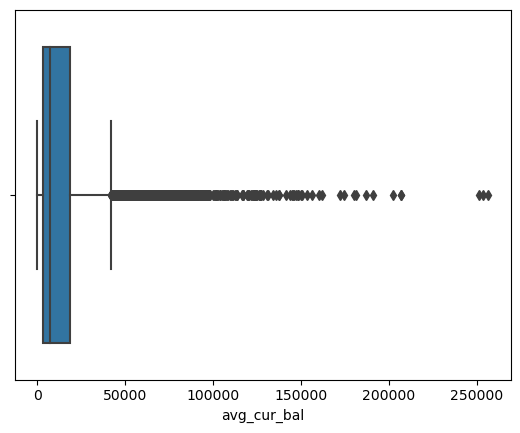

```python
#skewness and kurtosis
print("Skewness: %f" % df['avg_cur_bal'].skew())
print("Kurtosis: %f" % df['avg_cur_bal'].kurt())
sns.boxplot(x=df['avg_cur_bal'])
```

The average currently balance appears to be decreasing within each level. This is not balanced.

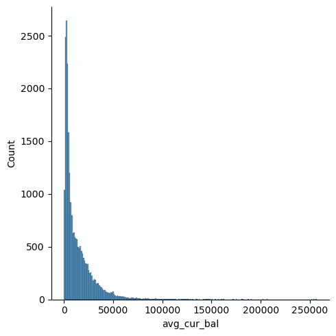

```python
sns.displot(df['avg_cur_bal'])
```

```python
df['avg_cur_bal'].describe()
```

```
count     23996.000000
mean      13513.349392
std       16162.473350
min           0.000000
25%        3162.000000
50%        7404.000000
75%       18744.000000
max      256669.000000
Name: avg_cur_bal, dtype: float64
```

### Loan Status (Predicting Variable)

The data type for the variable 'loan_status' is a object. This is our response variable which is what I hope to better predict. The column has words such as "Fully Paid", "Charged Off", "Default", etc. This column will need to be altered in order to be used for the model.

```python
df['loan_status'].info()
```

```
<class 'pandas.core.series.Series'>
RangeIndex: 25000 entries, 0 to 24999
Series name: loan_status
Non-Null Count  Dtype
--------------  -----
24999 non-null  object
dtypes: object(1)
memory usage: 195.4+ KB
```

There appears to be 1 missing value in Row #23975 which shouldn't be a problem as it can be easily removed later on.

```python
df['loan_status'].isnull().sum()
df[df['loan_amnt'].isna()]
```

|  | Unnamed: 0 | id | member_id | loan_amnt | term | int_rate | installment | grade | sub_grade | emp_title | emp_length | home_ownership | annual_inc | verification_status | loan_status | pymnt_plan | desc | purpose | title | zip_code | addr_state | dti | delinq_2yrs | earliest_cr_line | fico_range_low | fico_range_high | inq_last_6mths | mths_since_last_delinq | mths_since_last_record | … |
| --- | --- | --- | --- | --- | --- | --- | --- | --- | --- | --- | --- | --- | --- | --- | --- | --- | --- | --- | --- | --- | --- | --- | --- | --- | --- | --- | --- | --- | --- | --- |
| 23975 | 23975 | 804718 | Total amount funded in policy code 2: 608903141 | NaN | NaN | NaN | NaN | 7 | NaN | NaN | NaN | NaN | NaN | NaN | NaN | NaN | NaN | NaN | NaN | NaN | NaN | NaN | NaN | NaN | NaN | NaN | NaN | NaN | NaN | … |

```python
print(df['loan_status'].duplicated().sum())
```

```
24990
```

```python
print(df['loan_status'].unique())
```

```
['Charged Off' 'Current' 'Fully Paid' 'Late (31-120 days)'
 'In Grace Period' 'Late (16-30 days)'
 'Does not meet the credit policy. Status:Fully Paid'
 'Does not meet the credit policy. Status:Charged Off' 'Default' nan]
```

The data isn't balanced when looking at the values of interst which are "Fully Paid" and "Charged Off". There is a significant differnece.

```
([0, 1, 2, 3, 4, 5, 6, 7, 8],
 [Text(0, 0, 'Charged Off'),
```

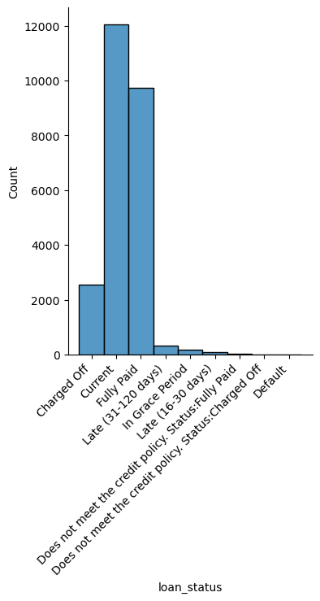

```python
sns.displot(df['loan_status'])
plt.xticks(rotation=45, ha="right")
```

```python
df['loan_status'].describe()
```

```
count       24999
unique          9
top       Current
freq        12063
Name: loan_status, dtype: object
```

## Bivariate Analysis

```python
TenFeautreDF = df[["loan_amnt", "int_rate", "installment", "annual_inc", "emp_length",
                   "dti", "grade", "tot_coll_amt", "mort_acc", "avg_cur_bal", "loan_status"]]
TenFeautreDF
```

|  | loan_amnt | int_rate | installment | annual_inc | emp_length | dti | grade | tot_coll_amt | mort_acc | avg_cur_bal | loan_status |
| --- | --- | --- | --- | --- | --- | --- | --- | --- | --- | --- | --- |
| 0 | 20000.0 | 17.93 | 342.94 | 44304.0 | 1 | 18.47 | 4 | NaN | NaN | NaN | Charged Off |
| 1 | 30000.0 | 11.99 | 996.29 | 136000.0 | 10 | 20.63 | 2 | 0.0 | 3.0 | 6327.0 | Current |
| 2 | 21500.0 | 11.99 | 714.01 | 50000.0 | 1 | 29.62 | 1 | 0.0 | 2.0 | 6245.0 | Fully Paid |
| 3 | 10000.0 | 13.67 | 340.18 | 64400.0 | NaN | 16.68 | 2 | 0.0 | 1.0 | 2103.0 | Fully Paid |
| 4 | 5000.0 | 8.49 | 157.82 | 88000.0 | 10 | 5.32 | 1 | 537.0 | 1.0 | 25684.0 | Current |
| ... | ... | ... | ... | ... | ... | ... | ... | ... | ... | ... | ... |
| 24995 | 10500.0 | 10.16 | 339.60 | 78000.0 | 5 | 9.58 | 1 | 0.0 | 4.0 | 24314.0 | Fully Paid |
| 24996 | 12000.0 | 14.33 | 412.06 | 82000.0 | 10 | 11.75 | 2 | 0.0 | 0.0 | 5375.0 | Fully Paid |
| 24997 | 25000.0 | 12.69 | 838.63 | 60000.0 | 0 | 13.34 | 2 | 2957.0 | 4.0 | 13721.0 | Late (31-120 days) |
| 24998 | 12200.0 | 13.49 | 280.66 | 44400.0 | NaN | 10.59 | 2 | 0.0 | 0.0 | 2723.0 | Current |
| 24999 | 5000.0 | 19.03 | 183.36 | 50000.0 | 6 | 27.43 | 3 | 5378.0 | 0.0 | 3321.0 | Current |

25000 rows × 11 columns

Below I converted emp_length into a numerical variable as it consisted of symbols, text, and numbers

```python
# I noticed there was the symbol '<' in the value '< 1 year' so I wanted to replace those values with just '0 years'
TenFeautreDF=TenFeautreDF.replace('< 1 year','0 years')
#I took out the symbols and letters, which left me with just the numerical value in each row for the column 'emp_length'
emp_length_numeric = TenFeautreDF.emp_length.str.extract('(^\d*)')
TenFeautreDF['emp_length'] = emp_length_numeric
#The column was still an object even though the rows were numeric so I converted to float using the code below
TenFeautreDF['emp_length'] = TenFeautreDF['emp_length'].astype(float)
```

```python
Correlation_Matrix = TenFeautreDF.corr()
Correlation_Matrix
```

|  | loan_amnt | int_rate | installment | annual_inc | emp_length | dti | grade | tot_coll_amt | mort_acc | avg_cur_bal |
| --- | --- | --- | --- | --- | --- | --- | --- | --- | --- | --- |
| loan_amnt | 1.000000 | 0.129413 | 0.945894 | 0.423785 | 0.091689 | 0.040471 | 0.131678 | -0.006766 | 0.254058 | 0.241276 |
| int_rate | 0.129413 | 1.000000 | 0.147435 | -0.108864 | -0.005478 | 0.121207 | 0.952694 | -0.001758 | -0.097308 | -0.095077 |
| installment | 0.945894 | 0.147435 | 1.000000 | 0.409800 | 0.075661 | 0.042113 | 0.137551 | -0.004427 | 0.215988 | 0.214342 |
| annual_inc | 0.423785 | -0.108864 | 0.409800 | 1.000000 | 0.086499 | -0.150847 | -0.103111 | 0.006960 | 0.288236 | 0.408591 |
| emp_length | 0.091689 | -0.005478 | 0.075661 | 0.086499 | 1.000000 | 0.015386 | -0.002978 | 0.005362 | 0.192025 | 0.084818 |
| dti | 0.040471 | 0.121207 | 0.042113 | -0.150847 | 0.015386 | 1.000000 | 0.119616 | -0.007325 | -0.026150 | -0.071073 |
| grade | 0.131678 | 0.952694 | 0.137551 | -0.103111 | -0.002978 | 0.119616 | 1.000000 | -0.003127 | -0.091167 | -0.095122 |
| tot_coll_amt | -0.006766 | -0.001758 | -0.004427 | 0.006960 | 0.005362 | -0.007325 | -0.003127 | 1.000000 | 0.003140 | -0.006686 |
| mort_acc | 0.254058 | -0.097308 | 0.215988 | 0.288236 | 0.192025 | -0.026150 | -0.091167 | 0.003140 | 1.000000 | 0.472000 |
| avg_cur_bal | 0.241276 | -0.095077 | 0.214342 | 0.408591 | 0.084818 | -0.071073 | -0.095122 | -0.006686 | 0.472000 | 1.000000 |

There appears to be some corrlation between my selected features.

Highly Corrlated Features:

**Installment and Loan Amount**

- Monthly payments are likely to be higher when the amount of money being borrowed is bigger

**Interset Rate and Grade**

- Interest rates are usually determined by Credit Grade, those who have a credit grade of A are able to borrow at the prime rate which is the cheapest rate.

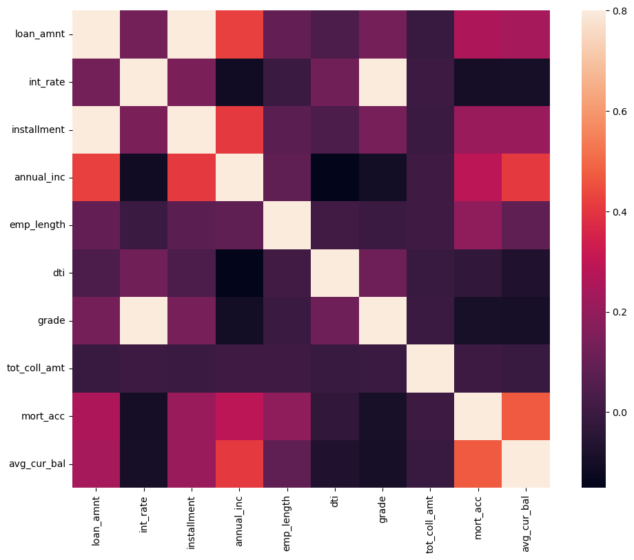

```python
#correlation matrix
corrmat = TenFeautreDF.corr()
f, ax = plt.subplots(figsize=(12, 9))
sns.heatmap(corrmat, vmax=.8, square=True);
```

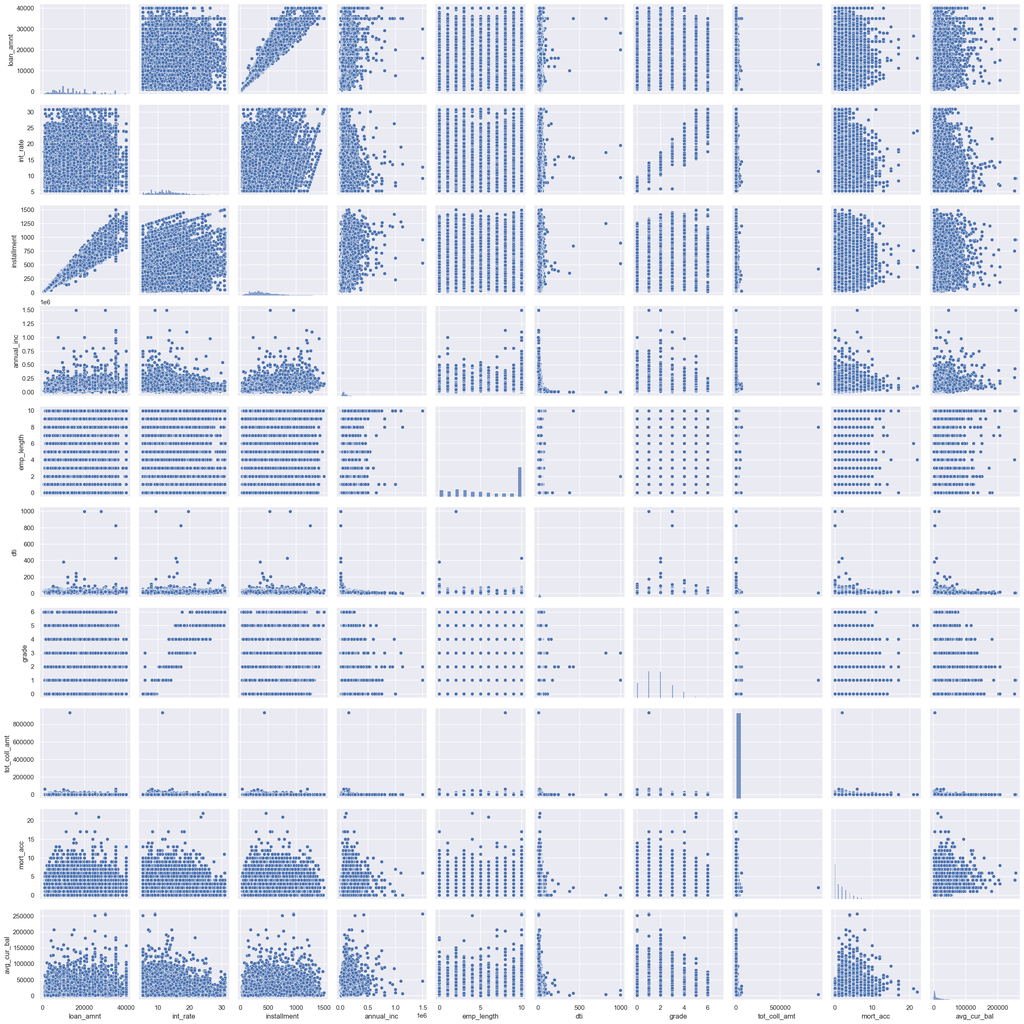

```python
sns.set()
sns.pairplot(TenFeautreDF)
plt.show();
```

## Interseting Observations

I initially thought that I would be seeing an increase in average current balance as the employment length increase, but this pattern isn't too visble as individuals catergorized in emp_length = 2 have a similar spread in average current balance as the individuals within emp_length = 5,6, and 9 and I found this too be quite interesting.

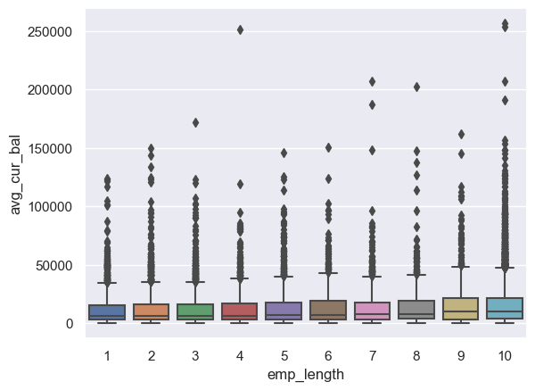

```python
sns.boxplot(x=df['emp_length'], y=df['avg_cur_bal'], order=['1','2','3','4','5','6','7','8','9','10'])
```

I find it interesting that there is an upwards pattern in loan amount as credit scores gets worse. This is because, I felt that credit scores affect the amount of money one can borrow. For instance, an individual with a high credit (G) grade would only be able to borrow less than an individual with lower credit grade (A). However, this doesn't appear to be the case as the median loan amount increases as the grades get worse.

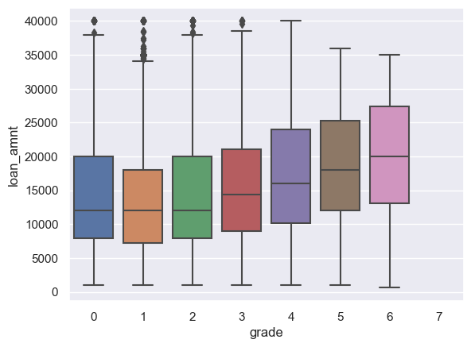

```python
sns.boxplot(x=df['grade'], y=df['loan_amnt'])
```

The boxplot shows outlier(s) in the "Charged Off" groups as the most interesting outliers are those with an A grade, as those indiviudals are less likely to default. Also, I find it interesting that most of the individuals in the "Charged Off" group are in Grade C-D as I would expected the average to be higher. However, this could be an issue with the sampling as there were likely to be less people surveyed that belonged in the group of Grade D-G

```
(array([0, 1, 2, 3, 4, 5, 6, 7, 8]),
 [Text(0, 0, 'Charged Off'),
```

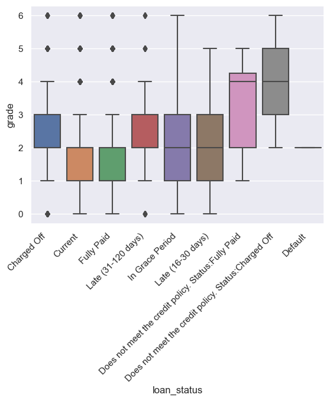

```python
sns.boxplot(x=df['loan_status'], y=df['grade'], )
plt.xticks(rotation=45, ha="right")
```

I never knew how important credit score was when determing interest rate as it appears that Grade is the sole factor in determing the interest rate you'll be paying on a loan

```
(array([0, 1, 2, 3, 4, 5, 6, 7]),
 [Text(0, 0, '0'),
```

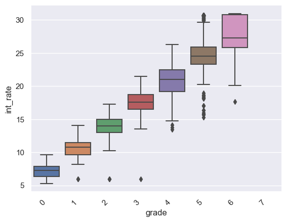

```python
sns.boxplot(x=df['grade'], y=df['int_rate'], )
plt.xticks(rotation=45, ha="right")
```

I would assume individuals with more mortgage accounts would have a higher annual income, however the average annual income appears to be relatively constant amongst most groups. Also most of the outlier (individuals earning higher incomes) appear to have fewer mortgage accounts as well.

```
(array([ 0,  1,  2,  3,  4,  5,  6,  7,  8,  9, 10, 11, 12, 13, 14, 15, 16,
        17, 18]),
 [Text(0, 0, '0.0'),
```

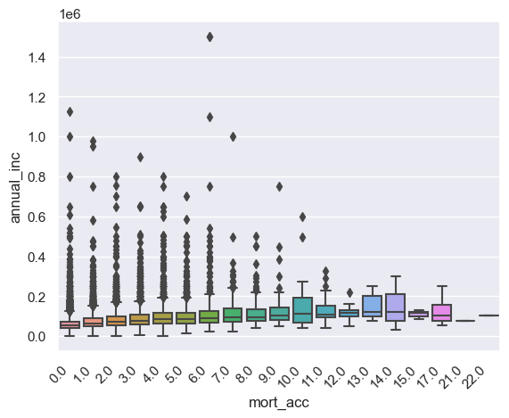

```python
sns.boxplot(x=df['mort_acc'], y=df['annual_inc'])
plt.xticks(rotation=45, ha="right")
```

# Part 2: Data Preparation

```python
TenFeautreDF['loan_status'].value_counts()
```

```
Current                                                12063
Fully Paid                                              9733
Charged Off                                             2557
Late (31-120 days)                                       336
In Grace Period                                          174
Late (16-30 days)                                        101
Does not meet the credit policy. Status:Fully Paid        28
Does not meet the credit policy. Status:Charged Off        5
Default                                                    2
Name: loan_status, dtype: int64
```

I noticed that there were 2 values with 'Default' which is quite similar to 'Charged Off'

```python
#Displaying columns with "Default"
TenFeautreDF.loc[TenFeautreDF['loan_status'] == "Default"]
```

|  | loan_amnt | int_rate | installment | annual_inc | emp_length | dti | grade | tot_coll_amt | mort_acc | avg_cur_bal | loan_status |
| --- | --- | --- | --- | --- | --- | --- | --- | --- | --- | --- | --- |
| 20294 | 5000.0 | 12.69 | 167.73 | 15000.0 | 1.0 | 28.48 | 2 | 0.0 | 0.0 | 31969.0 | Default |
| 24524 | 6600.0 | 14.65 | 227.67 | 14400.0 | 0.0 | 36.67 | 2 | 0.0 | 0.0 | 1388.0 | Default |

```python
#Displaying columns with "Does not meet the credit policy. Status:Fully Paid"
TenFeautreDF.loc[TenFeautreDF['loan_status'] == "Does not meet the credit policy. Status:Fully Paid"].head()
```

|  | loan_amnt | int_rate | installment | annual_inc | emp_length | dti | grade | tot_coll_amt | mort_acc | avg_cur_bal | loan_status |
| --- | --- | --- | --- | --- | --- | --- | --- | --- | --- | --- | --- |
| 243 | 5000.0 | 12.61 | 167.54 | 46100.0 | 2.0 | 2.68 | 2 | NaN | NaN | NaN | Does not meet the credit policy. Status:Fully Paid |
| 351 | 13900.0 | 13.92 | 474.51 | 71400.0 | 0.0 | 24.05 | 2 | NaN | NaN | NaN | Does not meet the credit policy. Status:Fully Paid |
| 1772 | 1750.0 | 14.12 | 59.92 | 105000.0 | 1.0 | 17.70 | 3 | NaN | NaN | NaN | Does not meet the credit policy. Status:Fully Paid |
| 2488 | 1825.0 | 15.76 | 63.95 | 20004.0 | 0.0 | 25.07 | 5 | NaN | NaN | NaN | Does not meet the credit policy. Status:Fully Paid |
| 6449 | 20000.0 | 13.85 | 682.08 | 61200.0 | 1.0 | 20.10 | 2 | NaN | NaN | NaN | Does not meet the credit policy. Status:Fully Paid |

I noticed that there were 5 values with 'Does not meet the credit policy. Status:Charged Off' which is quite similar to 'Charged Off'

```python
#Displaying columns with "Does not meet the credit policy. Status:Charged Off"
TenFeautreDF.loc[TenFeautreDF['loan_status'] == "Does not meet the credit policy. Status:Charged Off"].head()
```

|  | loan_amnt | int_rate | installment | annual_inc | emp_length | dti | grade | tot_coll_amt | mort_acc | avg_cur_bal | loan_status |
| --- | --- | --- | --- | --- | --- | --- | --- | --- | --- | --- | --- |
| 15921 | 8100.0 | 16.63 | 287.31 | 54996.0 | 10.0 | 22.71 | 4 | NaN | NaN | NaN | Does not meet the credit policy. Status:Charged Off |
| 17290 | 600.0 | 17.66 | 21.59 | 23826.0 | 1.0 | 26.89 | 6 | NaN | NaN | NaN | Does not meet the credit policy. Status:Charged Off |
| 17550 | 6000.0 | 13.61 | 203.94 | 36000.0 | 8.0 | 15.10 | 2 | NaN | NaN | NaN | Does not meet the credit policy. Status:Charged Off |
| 18243 | 5250.0 | 16.40 | 185.62 | 43000.0 | 6.0 | 22.75 | 5 | NaN | NaN | NaN | Does not meet the credit policy. Status:Charged Off |
| 19960 | 6000.0 | 14.09 | 205.33 | 30000.0 | 2.0 | 13.48 | 3 | NaN | NaN | NaN | Does not meet the credit policy. Status:Charged Off |

Below I replaced the values of 'Default' and 'Does not meet the credit policy. Status:Charged Off' to 'Charged Off' and replaced the values 'Does not meet the credit policy. Status:Fully Paid",'Fully Paid' to 'Fully Paid' because I hope to capture these indiviudals as well within the model.

```python
#Replacing 'Default' with 'Charged Off'
TenFeautreDF=TenFeautreDF.replace('Default','Charged Off')
#Replacing "Does not meet the credit policy. Status:Fully Paid" with 'Fully Paid'
TenFeautreDF=TenFeautreDF.replace("Does not meet the credit policy. Status:Fully Paid",'Fully Paid')
# Replacing 'Does not meet the credit policy. Status:Charged Off' with 'Charged Off'
TenFeautreDF=TenFeautreDF.replace('Does not meet the credit policy. Status:Charged Off','Charged Off')
```

```python
#To check if the code above worked and replaced was used correctly
#If 3 zeros print the code has successfully replaced my desired values in the 'loan_status' column
print((TenFeautreDF['loan_status'] == 'Default').sum())
print((TenFeautreDF['loan_status'] == 'Does not meet the credit policy. Status:Fully Paid').sum())
print((TenFeautreDF['loan_status'] == 'Does not meet the credit policy. Status:Charged Off').sum())
```

```
0
0
0
```

I only hope to predict the likeliness of a loan being 'Charged Off' or 'Fully Paid' so I will filter the data set such that the column 'loan_status' only has those 2 values

```python
# Since I hope to predict the liekliness of one fully paying back the loan or defaulting, I will filter the data set
# so that column 'loan_status' only has the values of 'Charged Off' and 'Fully Paid'
TenFeautreDF = TenFeautreDF.loc[TenFeautreDF['loan_status'].isin(['Fully Paid','Charged Off'])]
TenFeautreDF
```

|  | loan_amnt | int_rate | installment | annual_inc | emp_length | dti | grade | tot_coll_amt | mort_acc | avg_cur_bal | loan_status |
| --- | --- | --- | --- | --- | --- | --- | --- | --- | --- | --- | --- |
| 0 | 20000.0 | 17.93 | 342.94 | 44304.0 | 1.0 | 18.47 | 4 | NaN | NaN | NaN | Charged Off |
| 2 | 21500.0 | 11.99 | 714.01 | 50000.0 | 1.0 | 29.62 | 1 | 0.0 | 2.0 | 6245.0 | Fully Paid |
| 3 | 10000.0 | 13.67 | 340.18 | 64400.0 | NaN | 16.68 | 2 | 0.0 | 1.0 | 2103.0 | Fully Paid |
| 5 | 16150.0 | 30.74 | 529.88 | 38500.0 | 10.0 | 33.73 | 5 | 0.0 | 0.0 | 6694.0 | Charged Off |
| 8 | 35000.0 | 12.79 | 1175.76 | 118000.0 | 9.0 | 26.66 | 2 | 0.0 | 6.0 | 19247.0 | Fully Paid |
| ... | ... | ... | ... | ... | ... | ... | ... | ... | ... | ... | ... |
| 24988 | 4000.0 | 15.80 | 140.24 | 14988.0 | NaN | 23.38 | 2 | 0.0 | 0.0 | 668.0 | Fully Paid |
| 24991 | 3000.0 | 11.44 | 98.85 | 140500.0 | 10.0 | 10.10 | 1 | 0.0 | 2.0 | 49954.0 | Fully Paid |
| 24994 | 13925.0 | 11.67 | 460.32 | 31000.0 | 0.0 | 21.84 | 1 | 0.0 | 0.0 | 5059.0 | Fully Paid |
| 24995 | 10500.0 | 10.16 | 339.60 | 78000.0 | 5.0 | 9.58 | 1 | 0.0 | 4.0 | 24314.0 | Fully Paid |
| 24996 | 12000.0 | 14.33 | 412.06 | 82000.0 | 10.0 | 11.75 | 2 | 0.0 | 0.0 | 5375.0 | Fully Paid |

12325 rows × 11 columns

I have converted the 'loan_status' column into a numerical value which is required to be used for the Decision Tree Model

```python
#1 is Fully Paid, 0 is Charged Off
TenFeautreDF['loan_status'] = le.fit_transform(TenFeautreDF['loan_status'])
```

## Handling Missing Data

I have decided to remove any rows with a null value. It appears that there are null values in the following columns

- emp_length
- dti
- tot_coll_amt
- mort_acc
- avg_cur_bal

```python
TenFeautreDF.isnull().sum()
```

```
loan_amnt          0
int_rate           0
installment        0
annual_inc         0
emp_length       679
dti                1
grade              0
tot_coll_amt    1003
mort_acc         742
avg_cur_bal     1003
loan_status        0
dtype: int64
```

```python
#Removing the rows will null values
TenFeautreDF = TenFeautreDF[TenFeautreDF['emp_length'].notna()]
TenFeautreDF = TenFeautreDF[TenFeautreDF['dti'].notna()]
TenFeautreDF = TenFeautreDF[TenFeautreDF['tot_coll_amt'].notna()]
TenFeautreDF = TenFeautreDF[TenFeautreDF['mort_acc'].notna()]
TenFeautreDF = TenFeautreDF[TenFeautreDF['avg_cur_bal'].notna()]
```

```python
TenFeautreDF.isnull().sum()
```

```
loan_amnt       0
int_rate        0
installment     0
annual_inc      0
emp_length      0
dti             0
grade           0
tot_coll_amt    0
mort_acc        0
avg_cur_bal     0
loan_status     0
dtype: int64
```

## Checking Duplicates

I have decided to keep all my duplicates because it is important to see how the likeliess of default would change when holding one variable constant while the other variable/ feature change

```python
for i in TenFeautreDF:
    x = TenFeautreDF[i].duplicated().sum()
    print (i +"| Number of Duplicates: " + str(x))
```

```
loan_amnt| Number of Duplicates: 9764
int_rate| Number of Duplicates: 10405
installment| Number of Duplicates: 4252
annual_inc| Number of Duplicates: 9221
emp_length| Number of Duplicates: 10668
dti| Number of Duplicates: 7415
grade| Number of Duplicates: 10672
tot_coll_amt| Number of Duplicates: 9746
mort_acc| Number of Duplicates: 10661
avg_cur_bal| Number of Duplicates: 2044
loan_status| Number of Duplicates: 10677
```

# Part 3: Splitting data into training data and test data

```python
x, y = TenFeautreDF.iloc[:, 0:10], TenFeautreDF.iloc[:,10]
```

```python
x
```

|  | loan_amnt | int_rate | installment | annual_inc | emp_length | dti | grade | tot_coll_amt | mort_acc | avg_cur_bal |
| --- | --- | --- | --- | --- | --- | --- | --- | --- | --- | --- |
| 2 | 21500.0 | 11.99 | 714.01 | 50000.0 | 1.0 | 29.62 | 1 | 0.0 | 2.0 | 6245.0 |
| 5 | 16150.0 | 30.74 | 529.88 | 38500.0 | 10.0 | 33.73 | 5 | 0.0 | 0.0 | 6694.0 |
| 8 | 35000.0 | 12.79 | 1175.76 | 118000.0 | 9.0 | 26.66 | 2 | 0.0 | 6.0 | 19247.0 |
| 11 | 10000.0 | 11.99 | 332.10 | 76000.0 | 3.0 | 17.31 | 1 | 0.0 | 3.0 | 3419.0 |
| 12 | 10000.0 | 11.67 | 330.57 | 75000.0 | 3.0 | 22.34 | 1 | 0.0 | 0.0 | 7328.0 |
| ... | ... | ... | ... | ... | ... | ... | ... | ... | ... | ... |
| 24985 | 7500.0 | 29.49 | 316.30 | 56000.0 | 10.0 | 28.83 | 5 | 0.0 | 0.0 | 1948.0 |
| 24991 | 3000.0 | 11.44 | 98.85 | 140500.0 | 10.0 | 10.10 | 1 | 0.0 | 2.0 | 49954.0 |
| 24994 | 13925.0 | 11.67 | 460.32 | 31000.0 | 0.0 | 21.84 | 1 | 0.0 | 0.0 | 5059.0 |
| 24995 | 10500.0 | 10.16 | 339.60 | 78000.0 | 5.0 | 9.58 | 1 | 0.0 | 4.0 | 24314.0 |
| 24996 | 12000.0 | 14.33 | 412.06 | 82000.0 | 10.0 | 11.75 | 2 | 0.0 | 0.0 | 5375.0 |

10679 rows × 10 columns

```python
y
```

```
2        1
5        0
8        1
11       1
12       1
        ..
24985    0
24991    1
24994    1
24995    1
24996    1
Name: loan_status, Length: 10679, dtype: int32
```

```python
x.shape
```

```
(10679, 10)
```

```python
y.shape
```

```
(10679,)
```

```python
from sklearn.model_selection import train_test_split
x_train, x_test, y_train, y_test = train_test_split(x, y, test_size=0.3, random_state=42, stratify=y, shuffle=True)
```

```python
y_test.value_counts()
```

```
1    2542
0     662
Name: loan_status, dtype: int64
```

```python
y_train.value_counts()
```

```
1    5931
0    1544
Name: loan_status, dtype: int64
```

# Part 4: Evaluation

## Model Performance

```python
# import ML libraries
from sklearn.tree import DecisionTreeClassifier

# Create Decision Tree classifer object
clf = DecisionTreeClassifier(criterion='entropy',random_state=42)

# Train Decision Tree Classifer
clf = clf.fit(x_train, y_train)

#Predict the response for test dataset
y_pred = clf.predict(x_test)
```

```python
y_pred = clf.predict(x_test)
```

Examing the confusion matrix it seems that my model appears to be having trouble categorizing the individuals as there are quite a few false negatives and positives.

A sensitivity and specificity analysis will provide better insight

```python
from sklearn.metrics import confusion_matrix

cm = confusion_matrix(y_test, y_pred)

tp = float(cm[1][1])
tn = float(cm[0][0])
fp = float(cm[0][1])
fn = float(cm[1][0])

print(cm)
```

```
[[ 199  463]
 [ 508 2034]]
```

```python
# Sensitivity: the ability of a test to correctly identify loans that will default.
sensitivity = tp/(tp+fn)

# Specificity: the ability of a test to correctly identify loans that will complete(Without default).
specificity = tn/(tn+fp)

print(sensitivity)
print(specificity)
```

```
0.8001573564122738
0.30060422960725075
```

The overall accruacy of the model is 0.6969413233458177 which is pretty awful. Hopefully we can increase the accruacy by incorporating new varaibles and removing variables that are considered userless.

```python
from sklearn.metrics import accuracy_score

accuracy_score(y_test, y_pred)
```

```
0.6969413233458177
```

```python
pd.Series(clf.feature_importances_,x_train.columns)
```

```
loan_amnt       0.078100
int_rate        0.102690
installment     0.138427
annual_inc      0.145337
emp_length      0.064308
dti             0.172222
grade           0.075448
tot_coll_amt    0.028326
mort_acc        0.041980
avg_cur_bal     0.153162
dtype: float64
```

# Part 5: Improving the Model

```python
# I removed the last few columns from the data frame as they had many null values and won't be as much help
DF1 = df.iloc[:,3:101]
DF1
```

|  | loan_amnt | term | int_rate | installment | grade | sub_grade | emp_title | emp_length | home_ownership | annual_inc | verification_status | loan_status | pymnt_plan | desc | purpose | title | zip_code | addr_state | dti | delinq_2yrs | earliest_cr_line | fico_range_low | fico_range_high | inq_last_6mths | mths_since_last_delinq | mths_since_last_record | open_acc | pub_rec | revol_bal | … |
| --- | --- | --- | --- | --- | --- | --- | --- | --- | --- | --- | --- | --- | --- | --- | --- | --- | --- | --- | --- | --- | --- | --- | --- | --- | --- | --- | --- | --- | --- | --- |
| 0 | 20000.0 | 60 months | 17.93 | 342.94 | 4 | E5 | Wylie ISD | 1 | MORTGAGE | 44304.0 | Verified | Charged Off | n | NaN | debt_consolidation | Todd's Loan | 750xx | TX | 18.47 | 0.0 | 1995-11-01 00:00:00 | 690.0 | 694.0 | 0.0 | 33.0 | NaN | 6.0 | 0.0 | 5673.0 | … |
| 1 | 30000.0 | 36 months | 11.99 | 996.29 | 2 | C1 | Sergeant | 10 | MORTGAGE | 136000.0 | Verified | Current | n | NaN | debt_consolidation | Debt consolidation | 080xx | NJ | 20.63 | 3.0 | 2003-10-01 00:00:00 | 670.0 | 674.0 | 1.0 | 7.0 | 73.0 | 12.0 | 1.0 | 13383.0 | … |
| 2 | 21500.0 | 36 months | 11.99 | 714.01 | 1 | B3 | Designer | 1 | RENT | 50000.0 | Source Verified | Fully Paid | n | Borrower added on 11/24/13 > We are consolidating our debt so we can get it paid off to purchase a home<br> | debt_consolidation | Debt Be Gone | 760xx | TX | 29.62 | 0.0 | 1999-10-01 00:00:00 | 735.0 | 739.0 | 1.0 | NaN | NaN | 13.0 | 0.0 | 14071.0 | … |
| 3 | 10000.0 | 36 months | 13.67 | 340.18 | 2 | C3 | NaN | NaN | RENT | 64400.0 | Source Verified | Fully Paid | n | NaN | debt_consolidation | Debt consolidation | 029xx | RI | 16.68 | 3.0 | 1983-11-01 00:00:00 | 675.0 | 679.0 | 0.0 | 8.0 | NaN | 9.0 | 0.0 | 8057.0 | … |
| 4 | 5000.0 | 36 months | 8.49 | 157.82 | 1 | B1 | Sr. Manufacturing Engineer | 10 | MORTGAGE | 88000.0 | Source Verified | Current | n | NaN | debt_consolidation | Debt consolidation | 301xx | GA | 5.32 | 0.0 | 2000-04-01 00:00:00 | 660.0 | 664.0 | 0.0 | 27.0 | NaN | 4.0 | 0.0 | 3055.0 | … |
| ... | ... | ... | ... | ... | ... | ... | ... | ... | ... | ... | ... | ... | ... | ... | ... | ... | ... | ... | ... | ... | ... | ... | ... | ... | ... | ... | ... | ... | ... | … |
| 24995 | 10500.0 | 36 months | 10.16 | 339.60 | 1 | B1 | Schneider Electric | 5 | MORTGAGE | 78000.0 | Not Verified | Fully Paid | n | Borrower added on 05/07/13 > My loan is for a home renovation project. I am replacing my front steps, which are falling apart. In addition I am having a front porch built and a 20' section of ... | home_improvement | Front Porch & Wall Removal/Support | 021xx | MA | 9.58 | 0.0 | 1998-04-01 00:00:00 | 685.0 | 689.0 | 1.0 | NaN | NaN | 11.0 | 0.0 | 10180.0 | … |
| 24996 | 12000.0 | 36 months | 14.33 | 412.06 | 2 | C1 | Clark County School District | 10 | RENT | 82000.0 | Not Verified | Fully Paid | n | Borrower added on 11/24/12 > I am looking to be debt free in three years. Consolidating my debt into one payment is something I am really looking forward to.<br> | debt_consolidation | Consolidation Loan | 891xx | NV | 11.75 | 0.0 | 1995-07-01 00:00:00 | 690.0 | 694.0 | 1.0 | NaN | NaN | 13.0 | 0.0 | 7711.0 | … |
| 24997 | 25000.0 | 36 months | 12.69 | 838.63 | 2 | C2 | sales consultant | 0 | MORTGAGE | 60000.0 | Source Verified | Late (31-120 days) | n | NaN | debt_consolidation | Debt consolidation | 325xx | FL | 13.34 | 1.0 | 1996-12-01 00:00:00 | 665.0 | 669.0 | 1.0 | 14.0 | NaN | 12.0 | 0.0 | 22014.0 | … |
| 24998 | 12200.0 | 60 months | 13.49 | 280.66 | 2 | C2 | NaN | NaN | OWN | 44400.0 | Not Verified | Current | n | NaN | debt_consolidation | Debt consolidation | 010xx | MA | 10.59 | 0.0 | 2002-05-01 00:00:00 | 695.0 | 699.0 | 0.0 | NaN | NaN | 5.0 | 0.0 | 12805.0 | … |
| 24999 | 5000.0 | 36 months | 19.03 | 183.36 | 3 | D3 | Web Developer | 6 | RENT | 50000.0 | Source Verified | Current | n | NaN | small_business | Business | 906xx | CA | 27.43 | 0.0 | 2007-01-01 00:00:00 | 660.0 | 664.0 | 0.0 | 32.0 | NaN | 18.0 | 0.0 | 3005.0 | … |

25000 rows × 98 columns

```python
#Checking the amount of null values within each column
Nulls = pd.Series(df.isnull().sum())
for key,value in Nulls.iteritems():
    print(key,",",value)
```

```
Unnamed: 0 , 0
id , 0
member_id , 0
loan_amnt , 1
term , 1
int_rate , 1
installment , 1
grade , 0
sub_grade , 1
emp_title , 1606
emp_length , 1502
home_ownership , 1
annual_inc , 1
verification_status , 1
loan_status , 1
pymnt_plan , 1
desc , 23143
purpose , 1
title , 367
zip_code , 1
addr_state , 1
dti , 12
delinq_2yrs , 2
earliest_cr_line , 2
fico_range_low , 1
fico_range_high , 1
inq_last_6mths , 2
mths_since_last_delinq , 12293
mths_since_last_record , 20682
open_acc , 2
pub_rec , 2
revol_bal , 1
revol_util , 17
total_acc , 2
initial_list_status , 1
next_pymnt_d , 12291
last_credit_pull_d , 4
last_fico_range_high , 1
last_fico_range_low , 1
collections_12_mths_ex_med , 3
```

[output cut: 80 more lines]

```
hardship_start_date , 24904
hardship_end_date , 24904
payment_plan_start_date , 24904
hardship_length , 24904
hardship_dpd , 24904
hardship_loan_status , 24904
orig_projected_additional_accrued_interest , 24920
hardship_payoff_balance_amount , 24904
hardship_last_payment_amount , 24904
debt_settlement_flag_date , 24805
settlement_status , 24805
settlement_date , 24805
settlement_amount , 24805
settlement_percentage , 24805
settlement_term , 24805
```

```python
#Using the code above, I removed columns with >20000 null values
DF1 = DF1.drop(columns = ['mths_since_last_delinq','mths_since_last_record','mths_since_last_major_derog' ,
                    'verification_status_joint','open_acc_6m','open_act_il','open_il_12m' ,'open_il_24m',
                    'mths_since_rcnt_il','total_bal_il','il_util','open_rv_12m','open_rv_24m','max_bal_bc' ,'all_util' ,
                    'inq_fi' ,'total_cu_tl','inq_last_12m','mths_since_recent_bc_dlq','mths_since_recent_revol_delinq',
                    'annual_inc_joint', 'desc', 'dti_joint', 'mths_since_recent_inq'], axis = 1)
DF1
```

|  | loan_amnt | term | int_rate | installment | grade | sub_grade | emp_title | emp_length | home_ownership | annual_inc | verification_status | loan_status | pymnt_plan | purpose | title | zip_code | addr_state | dti | delinq_2yrs | earliest_cr_line | fico_range_low | fico_range_high | inq_last_6mths | open_acc | pub_rec | revol_bal | revol_util | total_acc | initial_list_status | … |
| --- | --- | --- | --- | --- | --- | --- | --- | --- | --- | --- | --- | --- | --- | --- | --- | --- | --- | --- | --- | --- | --- | --- | --- | --- | --- | --- | --- | --- | --- | --- |
| 0 | 20000.0 | 60 months | 17.93 | 342.94 | 4 | E5 | Wylie ISD | 1 | MORTGAGE | 44304.0 | Verified | Charged Off | n | debt_consolidation | Todd's Loan | 750xx | TX | 18.47 | 0.0 | 1995-11-01 00:00:00 | 690.0 | 694.0 | 0.0 | 6.0 | 0.0 | 5673.0 | 97.8 | 20.0 | f | … |
| 1 | 30000.0 | 36 months | 11.99 | 996.29 | 2 | C1 | Sergeant | 10 | MORTGAGE | 136000.0 | Verified | Current | n | debt_consolidation | Debt consolidation | 080xx | NJ | 20.63 | 3.0 | 2003-10-01 00:00:00 | 670.0 | 674.0 | 1.0 | 12.0 | 1.0 | 13383.0 | 40.7 | 34.0 | f | … |
| 2 | 21500.0 | 36 months | 11.99 | 714.01 | 1 | B3 | Designer | 1 | RENT | 50000.0 | Source Verified | Fully Paid | n | debt_consolidation | Debt Be Gone | 760xx | TX | 29.62 | 0.0 | 1999-10-01 00:00:00 | 735.0 | 739.0 | 1.0 | 13.0 | 0.0 | 14071.0 | 36.2 | 44.0 | w | … |
| 3 | 10000.0 | 36 months | 13.67 | 340.18 | 2 | C3 | NaN | NaN | RENT | 64400.0 | Source Verified | Fully Paid | n | debt_consolidation | Debt consolidation | 029xx | RI | 16.68 | 3.0 | 1983-11-01 00:00:00 | 675.0 | 679.0 | 0.0 | 9.0 | 0.0 | 8057.0 | 57.5 | 20.0 | w | … |
| 4 | 5000.0 | 36 months | 8.49 | 157.82 | 1 | B1 | Sr. Manufacturing Engineer | 10 | MORTGAGE | 88000.0 | Source Verified | Current | n | debt_consolidation | Debt consolidation | 301xx | GA | 5.32 | 0.0 | 2000-04-01 00:00:00 | 660.0 | 664.0 | 0.0 | 4.0 | 0.0 | 3055.0 | 92.6 | 5.0 | w | … |
| ... | ... | ... | ... | ... | ... | ... | ... | ... | ... | ... | ... | ... | ... | ... | ... | ... | ... | ... | ... | ... | ... | ... | ... | ... | ... | ... | ... | ... | ... | … |
| 24995 | 10500.0 | 36 months | 10.16 | 339.60 | 1 | B1 | Schneider Electric | 5 | MORTGAGE | 78000.0 | Not Verified | Fully Paid | n | home_improvement | Front Porch & Wall Removal/Support | 021xx | MA | 9.58 | 0.0 | 1998-04-01 00:00:00 | 685.0 | 689.0 | 1.0 | 11.0 | 0.0 | 10180.0 | 59.5 | 30.0 | f | … |
| 24996 | 12000.0 | 36 months | 14.33 | 412.06 | 2 | C1 | Clark County School District | 10 | RENT | 82000.0 | Not Verified | Fully Paid | n | debt_consolidation | Consolidation Loan | 891xx | NV | 11.75 | 0.0 | 1995-07-01 00:00:00 | 690.0 | 694.0 | 1.0 | 13.0 | 0.0 | 7711.0 | 58.0 | 23.0 | f | … |
| 24997 | 25000.0 | 36 months | 12.69 | 838.63 | 2 | C2 | sales consultant | 0 | MORTGAGE | 60000.0 | Source Verified | Late (31-120 days) | n | debt_consolidation | Debt consolidation | 325xx | FL | 13.34 | 1.0 | 1996-12-01 00:00:00 | 665.0 | 669.0 | 1.0 | 12.0 | 0.0 | 22014.0 | 74.1 | 51.0 | f | … |
| 24998 | 12200.0 | 60 months | 13.49 | 280.66 | 2 | C2 | NaN | NaN | OWN | 44400.0 | Not Verified | Current | n | debt_consolidation | Debt consolidation | 010xx | MA | 10.59 | 0.0 | 2002-05-01 00:00:00 | 695.0 | 699.0 | 0.0 | 5.0 | 0.0 | 12805.0 | 59.6 | 15.0 | w | … |
| 24999 | 5000.0 | 36 months | 19.03 | 183.36 | 3 | D3 | Web Developer | 6 | RENT | 50000.0 | Source Verified | Current | n | small_business | Business | 906xx | CA | 27.43 | 0.0 | 2007-01-01 00:00:00 | 660.0 | 664.0 | 0.0 | 18.0 | 0.0 | 3005.0 | 54.6 | 41.0 | w | … |

25000 rows × 74 columns

```python
# Replacing 'Default' with 'Charged Off'
TenFeautreDF=TenFeautreDF.replace('Default','Charged Off')
# Replacing "Does not meet the credit policy. Status:Fully Paid" with 'Fully Paid'
TenFeautreDF=TenFeautreDF.replace("Does not meet the credit policy. Status:Fully Paid",'Fully Paid')
# Replacing 'Does not meet the credit policy. Status:Charged Off' with 'Charged Off'
TenFeautreDF=TenFeautreDF.replace('Does not meet the credit policy. Status:Charged Off','Charged Off')
# Filtering the data so that the only values in the 'loan_status' column are either "Fully Paid" or "Charged Off"
DF1 = DF1.loc[df['loan_status'].isin(['Fully Paid','Charged Off'])]
# Transforming the loan_status column to a dummy variable which represents "Fully Paid" or "Charged Off" as "1" and "0"
DF1['loan_status'] = le.fit_transform(DF1['loan_status'])
# I noticed there was the symbol '<' in the value '< 1 year' so I wanted to replace those values with just '0 years'
DF1 = DF1.replace('< 1 year','0 years')
# Remvoing the word "years" in the column 'emp_length' so that only has numerical values
emp_length_numeric = DF1.emp_length.str.extract('(^\d*)')
DF1['emp_length'] = emp_length_numeric
# Transforming the grade column to a dummy variable which is represented by numbers
DF1['grade'] = le.fit_transform(DF1['grade'])
# Transforming the home_ownership column to a dummy variable which is represented by number
DF1['home_ownership'] = le.fit_transform(DF1['home_ownership'])
# Transforming the purpose column to a dummy variable which is represented by number
DF1['purpose'] = le.fit_transform(DF1['purpose'])
# Transforming the application_type column to a dummy variable which is represented by number
DF1['application_type'] = le.fit_transform(DF1['application_type'])
# Transforming the addr_state column to a dummy variable which is represented by number
DF1['addr_state'] = le.fit_transform(DF1['addr_state'])
# Transforming the initial_list_status column to a dummy variable which is represented by number
DF1['initial_list_status'] = le.fit_transform(DF1['initial_list_status'])
# I took out the word "years" in column 'term' so the column only consists of numerical values
DF1['term'] = DF1.term.str.extract('(\d+)')
DF1
```

|  | loan_amnt | term | int_rate | installment | grade | sub_grade | emp_title | emp_length | home_ownership | annual_inc | verification_status | loan_status | pymnt_plan | purpose | title | zip_code | addr_state | dti | delinq_2yrs | earliest_cr_line | fico_range_low | fico_range_high | inq_last_6mths | open_acc | pub_rec | revol_bal | revol_util | total_acc | initial_list_status | … |
| --- | --- | --- | --- | --- | --- | --- | --- | --- | --- | --- | --- | --- | --- | --- | --- | --- | --- | --- | --- | --- | --- | --- | --- | --- | --- | --- | --- | --- | --- | --- |
| 0 | 20000.0 | 60 | 17.93 | 342.94 | 4 | E5 | Wylie ISD | 1 | 0 | 44304.0 | Verified | 0 | n | 2 | Todd's Loan | 750xx | 42 | 18.47 | 0.0 | 1995-11-01 00:00:00 | 690.0 | 694.0 | 0.0 | 6.0 | 0.0 | 5673.0 | 97.8 | 20.0 | 0 | … |
| 2 | 21500.0 | 36 | 11.99 | 714.01 | 1 | B3 | Designer | 1 | 4 | 50000.0 | Source Verified | 1 | n | 2 | Debt Be Gone | 760xx | 42 | 29.62 | 0.0 | 1999-10-01 00:00:00 | 735.0 | 739.0 | 1.0 | 13.0 | 0.0 | 14071.0 | 36.2 | 44.0 | 1 | … |
| 3 | 10000.0 | 36 | 13.67 | 340.18 | 2 | C3 | NaN | NaN | 4 | 64400.0 | Source Verified | 1 | n | 2 | Debt consolidation | 029xx | 38 | 16.68 | 3.0 | 1983-11-01 00:00:00 | 675.0 | 679.0 | 0.0 | 9.0 | 0.0 | 8057.0 | 57.5 | 20.0 | 1 | … |
| 5 | 16150.0 | 60 | 30.74 | 529.88 | 5 | F5 | Meat and produce unloader | 10 | 4 | 38500.0 | Verified | 0 | n | 2 | Debt consolidation | 319xx | 10 | 33.73 | 0.0 | 2008-04-01 00:00:00 | 660.0 | 664.0 | 1.0 | 7.0 | 0.0 | 12666.0 | 55.8 | 17.0 | 1 | … |
| 8 | 35000.0 | 36 | 12.79 | 1175.76 | 2 | C1 | Business Manaer | 9 | 0 | 118000.0 | Source Verified | 1 | n | 1 | Credit card refinancing | 919xx | 4 | 26.66 | 0.0 | 1996-10-01 00:00:00 | 665.0 | 669.0 | 1.0 | 31.0 | 0.0 | 105605.0 | 74.1 | 47.0 | 0 | … |
| ... | ... | ... | ... | ... | ... | ... | ... | ... | ... | ... | ... | ... | ... | ... | ... | ... | ... | ... | ... | ... | ... | ... | ... | ... | ... | ... | ... | ... | ... | … |
| 24988 | 4000.0 | 36 | 15.80 | 140.24 | 2 | C3 | NaN | NaN | 4 | 14988.0 | Verified | 1 | n | 2 | debt consolidation | 437xx | 34 | 23.38 | 0.0 | 1988-01-01 00:00:00 | 670.0 | 674.0 | 0.0 | 8.0 | 1.0 | 5341.0 | 49.9 | 11.0 | 0 | … |
| 24991 | 3000.0 | 36 | 11.44 | 98.85 | 1 | B4 | Management Analyst | 10 | 3 | 140500.0 | Verified | 1 | n | 12 | Vacation | 207xx | 19 | 10.10 | 0.0 | 2003-08-01 00:00:00 | 700.0 | 704.0 | 0.0 | 7.0 | 0.0 | 8181.0 | 67.6 | 14.0 | 1 | … |
| 24994 | 13925.0 | 36 | 11.67 | 460.32 | 1 | B4 | Service Coordinator | 0 | 4 | 31000.0 | Not Verified | 1 | n | 1 | Credit card refinancing | 925xx | 4 | 21.84 | 0.0 | 1983-02-01 00:00:00 | 715.0 | 719.0 | 0.0 | 23.0 | 0.0 | 17116.0 | 65.8 | 30.0 | 0 | … |
| 24995 | 10500.0 | 36 | 10.16 | 339.60 | 1 | B1 | Schneider Electric | 5 | 0 | 78000.0 | Not Verified | 1 | n | 4 | Front Porch & Wall Removal/Support | 021xx | 18 | 9.58 | 0.0 | 1998-04-01 00:00:00 | 685.0 | 689.0 | 1.0 | 11.0 | 0.0 | 10180.0 | 59.5 | 30.0 | 0 | … |
| 24996 | 12000.0 | 36 | 14.33 | 412.06 | 2 | C1 | Clark County School District | 10 | 4 | 82000.0 | Not Verified | 1 | n | 2 | Consolidation Loan | 891xx | 32 | 11.75 | 0.0 | 1995-07-01 00:00:00 | 690.0 | 694.0 | 1.0 | 13.0 | 0.0 | 7711.0 | 58.0 | 23.0 | 0 | … |

12290 rows × 74 columns

```python
# I removed additional columns that I felt was similar to other features that I was planning to use
DF1 = DF1.drop(columns = ['sub_grade','emp_title','verification_status' , 'pymnt_plan','title','zip_code'], axis = 1)
DF1
```

|  | loan_amnt | term | int_rate | installment | grade | emp_length | home_ownership | annual_inc | loan_status | purpose | addr_state | dti | delinq_2yrs | earliest_cr_line | fico_range_low | fico_range_high | inq_last_6mths | open_acc | pub_rec | revol_bal | revol_util | total_acc | initial_list_status | next_pymnt_d | last_credit_pull_d | last_fico_range_high | last_fico_range_low | collections_12_mths_ex_med | policy_code | … |
| --- | --- | --- | --- | --- | --- | --- | --- | --- | --- | --- | --- | --- | --- | --- | --- | --- | --- | --- | --- | --- | --- | --- | --- | --- | --- | --- | --- | --- | --- | --- |
| 0 | 20000.0 | 60 | 17.93 | 342.94 | 4 | 1 | 0 | 44304.0 | 0 | 2 | 42 | 18.47 | 0.0 | 1995-11-01 00:00:00 | 690.0 | 694.0 | 0.0 | 6.0 | 0.0 | 5673.0 | 97.8 | 20.0 | 0 | NaN | 2016-10-01 00:00:00 | 594.0 | 590.0 | 0.0 | 1.0 | … |
| 2 | 21500.0 | 36 | 11.99 | 714.01 | 1 | 1 | 4 | 50000.0 | 1 | 2 | 42 | 29.62 | 0.0 | 1999-10-01 00:00:00 | 735.0 | 739.0 | 1.0 | 13.0 | 0.0 | 14071.0 | 36.2 | 44.0 | 1 | NaN | 2017-03-01 00:00:00 | 704.0 | 700.0 | 0.0 | 1.0 | … |
| 3 | 10000.0 | 36 | 13.67 | 340.18 | 2 | NaN | 4 | 64400.0 | 1 | 2 | 38 | 16.68 | 3.0 | 1983-11-01 00:00:00 | 675.0 | 679.0 | 0.0 | 9.0 | 0.0 | 8057.0 | 57.5 | 20.0 | 1 | NaN | 2017-12-01 00:00:00 | 669.0 | 665.0 | 0.0 | 1.0 | … |
| 5 | 16150.0 | 60 | 30.74 | 529.88 | 5 | 10 | 4 | 38500.0 | 0 | 2 | 10 | 33.73 | 0.0 | 2008-04-01 00:00:00 | 660.0 | 664.0 | 1.0 | 7.0 | 0.0 | 12666.0 | 55.8 | 17.0 | 1 | NaN | 2017-12-01 00:00:00 | 544.0 | 540.0 | 0.0 | 1.0 | … |
| 8 | 35000.0 | 36 | 12.79 | 1175.76 | 2 | 9 | 0 | 118000.0 | 1 | 1 | 4 | 26.66 | 0.0 | 1996-10-01 00:00:00 | 665.0 | 669.0 | 1.0 | 31.0 | 0.0 | 105605.0 | 74.1 | 47.0 | 0 | NaN | 2017-12-01 00:00:00 | 754.0 | 750.0 | 0.0 | 1.0 | … |
| ... | ... | ... | ... | ... | ... | ... | ... | ... | ... | ... | ... | ... | ... | ... | ... | ... | ... | ... | ... | ... | ... | ... | ... | ... | ... | ... | ... | ... | ... | … |
| 24988 | 4000.0 | 36 | 15.80 | 140.24 | 2 | NaN | 4 | 14988.0 | 1 | 2 | 34 | 23.38 | 0.0 | 1988-01-01 00:00:00 | 670.0 | 674.0 | 0.0 | 8.0 | 1.0 | 5341.0 | 49.9 | 11.0 | 0 | NaN | 2016-06-01 00:00:00 | 704.0 | 700.0 | 0.0 | 1.0 | … |
| 24991 | 3000.0 | 36 | 11.44 | 98.85 | 1 | 10 | 3 | 140500.0 | 1 | 12 | 19 | 10.10 | 0.0 | 2003-08-01 00:00:00 | 700.0 | 704.0 | 0.0 | 7.0 | 0.0 | 8181.0 | 67.6 | 14.0 | 1 | NaN | 2017-01-01 00:00:00 | 699.0 | 695.0 | 0.0 | 1.0 | … |
| 24994 | 13925.0 | 36 | 11.67 | 460.32 | 1 | 0 | 4 | 31000.0 | 1 | 1 | 4 | 21.84 | 0.0 | 1983-02-01 00:00:00 | 715.0 | 719.0 | 0.0 | 23.0 | 0.0 | 17116.0 | 65.8 | 30.0 | 0 | NaN | 2017-12-01 00:00:00 | 774.0 | 770.0 | 0.0 | 1.0 | … |
| 24995 | 10500.0 | 36 | 10.16 | 339.60 | 1 | 5 | 0 | 78000.0 | 1 | 4 | 18 | 9.58 | 0.0 | 1998-04-01 00:00:00 | 685.0 | 689.0 | 1.0 | 11.0 | 0.0 | 10180.0 | 59.5 | 30.0 | 0 | NaN | 2017-03-01 00:00:00 | 744.0 | 740.0 | 0.0 | 1.0 | … |
| 24996 | 12000.0 | 36 | 14.33 | 412.06 | 2 | 10 | 4 | 82000.0 | 1 | 2 | 32 | 11.75 | 0.0 | 1995-07-01 00:00:00 | 690.0 | 694.0 | 1.0 | 13.0 | 0.0 | 7711.0 | 58.0 | 23.0 | 0 | NaN | 2016-10-01 00:00:00 | 549.0 | 545.0 | 0.0 | 1.0 | … |

12290 rows × 68 columns

```python
# I set all values to 'next_pymnt_d' as I thought it was the most closest day to when the survey data was collected
# In a sense, I used this column to represent the present day
DF1['next_pymnt_d'] = '2018-01-01 00:00:00'

# Converted the objects to datetime as these columns are essentially dates
DF1['next_pymnt_d'] = pd.to_datetime(DF1['next_pymnt_d'])
DF1['last_credit_pull_d'] = pd.to_datetime(DF1['last_credit_pull_d'])
DF1['earliest_cr_line'] = pd.to_datetime(DF1['earliest_cr_line'])

# Found the amount of days between the event and the present ('2018-01-01 00:00:00')
DF1['Days_Last_Cr_Pull'] = DF1['next_pymnt_d'] - DF1['last_credit_pull_d']
DF1['Days_Earliest_Cr_Line'] = DF1['next_pymnt_d'] - DF1['earliest_cr_line']

# Performed the same operations as above, but with the original data frame
df['next_pymnt_d'] = '2018-01-01 00:00:00'

df['next_pymnt_d'] = pd.to_datetime(df['next_pymnt_d'])
df['last_credit_pull_d'] = pd.to_datetime(df['last_credit_pull_d'])
df['earliest_cr_line'] = pd.to_datetime(df['earliest_cr_line'])

df['Days_Last_Cr_Pull'] = df['next_pymnt_d'] - df['last_credit_pull_d']
df['Days_Earliest_Cr_Line'] = df['next_pymnt_d'] - df['earliest_cr_line']
DF1
```

|  | loan_amnt | term | int_rate | installment | grade | emp_length | home_ownership | annual_inc | loan_status | purpose | addr_state | dti | delinq_2yrs | earliest_cr_line | fico_range_low | fico_range_high | inq_last_6mths | open_acc | pub_rec | revol_bal | revol_util | total_acc | initial_list_status | next_pymnt_d | last_credit_pull_d | last_fico_range_high | last_fico_range_low | collections_12_mths_ex_med | policy_code | … |
| --- | --- | --- | --- | --- | --- | --- | --- | --- | --- | --- | --- | --- | --- | --- | --- | --- | --- | --- | --- | --- | --- | --- | --- | --- | --- | --- | --- | --- | --- | --- |
| 0 | 20000.0 | 60 | 17.93 | 342.94 | 4 | 1 | 0 | 44304.0 | 0 | 2 | 42 | 18.47 | 0.0 | 1995-11-01 | 690.0 | 694.0 | 0.0 | 6.0 | 0.0 | 5673.0 | 97.8 | 20.0 | 0 | 2018-01-01 | 2016-10-01 | 594.0 | 590.0 | 0.0 | 1.0 | … |
| 2 | 21500.0 | 36 | 11.99 | 714.01 | 1 | 1 | 4 | 50000.0 | 1 | 2 | 42 | 29.62 | 0.0 | 1999-10-01 | 735.0 | 739.0 | 1.0 | 13.0 | 0.0 | 14071.0 | 36.2 | 44.0 | 1 | 2018-01-01 | 2017-03-01 | 704.0 | 700.0 | 0.0 | 1.0 | … |
| 3 | 10000.0 | 36 | 13.67 | 340.18 | 2 | NaN | 4 | 64400.0 | 1 | 2 | 38 | 16.68 | 3.0 | 1983-11-01 | 675.0 | 679.0 | 0.0 | 9.0 | 0.0 | 8057.0 | 57.5 | 20.0 | 1 | 2018-01-01 | 2017-12-01 | 669.0 | 665.0 | 0.0 | 1.0 | … |
| 5 | 16150.0 | 60 | 30.74 | 529.88 | 5 | 10 | 4 | 38500.0 | 0 | 2 | 10 | 33.73 | 0.0 | 2008-04-01 | 660.0 | 664.0 | 1.0 | 7.0 | 0.0 | 12666.0 | 55.8 | 17.0 | 1 | 2018-01-01 | 2017-12-01 | 544.0 | 540.0 | 0.0 | 1.0 | … |
| 8 | 35000.0 | 36 | 12.79 | 1175.76 | 2 | 9 | 0 | 118000.0 | 1 | 1 | 4 | 26.66 | 0.0 | 1996-10-01 | 665.0 | 669.0 | 1.0 | 31.0 | 0.0 | 105605.0 | 74.1 | 47.0 | 0 | 2018-01-01 | 2017-12-01 | 754.0 | 750.0 | 0.0 | 1.0 | … |
| ... | ... | ... | ... | ... | ... | ... | ... | ... | ... | ... | ... | ... | ... | ... | ... | ... | ... | ... | ... | ... | ... | ... | ... | ... | ... | ... | ... | ... | ... | … |
| 24988 | 4000.0 | 36 | 15.80 | 140.24 | 2 | NaN | 4 | 14988.0 | 1 | 2 | 34 | 23.38 | 0.0 | 1988-01-01 | 670.0 | 674.0 | 0.0 | 8.0 | 1.0 | 5341.0 | 49.9 | 11.0 | 0 | 2018-01-01 | 2016-06-01 | 704.0 | 700.0 | 0.0 | 1.0 | … |
| 24991 | 3000.0 | 36 | 11.44 | 98.85 | 1 | 10 | 3 | 140500.0 | 1 | 12 | 19 | 10.10 | 0.0 | 2003-08-01 | 700.0 | 704.0 | 0.0 | 7.0 | 0.0 | 8181.0 | 67.6 | 14.0 | 1 | 2018-01-01 | 2017-01-01 | 699.0 | 695.0 | 0.0 | 1.0 | … |
| 24994 | 13925.0 | 36 | 11.67 | 460.32 | 1 | 0 | 4 | 31000.0 | 1 | 1 | 4 | 21.84 | 0.0 | 1983-02-01 | 715.0 | 719.0 | 0.0 | 23.0 | 0.0 | 17116.0 | 65.8 | 30.0 | 0 | 2018-01-01 | 2017-12-01 | 774.0 | 770.0 | 0.0 | 1.0 | … |
| 24995 | 10500.0 | 36 | 10.16 | 339.60 | 1 | 5 | 0 | 78000.0 | 1 | 4 | 18 | 9.58 | 0.0 | 1998-04-01 | 685.0 | 689.0 | 1.0 | 11.0 | 0.0 | 10180.0 | 59.5 | 30.0 | 0 | 2018-01-01 | 2017-03-01 | 744.0 | 740.0 | 0.0 | 1.0 | … |
| 24996 | 12000.0 | 36 | 14.33 | 412.06 | 2 | 10 | 4 | 82000.0 | 1 | 2 | 32 | 11.75 | 0.0 | 1995-07-01 | 690.0 | 694.0 | 1.0 | 13.0 | 0.0 | 7711.0 | 58.0 | 23.0 | 0 | 2018-01-01 | 2016-10-01 | 549.0 | 545.0 | 0.0 | 1.0 | … |

12290 rows × 70 columns

```python
# Converted the varaible 'Days_Last_Cr_Pull' which is has a dtype datetime to a string
DF1['Days_Last_Cr_Pull'] = DF1['Days_Last_Cr_Pull'].astype(str)
# Converted the varaible 'Days_Earliest_Cr_Line' which is has a dtype datetime to a string
DF1['Days_Earliest_Cr_Line'] = DF1['Days_Earliest_Cr_Line'].astype(str)
# Took out the word "Days" in the columns so the columns only consist of numerical values
DF1['Days_Last_Cr_Pull'] = DF1.Days_Last_Cr_Pull.str.extract('(\d+)')
DF1['Days_Earliest_Cr_Line'] = DF1.Days_Earliest_Cr_Line.str.extract('(\d+)')
DF1
```

|  | loan_amnt | term | int_rate | installment | grade | emp_length | home_ownership | annual_inc | loan_status | purpose | addr_state | dti | delinq_2yrs | earliest_cr_line | fico_range_low | fico_range_high | inq_last_6mths | open_acc | pub_rec | revol_bal | revol_util | total_acc | initial_list_status | next_pymnt_d | last_credit_pull_d | last_fico_range_high | last_fico_range_low | collections_12_mths_ex_med | policy_code | … |
| --- | --- | --- | --- | --- | --- | --- | --- | --- | --- | --- | --- | --- | --- | --- | --- | --- | --- | --- | --- | --- | --- | --- | --- | --- | --- | --- | --- | --- | --- | --- |
| 0 | 20000.0 | 60 | 17.93 | 342.94 | 4 | 1 | 0 | 44304.0 | 0 | 2 | 42 | 18.47 | 0.0 | 1995-11-01 | 690.0 | 694.0 | 0.0 | 6.0 | 0.0 | 5673.0 | 97.8 | 20.0 | 0 | 2018-01-01 | 2016-10-01 | 594.0 | 590.0 | 0.0 | 1.0 | … |
| 2 | 21500.0 | 36 | 11.99 | 714.01 | 1 | 1 | 4 | 50000.0 | 1 | 2 | 42 | 29.62 | 0.0 | 1999-10-01 | 735.0 | 739.0 | 1.0 | 13.0 | 0.0 | 14071.0 | 36.2 | 44.0 | 1 | 2018-01-01 | 2017-03-01 | 704.0 | 700.0 | 0.0 | 1.0 | … |
| 3 | 10000.0 | 36 | 13.67 | 340.18 | 2 | NaN | 4 | 64400.0 | 1 | 2 | 38 | 16.68 | 3.0 | 1983-11-01 | 675.0 | 679.0 | 0.0 | 9.0 | 0.0 | 8057.0 | 57.5 | 20.0 | 1 | 2018-01-01 | 2017-12-01 | 669.0 | 665.0 | 0.0 | 1.0 | … |
| 5 | 16150.0 | 60 | 30.74 | 529.88 | 5 | 10 | 4 | 38500.0 | 0 | 2 | 10 | 33.73 | 0.0 | 2008-04-01 | 660.0 | 664.0 | 1.0 | 7.0 | 0.0 | 12666.0 | 55.8 | 17.0 | 1 | 2018-01-01 | 2017-12-01 | 544.0 | 540.0 | 0.0 | 1.0 | … |
| 8 | 35000.0 | 36 | 12.79 | 1175.76 | 2 | 9 | 0 | 118000.0 | 1 | 1 | 4 | 26.66 | 0.0 | 1996-10-01 | 665.0 | 669.0 | 1.0 | 31.0 | 0.0 | 105605.0 | 74.1 | 47.0 | 0 | 2018-01-01 | 2017-12-01 | 754.0 | 750.0 | 0.0 | 1.0 | … |
| ... | ... | ... | ... | ... | ... | ... | ... | ... | ... | ... | ... | ... | ... | ... | ... | ... | ... | ... | ... | ... | ... | ... | ... | ... | ... | ... | ... | ... | ... | … |
| 24988 | 4000.0 | 36 | 15.80 | 140.24 | 2 | NaN | 4 | 14988.0 | 1 | 2 | 34 | 23.38 | 0.0 | 1988-01-01 | 670.0 | 674.0 | 0.0 | 8.0 | 1.0 | 5341.0 | 49.9 | 11.0 | 0 | 2018-01-01 | 2016-06-01 | 704.0 | 700.0 | 0.0 | 1.0 | … |
| 24991 | 3000.0 | 36 | 11.44 | 98.85 | 1 | 10 | 3 | 140500.0 | 1 | 12 | 19 | 10.10 | 0.0 | 2003-08-01 | 700.0 | 704.0 | 0.0 | 7.0 | 0.0 | 8181.0 | 67.6 | 14.0 | 1 | 2018-01-01 | 2017-01-01 | 699.0 | 695.0 | 0.0 | 1.0 | … |
| 24994 | 13925.0 | 36 | 11.67 | 460.32 | 1 | 0 | 4 | 31000.0 | 1 | 1 | 4 | 21.84 | 0.0 | 1983-02-01 | 715.0 | 719.0 | 0.0 | 23.0 | 0.0 | 17116.0 | 65.8 | 30.0 | 0 | 2018-01-01 | 2017-12-01 | 774.0 | 770.0 | 0.0 | 1.0 | … |
| 24995 | 10500.0 | 36 | 10.16 | 339.60 | 1 | 5 | 0 | 78000.0 | 1 | 4 | 18 | 9.58 | 0.0 | 1998-04-01 | 685.0 | 689.0 | 1.0 | 11.0 | 0.0 | 10180.0 | 59.5 | 30.0 | 0 | 2018-01-01 | 2017-03-01 | 744.0 | 740.0 | 0.0 | 1.0 | … |
| 24996 | 12000.0 | 36 | 14.33 | 412.06 | 2 | 10 | 4 | 82000.0 | 1 | 2 | 32 | 11.75 | 0.0 | 1995-07-01 | 690.0 | 694.0 | 1.0 | 13.0 | 0.0 | 7711.0 | 58.0 | 23.0 | 0 | 2018-01-01 | 2016-10-01 | 549.0 | 545.0 | 0.0 | 1.0 | … |

12290 rows × 70 columns

```python
# Removed the columns with a dtype of datetime as it can not be used in the model
DF1 = DF1.drop(columns = ['earliest_cr_line','next_pymnt_d','last_credit_pull_d'], axis = 1)
DF1
```

|  | loan_amnt | term | int_rate | installment | grade | emp_length | home_ownership | annual_inc | loan_status | purpose | addr_state | dti | delinq_2yrs | fico_range_low | fico_range_high | inq_last_6mths | open_acc | pub_rec | revol_bal | revol_util | total_acc | initial_list_status | last_fico_range_high | last_fico_range_low | collections_12_mths_ex_med | policy_code | application_type | acc_now_delinq | tot_coll_amt | … |
| --- | --- | --- | --- | --- | --- | --- | --- | --- | --- | --- | --- | --- | --- | --- | --- | --- | --- | --- | --- | --- | --- | --- | --- | --- | --- | --- | --- | --- | --- | --- |
| 0 | 20000.0 | 60 | 17.93 | 342.94 | 4 | 1 | 0 | 44304.0 | 0 | 2 | 42 | 18.47 | 0.0 | 690.0 | 694.0 | 0.0 | 6.0 | 0.0 | 5673.0 | 97.8 | 20.0 | 0 | 594.0 | 590.0 | 0.0 | 1.0 | 0 | 0.0 | NaN | … |
| 2 | 21500.0 | 36 | 11.99 | 714.01 | 1 | 1 | 4 | 50000.0 | 1 | 2 | 42 | 29.62 | 0.0 | 735.0 | 739.0 | 1.0 | 13.0 | 0.0 | 14071.0 | 36.2 | 44.0 | 1 | 704.0 | 700.0 | 0.0 | 1.0 | 0 | 0.0 | 0.0 | … |
| 3 | 10000.0 | 36 | 13.67 | 340.18 | 2 | NaN | 4 | 64400.0 | 1 | 2 | 38 | 16.68 | 3.0 | 675.0 | 679.0 | 0.0 | 9.0 | 0.0 | 8057.0 | 57.5 | 20.0 | 1 | 669.0 | 665.0 | 0.0 | 1.0 | 0 | 0.0 | 0.0 | … |
| 5 | 16150.0 | 60 | 30.74 | 529.88 | 5 | 10 | 4 | 38500.0 | 0 | 2 | 10 | 33.73 | 0.0 | 660.0 | 664.0 | 1.0 | 7.0 | 0.0 | 12666.0 | 55.8 | 17.0 | 1 | 544.0 | 540.0 | 0.0 | 1.0 | 0 | 0.0 | 0.0 | … |
| 8 | 35000.0 | 36 | 12.79 | 1175.76 | 2 | 9 | 0 | 118000.0 | 1 | 1 | 4 | 26.66 | 0.0 | 665.0 | 669.0 | 1.0 | 31.0 | 0.0 | 105605.0 | 74.1 | 47.0 | 0 | 754.0 | 750.0 | 0.0 | 1.0 | 0 | 0.0 | 0.0 | … |
| ... | ... | ... | ... | ... | ... | ... | ... | ... | ... | ... | ... | ... | ... | ... | ... | ... | ... | ... | ... | ... | ... | ... | ... | ... | ... | ... | ... | ... | ... | … |
| 24988 | 4000.0 | 36 | 15.80 | 140.24 | 2 | NaN | 4 | 14988.0 | 1 | 2 | 34 | 23.38 | 0.0 | 670.0 | 674.0 | 0.0 | 8.0 | 1.0 | 5341.0 | 49.9 | 11.0 | 0 | 704.0 | 700.0 | 0.0 | 1.0 | 0 | 0.0 | 0.0 | … |
| 24991 | 3000.0 | 36 | 11.44 | 98.85 | 1 | 10 | 3 | 140500.0 | 1 | 12 | 19 | 10.10 | 0.0 | 700.0 | 704.0 | 0.0 | 7.0 | 0.0 | 8181.0 | 67.6 | 14.0 | 1 | 699.0 | 695.0 | 0.0 | 1.0 | 0 | 0.0 | 0.0 | … |
| 24994 | 13925.0 | 36 | 11.67 | 460.32 | 1 | 0 | 4 | 31000.0 | 1 | 1 | 4 | 21.84 | 0.0 | 715.0 | 719.0 | 0.0 | 23.0 | 0.0 | 17116.0 | 65.8 | 30.0 | 0 | 774.0 | 770.0 | 0.0 | 1.0 | 0 | 0.0 | 0.0 | … |
| 24995 | 10500.0 | 36 | 10.16 | 339.60 | 1 | 5 | 0 | 78000.0 | 1 | 4 | 18 | 9.58 | 0.0 | 685.0 | 689.0 | 1.0 | 11.0 | 0.0 | 10180.0 | 59.5 | 30.0 | 0 | 744.0 | 740.0 | 0.0 | 1.0 | 0 | 0.0 | 0.0 | … |
| 24996 | 12000.0 | 36 | 14.33 | 412.06 | 2 | 10 | 4 | 82000.0 | 1 | 2 | 32 | 11.75 | 0.0 | 690.0 | 694.0 | 1.0 | 13.0 | 0.0 | 7711.0 | 58.0 | 23.0 | 0 | 549.0 | 545.0 | 0.0 | 1.0 | 0 | 0.0 | 0.0 | … |

12290 rows × 67 columns

```python
# Looking at the amount of nulls in each column
Nulls = pd.Series(DF1.isnull().sum())
for key,value in Nulls.iteritems():
    print(key,",",value)
```

```
loan_amnt , 0
term , 0
int_rate , 0
installment , 0
grade , 0
emp_length , 679
home_ownership , 0
annual_inc , 0
loan_status , 0
purpose , 0
addr_state , 0
dti , 1
delinq_2yrs , 0
fico_range_low , 0
fico_range_high , 0
inq_last_6mths , 0
open_acc , 0
pub_rec , 0
revol_bal , 0
revol_util , 8
total_acc , 0
initial_list_status , 0
last_fico_range_high , 0
last_fico_range_low , 0
collections_12_mths_ex_med , 1
policy_code , 0
application_type , 0
acc_now_delinq , 0
tot_coll_amt , 970
tot_cur_bal , 970
total_rev_hi_lim , 970
acc_open_past_24mths , 709
avg_cur_bal , 970
bc_open_to_buy , 828
bc_util , 841
chargeoff_within_12_mths , 1
delinq_amnt , 0
mo_sin_old_il_acct , 1300
mo_sin_old_rev_tl_op , 970
mo_sin_rcnt_rev_tl_op , 970
```

[output cut: 12 more lines]

```
num_sats , 811
num_tl_120dpd_2m , 1347
num_tl_30dpd , 970
num_tl_90g_dpd_24m , 970
num_tl_op_past_12m , 970
pct_tl_nvr_dlq , 971
percent_bc_gt_75 , 833
pub_rec_bankruptcies , 8
tax_liens , 1
tot_hi_cred_lim , 970
total_bal_ex_mort , 709
total_bc_limit , 709
total_il_high_credit_limit , 970
Days_Last_Cr_Pull , 2
Days_Earliest_Cr_Line , 0
```

```python
# Removed the rows with a null value in any column
DF1 = DF1.dropna()
DF1
```

|  | loan_amnt | term | int_rate | installment | grade | emp_length | home_ownership | annual_inc | loan_status | purpose | addr_state | dti | delinq_2yrs | fico_range_low | fico_range_high | inq_last_6mths | open_acc | pub_rec | revol_bal | revol_util | total_acc | initial_list_status | last_fico_range_high | last_fico_range_low | collections_12_mths_ex_med | policy_code | application_type | acc_now_delinq | tot_coll_amt | … |
| --- | --- | --- | --- | --- | --- | --- | --- | --- | --- | --- | --- | --- | --- | --- | --- | --- | --- | --- | --- | --- | --- | --- | --- | --- | --- | --- | --- | --- | --- | --- |
| 2 | 21500.0 | 36 | 11.99 | 714.01 | 1 | 1 | 4 | 50000.0 | 1 | 2 | 42 | 29.62 | 0.0 | 735.0 | 739.0 | 1.0 | 13.0 | 0.0 | 14071.0 | 36.2 | 44.0 | 1 | 704.0 | 700.0 | 0.0 | 1.0 | 0 | 0.0 | 0.0 | … |
| 5 | 16150.0 | 60 | 30.74 | 529.88 | 5 | 10 | 4 | 38500.0 | 0 | 2 | 10 | 33.73 | 0.0 | 660.0 | 664.0 | 1.0 | 7.0 | 0.0 | 12666.0 | 55.8 | 17.0 | 1 | 544.0 | 540.0 | 0.0 | 1.0 | 0 | 0.0 | 0.0 | … |
| 8 | 35000.0 | 36 | 12.79 | 1175.76 | 2 | 9 | 0 | 118000.0 | 1 | 1 | 4 | 26.66 | 0.0 | 665.0 | 669.0 | 1.0 | 31.0 | 0.0 | 105605.0 | 74.1 | 47.0 | 0 | 754.0 | 750.0 | 0.0 | 1.0 | 0 | 0.0 | 0.0 | … |
| 11 | 10000.0 | 36 | 11.99 | 332.10 | 1 | 3 | 4 | 76000.0 | 1 | 2 | 13 | 17.31 | 0.0 | 685.0 | 689.0 | 0.0 | 24.0 | 2.0 | 12878.0 | 41.0 | 55.0 | 1 | 564.0 | 560.0 | 0.0 | 1.0 | 0 | 0.0 | 0.0 | … |
| 12 | 10000.0 | 36 | 11.67 | 330.57 | 1 | 3 | 4 | 75000.0 | 1 | 7 | 18 | 22.34 | 0.0 | 700.0 | 704.0 | 1.0 | 11.0 | 0.0 | 33935.0 | 77.3 | 22.0 | 0 | 764.0 | 760.0 | 0.0 | 1.0 | 0 | 0.0 | 0.0 | … |
| ... | ... | ... | ... | ... | ... | ... | ... | ... | ... | ... | ... | ... | ... | ... | ... | ... | ... | ... | ... | ... | ... | ... | ... | ... | ... | ... | ... | ... | ... | … |
| 24985 | 7500.0 | 36 | 29.49 | 316.30 | 5 | 10 | 0 | 56000.0 | 0 | 1 | 33 | 28.83 | 0.0 | 660.0 | 664.0 | 3.0 | 23.0 | 1.0 | 21468.0 | 71.8 | 39.0 | 0 | 579.0 | 575.0 | 0.0 | 1.0 | 0 | 0.0 | 0.0 | … |
| 24991 | 3000.0 | 36 | 11.44 | 98.85 | 1 | 10 | 3 | 140500.0 | 1 | 12 | 19 | 10.10 | 0.0 | 700.0 | 704.0 | 0.0 | 7.0 | 0.0 | 8181.0 | 67.6 | 14.0 | 1 | 699.0 | 695.0 | 0.0 | 1.0 | 0 | 0.0 | 0.0 | … |
| 24994 | 13925.0 | 36 | 11.67 | 460.32 | 1 | 0 | 4 | 31000.0 | 1 | 1 | 4 | 21.84 | 0.0 | 715.0 | 719.0 | 0.0 | 23.0 | 0.0 | 17116.0 | 65.8 | 30.0 | 0 | 774.0 | 770.0 | 0.0 | 1.0 | 0 | 0.0 | 0.0 | … |
| 24995 | 10500.0 | 36 | 10.16 | 339.60 | 1 | 5 | 0 | 78000.0 | 1 | 4 | 18 | 9.58 | 0.0 | 685.0 | 689.0 | 1.0 | 11.0 | 0.0 | 10180.0 | 59.5 | 30.0 | 0 | 744.0 | 740.0 | 0.0 | 1.0 | 0 | 0.0 | 0.0 | … |
| 24996 | 12000.0 | 36 | 14.33 | 412.06 | 2 | 10 | 4 | 82000.0 | 1 | 2 | 32 | 11.75 | 0.0 | 690.0 | 694.0 | 1.0 | 13.0 | 0.0 | 7711.0 | 58.0 | 23.0 | 0 | 549.0 | 545.0 | 0.0 | 1.0 | 0 | 0.0 | 0.0 | … |

9925 rows × 67 columns

```python
# Moving the 'loan_status' column to be the 1st column in the data frame
Columns = DF1.columns.tolist()
Loan_Status_Column =DF1.columns.get_loc("loan_status")
OrderColumns=Columns[Loan_Status_Column:Loan_Status_Column+1] + Columns[0:Loan_Status_Column] + Columns[Loan_Status_Column+1:]
DF1=DF1[OrderColumns]
DF1
```

|  | loan_status | loan_amnt | term | int_rate | installment | grade | emp_length | home_ownership | annual_inc | purpose | addr_state | dti | delinq_2yrs | fico_range_low | fico_range_high | inq_last_6mths | open_acc | pub_rec | revol_bal | revol_util | total_acc | initial_list_status | last_fico_range_high | last_fico_range_low | collections_12_mths_ex_med | policy_code | application_type | acc_now_delinq | tot_coll_amt | … |
| --- | --- | --- | --- | --- | --- | --- | --- | --- | --- | --- | --- | --- | --- | --- | --- | --- | --- | --- | --- | --- | --- | --- | --- | --- | --- | --- | --- | --- | --- | --- |
| 2 | 1 | 21500.0 | 36 | 11.99 | 714.01 | 1 | 1 | 4 | 50000.0 | 2 | 42 | 29.62 | 0.0 | 735.0 | 739.0 | 1.0 | 13.0 | 0.0 | 14071.0 | 36.2 | 44.0 | 1 | 704.0 | 700.0 | 0.0 | 1.0 | 0 | 0.0 | 0.0 | … |
| 5 | 0 | 16150.0 | 60 | 30.74 | 529.88 | 5 | 10 | 4 | 38500.0 | 2 | 10 | 33.73 | 0.0 | 660.0 | 664.0 | 1.0 | 7.0 | 0.0 | 12666.0 | 55.8 | 17.0 | 1 | 544.0 | 540.0 | 0.0 | 1.0 | 0 | 0.0 | 0.0 | … |
| 8 | 1 | 35000.0 | 36 | 12.79 | 1175.76 | 2 | 9 | 0 | 118000.0 | 1 | 4 | 26.66 | 0.0 | 665.0 | 669.0 | 1.0 | 31.0 | 0.0 | 105605.0 | 74.1 | 47.0 | 0 | 754.0 | 750.0 | 0.0 | 1.0 | 0 | 0.0 | 0.0 | … |
| 11 | 1 | 10000.0 | 36 | 11.99 | 332.10 | 1 | 3 | 4 | 76000.0 | 2 | 13 | 17.31 | 0.0 | 685.0 | 689.0 | 0.0 | 24.0 | 2.0 | 12878.0 | 41.0 | 55.0 | 1 | 564.0 | 560.0 | 0.0 | 1.0 | 0 | 0.0 | 0.0 | … |
| 12 | 1 | 10000.0 | 36 | 11.67 | 330.57 | 1 | 3 | 4 | 75000.0 | 7 | 18 | 22.34 | 0.0 | 700.0 | 704.0 | 1.0 | 11.0 | 0.0 | 33935.0 | 77.3 | 22.0 | 0 | 764.0 | 760.0 | 0.0 | 1.0 | 0 | 0.0 | 0.0 | … |
| ... | ... | ... | ... | ... | ... | ... | ... | ... | ... | ... | ... | ... | ... | ... | ... | ... | ... | ... | ... | ... | ... | ... | ... | ... | ... | ... | ... | ... | ... | … |
| 24985 | 0 | 7500.0 | 36 | 29.49 | 316.30 | 5 | 10 | 0 | 56000.0 | 1 | 33 | 28.83 | 0.0 | 660.0 | 664.0 | 3.0 | 23.0 | 1.0 | 21468.0 | 71.8 | 39.0 | 0 | 579.0 | 575.0 | 0.0 | 1.0 | 0 | 0.0 | 0.0 | … |
| 24991 | 1 | 3000.0 | 36 | 11.44 | 98.85 | 1 | 10 | 3 | 140500.0 | 12 | 19 | 10.10 | 0.0 | 700.0 | 704.0 | 0.0 | 7.0 | 0.0 | 8181.0 | 67.6 | 14.0 | 1 | 699.0 | 695.0 | 0.0 | 1.0 | 0 | 0.0 | 0.0 | … |
| 24994 | 1 | 13925.0 | 36 | 11.67 | 460.32 | 1 | 0 | 4 | 31000.0 | 1 | 4 | 21.84 | 0.0 | 715.0 | 719.0 | 0.0 | 23.0 | 0.0 | 17116.0 | 65.8 | 30.0 | 0 | 774.0 | 770.0 | 0.0 | 1.0 | 0 | 0.0 | 0.0 | … |
| 24995 | 1 | 10500.0 | 36 | 10.16 | 339.60 | 1 | 5 | 0 | 78000.0 | 4 | 18 | 9.58 | 0.0 | 685.0 | 689.0 | 1.0 | 11.0 | 0.0 | 10180.0 | 59.5 | 30.0 | 0 | 744.0 | 740.0 | 0.0 | 1.0 | 0 | 0.0 | 0.0 | … |
| 24996 | 1 | 12000.0 | 36 | 14.33 | 412.06 | 2 | 10 | 4 | 82000.0 | 2 | 32 | 11.75 | 0.0 | 690.0 | 694.0 | 1.0 | 13.0 | 0.0 | 7711.0 | 58.0 | 23.0 | 0 | 549.0 | 545.0 | 0.0 | 1.0 | 0 | 0.0 | 0.0 | … |

9925 rows × 67 columns

## Evalution: Model with 66 Features

```python
#Seting the 67 Features as x and loan_status as y
x, y = DF1.iloc[:, 1:67], DF1.iloc[:,0]
```

```python
from sklearn.model_selection import train_test_split
x_train, x_test, y_train, y_test = train_test_split(x, y, test_size=0.3, random_state=42, stratify=y, shuffle=True)
```

```python
# import ML libraries
from sklearn.tree import DecisionTreeClassifier

# Create Decision Tree classifer object
clf = DecisionTreeClassifier(criterion='entropy',random_state=42)

# Train Decision Tree Classifer
clf = clf.fit(x_train, y_train)

#Predict the response for test dataset
y_pred = clf.predict(x_test)
```

```python
y_pred = clf.predict(x_test)
```

- The amount of true positives has increased from 2034 to 2185
- The amount of true negatives has increased from 199 to 429 (Which is a very good news)
- The amount of false positives has decreased from 463 to 177
- The amount of false negatives has decreased from 508 to 187

**However, it is important to note that the last dataframe predicted 3204 individuals and the newer model only predicted for 2978. The older model predicted for 226 addidiontal individuals**

```python
from sklearn.metrics import confusion_matrix

cm = confusion_matrix(y_test, y_pred)

tp = float(cm[1][1])
tn = float(cm[0][0])
fp = float(cm[0][1])
fn = float(cm[1][0])

print(cm)
```

```
[[ 429  177]
 [ 187 2185]]
```

```python
# Sensitivity: the ability of a test to correctly identify loans that will default.
sensitivity = tp/(tp+fn)

# Specificity: the ability of a test to correctly identify loans that will complete(Without default).
specificity = tn/(tn+fp)

print(sensitivity)
print(specificity)
```

```
0.9211635750421585
0.7079207920792079
```

The overall accuracy has increased drastically as well with the incorporation of 66 Features as it was 0.6969413233458177, but now is 0.8777703156480859

```python
from sklearn.metrics import accuracy_score
accuracy_score(y_test, y_pred)
```

```
0.8777703156480859
```

Obtaining the feature importances for each column will help indicate which features should be kept and help the model predict whether and individual will default or not.

We can see below that there are some useless features as they don't help the model in any way determining whether or not an individual may default. These variables have a feature importance of 0.0. These variables can be removed.

```python
Dict = pd.Series(clf.feature_importances_,x_train.columns).to_dict()
Dict
```

```
{'loan_amnt': 0.009564892813795767,
 'term': 0.022438981547300854,
 'int_rate': 0.018617859538684715,
 'installment': 0.010330446438188054,
 'grade': 0.001279452029279536,
 'emp_length': 0.005750977348000839,
 'home_ownership': 0.0,
 'annual_inc': 0.016975211410730377,
 'purpose': 0.005408057885921897,
 'addr_state': 0.008074167489127912,
 'dti': 0.016303172851329026,
 'delinq_2yrs': 0.001146792272590505,
 'fico_range_low': 0.008445149751661456,
 'fico_range_high': 0.0058622333420460465,
 'inq_last_6mths': 0.0035098956897642495,
 'open_acc': 0.0038107814739450083,
 'pub_rec': 0.0012190955356545712,
 'revol_bal': 0.011787325532860257,
 'revol_util': 0.008413802797650352,
 'total_acc': 0.004791812059210056,
 'initial_list_status': 0.001326664848891924,
 'last_fico_range_high': 0.544014872780782,
 'last_fico_range_low': 0.05037645275625316,
 'collections_12_mths_ex_med': 0.0,
 'policy_code': 0.0,
 'application_type': 0.0,
 'acc_now_delinq': 0.0,
 'tot_coll_amt': 0.007090250703317256,
 'tot_cur_bal': 0.005019701641414822,
 'total_rev_hi_lim': 0.007565717770630283,
 'acc_open_past_24mths': 0.006940920657213857,
 'avg_cur_bal': 0.008980828754150417,
 'bc_open_to_buy': 0.011195899594730071,
 'bc_util': 0.014837227725671661,
 'chargeoff_within_12_mths': 0.0,
 'delinq_amnt': 0.0,
 'mo_sin_old_il_acct': 0.008642462171803937,
 'mo_sin_old_rev_tl_op': 0.014292940918375296,
 'mo_sin_rcnt_rev_tl_op': 0.004160084398043123,
 'mo_sin_rcnt_tl': 0.0003952487666376474,
```

[output cut: 11 more lines]

```
 'num_sats': 0.009237874575929127,
 'num_tl_120dpd_2m': 0.0,
 'num_tl_30dpd': 0.0,
 'num_tl_90g_dpd_24m': 0.0010252053586709048,
 'num_tl_op_past_12m': 0.005765014230780347,
 'pct_tl_nvr_dlq': 0.006165763400289781,
 'percent_bc_gt_75': 0.0037868003515288606,
 'pub_rec_bankruptcies': 0.0,
 'tax_liens': 0.0012084786231101022,
 'tot_hi_cred_lim': 0.010515517829225902,
 'total_bal_ex_mort': 0.006567578041250423,
 'total_bc_limit': 0.005906851394455108,
 'total_il_high_credit_limit': 0.012558375414909022,
 'Days_Last_Cr_Pull': 0.033384415872127336,
 'Days_Earliest_Cr_Line': 0.01118628326933944}
```

```python
# The code below forms a list with the most important features
Top25Features = sorted(Dict, key=Dict.get, reverse=True)[:25]
Top25Features
```

```
['last_fico_range_high',
 'last_fico_range_low',
 'Days_Last_Cr_Pull',
 'term',
 'int_rate',
 'annual_inc',
 'dti',
 'bc_util',
 'mo_sin_old_rev_tl_op',
 'total_il_high_credit_limit',
 'revol_bal',
 'bc_open_to_buy',
 'Days_Earliest_Cr_Line',
 'tot_hi_cred_lim',
 'installment',
 'loan_amnt',
 'num_sats',
 'avg_cur_bal',
 'mths_since_recent_bc',
 'mo_sin_old_il_acct',
 'fico_range_low',
 'revol_util',
 'addr_state',
 'total_rev_hi_lim',
 'tot_coll_amt']
```

```python
# Making a data frame consisting of the top 25 features based on their importance based on the last model
Top25DF = df[Top25Features]
Top25DF['loan_status']= df['loan_status']
Top25DF
```

|  | last_fico_range_high | last_fico_range_low | Days_Last_Cr_Pull | term | int_rate | annual_inc | dti | bc_util | mo_sin_old_rev_tl_op | total_il_high_credit_limit | revol_bal | bc_open_to_buy | Days_Earliest_Cr_Line | tot_hi_cred_lim | installment | loan_amnt | num_sats | avg_cur_bal | mths_since_recent_bc | mo_sin_old_il_acct | fico_range_low | revol_util | addr_state | total_rev_hi_lim | tot_coll_amt | loan_status |
| --- | --- | --- | --- | --- | --- | --- | --- | --- | --- | --- | --- | --- | --- | --- | --- | --- | --- | --- | --- | --- | --- | --- | --- | --- | --- | --- |
| 0 | 594.0 | 590.0 | 457 days | 60 months | 17.93 | 44304.0 | 18.47 | NaN | NaN | NaN | 5673.0 | NaN | 8097 days | NaN | 342.94 | 20000.0 | NaN | NaN | NaN | NaN | 690.0 | 97.8 | TX | NaN | NaN | Charged Off |
| 1 | 739.0 | 735.0 | 31 days | 36 months | 11.99 | 136000.0 | 20.63 | 42.6 | 147.0 | 83175.0 | 13383.0 | 15794.0 | 5206 days | 116075.0 | 996.29 | 30000.0 | 11.0 | 6327.0 | 40.0 | 132.0 | 670.0 | 40.7 | NJ | 32900.0 | 0.0 | Current |
| 2 | 704.0 | 700.0 | 306 days | 36 months | 11.99 | 50000.0 | 29.62 | 66.8 | 166.0 | 78020.0 | 14071.0 | 6549.0 | 6667 days | 116920.0 | 714.01 | 21500.0 | 13.0 | 6245.0 | 23.0 | 169.0 | 735.0 | 36.2 | TX | 38900.0 | 0.0 | Fully Paid |
| 3 | 669.0 | 665.0 | 31 days | 36 months | 13.67 | 64400.0 | 16.68 | 50.9 | 387.0 | 25547.0 | 8057.0 | 5496.0 | 12480 days | 39547.0 | 340.18 | 10000.0 | 9.0 | 2103.0 | 3.0 | 54.0 | 675.0 | 57.5 | RI | 14000.0 | 0.0 | Fully Paid |
| 4 | 699.0 | 695.0 | 31 days | 36 months | 8.49 | 88000.0 | 5.32 | 92.6 | 97.0 | 13015.0 | 3055.0 | 245.0 | 6484 days | 104310.0 | 157.82 | 5000.0 | 4.0 | 25684.0 | 14.0 | 59.0 | 660.0 | 92.6 | GA | 3300.0 | 537.0 | Current |
| ... | ... | ... | ... | ... | ... | ... | ... | ... | ... | ... | ... | ... | ... | ... | ... | ... | ... | ... | ... | ... | ... | ... | ... | ... | ... | ... |
| 24995 | 744.0 | 740.0 | 306 days | 36 months | 10.16 | 78000.0 | 9.58 | 78.3 | 183.0 | 33279.0 | 10180.0 | 2820.0 | 7215 days | 263503.0 | 339.60 | 10500.0 | 11.0 | 24314.0 | 33.0 | 115.0 | 685.0 | 59.5 | MA | 17100.0 | 0.0 | Fully Paid |
| 24996 | 549.0 | 545.0 | 457 days | 36 months | 14.33 | 82000.0 | 11.75 | 59.8 | 183.0 | 51027.0 | 7711.0 | 2170.0 | 8220 days | 64327.0 | 412.06 | 12000.0 | 12.0 | 5375.0 | 14.0 | 211.0 | 690.0 | 58.0 | NV | 13300.0 | 0.0 | Fully Paid |
| 24997 | 609.0 | 605.0 | 31 days | 36 months | 12.69 | 60000.0 | 13.34 | 58.7 | 226.0 | 0.0 | 22014.0 | 1487.0 | 7701 days | 183700.0 | 838.63 | 25000.0 | 12.0 | 13721.0 | 51.0 | 136.0 | 665.0 | 74.1 | FL | 29700.0 | 2957.0 | Late (31-120 days) |
| 24998 | 699.0 | 695.0 | 31 days | 60 months | 13.49 | 44400.0 | 10.59 | 59.7 | 177.0 | 1000.0 | 12805.0 | 8057.0 | 5724 days | 22500.0 | 280.66 | 12200.0 | 5.0 | 2723.0 | 8.0 | 141.0 | 695.0 | 59.6 | MA | 21500.0 | 0.0 | Current |
| 24999 | 654.0 | 650.0 | 31 days | 36 months | 19.03 | 50000.0 | 27.43 | 54.6 | 113.0 | 58241.0 | 3005.0 | 2495.0 | 4018 days | 63741.0 | 183.36 | 5000.0 | 18.0 | 3321.0 | 4.0 | 127.0 | 660.0 | 54.6 | CA | 5500.0 | 5378.0 | Current |

25000 rows × 26 columns

```python
# Performed the same operations as before
Top25DF = Top25DF.replace('Default','Charged Off')
Top25DF = Top25DF.loc[df['loan_status'].isin(['Fully Paid','Charged Off'])]
Top25DF['loan_status'] = le.fit_transform(Top25DF['loan_status'])
Top25DF['Days_Last_Cr_Pull'] = Top25DF['Days_Last_Cr_Pull'].astype(str)
Top25DF['Days_Earliest_Cr_Line'] = Top25DF['Days_Earliest_Cr_Line'].astype(str)
Top25DF['Days_Last_Cr_Pull'] = Top25DF.Days_Last_Cr_Pull.str.extract('(\d+)')
Top25DF['Days_Earliest_Cr_Line'] = Top25DF.Days_Earliest_Cr_Line.str.extract('(\d+)')
Top25DF['term'] = Top25DF.term.str.extract('(\d+)')
Top25DF['addr_state'] = le.fit_transform(Top25DF['addr_state'])
Top25DF = Top25DF.dropna()
Top25DF
```

|  | last_fico_range_high | last_fico_range_low | Days_Last_Cr_Pull | term | int_rate | annual_inc | dti | bc_util | mo_sin_old_rev_tl_op | total_il_high_credit_limit | revol_bal | bc_open_to_buy | Days_Earliest_Cr_Line | tot_hi_cred_lim | installment | loan_amnt | num_sats | avg_cur_bal | mths_since_recent_bc | mo_sin_old_il_acct | fico_range_low | revol_util | addr_state | total_rev_hi_lim | tot_coll_amt | loan_status |
| --- | --- | --- | --- | --- | --- | --- | --- | --- | --- | --- | --- | --- | --- | --- | --- | --- | --- | --- | --- | --- | --- | --- | --- | --- | --- | --- |
| 2 | 704.0 | 700.0 | 306 | 36 | 11.99 | 50000.0 | 29.62 | 66.8 | 166.0 | 78020.0 | 14071.0 | 6549.0 | 6667 | 116920.0 | 714.01 | 21500.0 | 13.0 | 6245.0 | 23.0 | 169.0 | 735.0 | 36.2 | 42 | 38900.0 | 0.0 | 1 |
| 3 | 669.0 | 665.0 | 31 | 36 | 13.67 | 64400.0 | 16.68 | 50.9 | 387.0 | 25547.0 | 8057.0 | 5496.0 | 12480 | 39547.0 | 340.18 | 10000.0 | 9.0 | 2103.0 | 3.0 | 54.0 | 675.0 | 57.5 | 38 | 14000.0 | 0.0 | 1 |
| 5 | 544.0 | 540.0 | 31 | 60 | 30.74 | 38500.0 | 33.73 | 40.8 | 52.0 | 41935.0 | 12666.0 | 6744.0 | 3562 | 64635.0 | 529.88 | 16150.0 | 7.0 | 6694.0 | 9.0 | 108.0 | 660.0 | 55.8 | 10 | 22700.0 | 0.0 | 0 |
| 8 | 754.0 | 750.0 | 31 | 36 | 12.79 | 118000.0 | 26.66 | 83.7 | 240.0 | 22200.0 | 105605.0 | 15923.0 | 7762 | 625456.0 | 1175.76 | 35000.0 | 31.0 | 19247.0 | 9.0 | 145.0 | 665.0 | 74.1 | 4 | 142500.0 | 0.0 | 1 |
| 11 | 564.0 | 560.0 | 214 | 36 | 11.99 | 76000.0 | 17.31 | 36.9 | 232.0 | 84285.0 | 12878.0 | 12676.0 | 8585 | 115685.0 | 332.10 | 10000.0 | 24.0 | 3419.0 | 13.0 | 213.0 | 685.0 | 41.0 | 13 | 31400.0 | 0.0 | 1 |
| ... | ... | ... | ... | ... | ... | ... | ... | ... | ... | ... | ... | ... | ... | ... | ... | ... | ... | ... | ... | ... | ... | ... | ... | ... | ... | ... |
| 24988 | 704.0 | 700.0 | 579 | 36 | 15.80 | 14988.0 | 23.38 | 45.7 | 309.0 | 0.0 | 5341.0 | 2009.0 | 10958 | 10700.0 | 140.24 | 4000.0 | 8.0 | 668.0 | 10.0 | 120.0 | 670.0 | 49.9 | 34 | 10700.0 | 0.0 | 1 |
| 24991 | 699.0 | 695.0 | 365 | 36 | 11.44 | 140500.0 | 10.10 | 85.2 | 121.0 | 56088.0 | 8181.0 | 1419.0 | 5267 | 565688.0 | 98.85 | 3000.0 | 7.0 | 49954.0 | 18.0 | 159.0 | 700.0 | 67.6 | 19 | 12100.0 | 0.0 | 1 |
| 24994 | 774.0 | 770.0 | 31 | 36 | 11.67 | 31000.0 | 21.84 | 69.0 | 378.0 | 103792.0 | 17116.0 | 5115.0 | 12753 | 129792.0 | 460.32 | 13925.0 | 23.0 | 5059.0 | 23.0 | 118.0 | 715.0 | 65.8 | 4 | 26000.0 | 0.0 | 1 |
| 24995 | 744.0 | 740.0 | 306 | 36 | 10.16 | 78000.0 | 9.58 | 78.3 | 183.0 | 33279.0 | 10180.0 | 2820.0 | 7215 | 263503.0 | 339.60 | 10500.0 | 11.0 | 24314.0 | 33.0 | 115.0 | 685.0 | 59.5 | 18 | 17100.0 | 0.0 | 1 |
| 24996 | 549.0 | 545.0 | 457 | 36 | 14.33 | 82000.0 | 11.75 | 59.8 | 183.0 | 51027.0 | 7711.0 | 2170.0 | 8220 | 64327.0 | 412.06 | 12000.0 | 12.0 | 5375.0 | 14.0 | 211.0 | 690.0 | 58.0 | 32 | 13300.0 | 0.0 | 1 |

10860 rows × 26 columns

## Evalution: Model with Top 25 Features

```python
x, y = Top25DF.iloc[:, 0:25], Top25DF.iloc[:,25]
```

```python
from sklearn.model_selection import train_test_split
x_train, x_test, y_train, y_test = train_test_split(x, y, test_size=0.3, random_state=42, stratify=y, shuffle=True)
```

```python
# import ML libraries
from sklearn.tree import DecisionTreeClassifier

# Create Decision Tree classifer object
clf = DecisionTreeClassifier(criterion='entropy',random_state=42)

# Train Decision Tree Classifer
clf = clf.fit(x_train, y_train)

#Predict the response for test dataset
y_pred = clf.predict(x_test)
```

```python
y_pred = clf.predict(x_test)
```

- The amount of true positives has increased from 2185 to 2362
- The amount of true negatives has increased from 429 to 517
- The amount of false positives has decreased from 177 to 175
- The amount of false negatives has increased from 187 to 204 (There is a slight increase in false negatives)

**However, it is important to note that the last dataframe only predicted 2978 individuals and the newer model predicted for 3258. The newer model predicted for 280 addidiontal individuals**

```python
from sklearn.metrics import confusion_matrix

cm = confusion_matrix(y_test, y_pred)

tp = float(cm[1][1])
tn = float(cm[0][0])
fp = float(cm[0][1])
fn = float(cm[1][0])

print(cm)
```

```
[[ 517  175]
 [ 204 2362]]
```

Unfortunatly, the sensitivity and specificity haven't both increased when reducing the amount of features to 25 as the sensitivity decreased slightly 0.9211635750421585 to 0.9204988308651598. However, the specificity has increased from 0.7079207920792079 to 0.7471098265895953.

```python
# Sensitivity: the ability of a test to correctly identify loans that will default.
sensitivity = tp/(tp+fn)

# Specificity: the ability of a test to correctly identify loans that will complete(Without default).
specificity = tn/(tn+fp)

print(sensitivity)
print(specificity)
```

```
0.9204988308651598
0.7471098265895953
```

The overall accuracy has increased slightly which is great to see as the number of features were decreased to 25 as it was 0.8777703156480859, but now is 0.883670963781461.

```python
from sklearn.metrics import accuracy_score
accuracy_score(y_test, y_pred)
```

```
0.883670963781461
```

## Removing Correlated Features

```python
Top25DF_2 = df[Top25Features]
Top25DF_2['Days_Last_Cr_Pull'] = Top25DF_2['Days_Last_Cr_Pull'].astype(str)
Top25DF_2['Days_Earliest_Cr_Line'] = Top25DF_2['Days_Earliest_Cr_Line'].astype(str)
Top25DF_2['Days_Last_Cr_Pull'] = Top25DF_2.Days_Last_Cr_Pull.str.extract('(\d+)')
Top25DF_2['Days_Earliest_Cr_Line'] = Top25DF_2.Days_Earliest_Cr_Line.str.extract('(\d+)')
Top25DF_2['term'] = Top25DF_2.term.str.extract('(\d+)')
Top25DF_2['addr_state'] = le.fit_transform(Top25DF_2['addr_state'])
Top25DF_2
```

[output not shown]

|  | last_fico_range_high | last_fico_range_low | Days_Last_Cr_Pull | term | int_rate | annual_inc | dti | bc_util | mo_sin_old_rev_tl_op | total_il_high_credit_limit | revol_bal | bc_open_to_buy | Days_Earliest_Cr_Line | tot_hi_cred_lim | installment | loan_amnt | num_sats | avg_cur_bal | mths_since_recent_bc | mo_sin_old_il_acct | fico_range_low | revol_util | addr_state | total_rev_hi_lim | tot_coll_amt |
| --- | --- | --- | --- | --- | --- | --- | --- | --- | --- | --- | --- | --- | --- | --- | --- | --- | --- | --- | --- | --- | --- | --- | --- | --- | --- |
| 0 | 594.0 | 590.0 | 457 | 60 | 17.93 | 44304.0 | 18.47 | NaN | NaN | NaN | 5673.0 | NaN | 8097 | NaN | 342.94 | 20000.0 | NaN | NaN | NaN | NaN | 690.0 | 97.8 | 42 | NaN | NaN |
| 1 | 739.0 | 735.0 | 31 | 36 | 11.99 | 136000.0 | 20.63 | 42.6 | 147.0 | 83175.0 | 13383.0 | 15794.0 | 5206 | 116075.0 | 996.29 | 30000.0 | 11.0 | 6327.0 | 40.0 | 132.0 | 670.0 | 40.7 | 30 | 32900.0 | 0.0 |
| 2 | 704.0 | 700.0 | 306 | 36 | 11.99 | 50000.0 | 29.62 | 66.8 | 166.0 | 78020.0 | 14071.0 | 6549.0 | 6667 | 116920.0 | 714.01 | 21500.0 | 13.0 | 6245.0 | 23.0 | 169.0 | 735.0 | 36.2 | 42 | 38900.0 | 0.0 |
| 3 | 669.0 | 665.0 | 31 | 36 | 13.67 | 64400.0 | 16.68 | 50.9 | 387.0 | 25547.0 | 8057.0 | 5496.0 | 12480 | 39547.0 | 340.18 | 10000.0 | 9.0 | 2103.0 | 3.0 | 54.0 | 675.0 | 57.5 | 38 | 14000.0 | 0.0 |
| 4 | 699.0 | 695.0 | 31 | 36 | 8.49 | 88000.0 | 5.32 | 92.6 | 97.0 | 13015.0 | 3055.0 | 245.0 | 6484 | 104310.0 | 157.82 | 5000.0 | 4.0 | 25684.0 | 14.0 | 59.0 | 660.0 | 92.6 | 10 | 3300.0 | 537.0 |
| ... | ... | ... | ... | ... | ... | ... | ... | ... | ... | ... | ... | ... | ... | ... | ... | ... | ... | ... | ... | ... | ... | ... | ... | ... | ... |
| 24995 | 744.0 | 740.0 | 306 | 36 | 10.16 | 78000.0 | 9.58 | 78.3 | 183.0 | 33279.0 | 10180.0 | 2820.0 | 7215 | 263503.0 | 339.60 | 10500.0 | 11.0 | 24314.0 | 33.0 | 115.0 | 685.0 | 59.5 | 18 | 17100.0 | 0.0 |
| 24996 | 549.0 | 545.0 | 457 | 36 | 14.33 | 82000.0 | 11.75 | 59.8 | 183.0 | 51027.0 | 7711.0 | 2170.0 | 8220 | 64327.0 | 412.06 | 12000.0 | 12.0 | 5375.0 | 14.0 | 211.0 | 690.0 | 58.0 | 32 | 13300.0 | 0.0 |
| 24997 | 609.0 | 605.0 | 31 | 36 | 12.69 | 60000.0 | 13.34 | 58.7 | 226.0 | 0.0 | 22014.0 | 1487.0 | 7701 | 183700.0 | 838.63 | 25000.0 | 12.0 | 13721.0 | 51.0 | 136.0 | 665.0 | 74.1 | 9 | 29700.0 | 2957.0 |
| 24998 | 699.0 | 695.0 | 31 | 60 | 13.49 | 44400.0 | 10.59 | 59.7 | 177.0 | 1000.0 | 12805.0 | 8057.0 | 5724 | 22500.0 | 280.66 | 12200.0 | 5.0 | 2723.0 | 8.0 | 141.0 | 695.0 | 59.6 | 18 | 21500.0 | 0.0 |
| 24999 | 654.0 | 650.0 | 31 | 36 | 19.03 | 50000.0 | 27.43 | 54.6 | 113.0 | 58241.0 | 3005.0 | 2495.0 | 4018 | 63741.0 | 183.36 | 5000.0 | 18.0 | 3321.0 | 4.0 | 127.0 | 660.0 | 54.6 | 4 | 5500.0 | 5378.0 |

25000 rows × 25 columns

```python
Top25DF.corr()
```

|  | last_fico_range_high | last_fico_range_low | int_rate | annual_inc | dti | bc_util | mo_sin_old_rev_tl_op | total_il_high_credit_limit | revol_bal | bc_open_to_buy | tot_hi_cred_lim | installment | loan_amnt | num_sats | avg_cur_bal | mths_since_recent_bc | mo_sin_old_il_acct | fico_range_low | revol_util | addr_state | total_rev_hi_lim | tot_coll_amt | loan_status |
| --- | --- | --- | --- | --- | --- | --- | --- | --- | --- | --- | --- | --- | --- | --- | --- | --- | --- | --- | --- | --- | --- | --- | --- |
| last_fico_range_high | 1.000000 | 0.828449 | -0.367850 | 0.077578 | -0.127448 | -0.179012 | 0.124297 | 0.001167 | 0.066162 | 0.243675 | 0.155747 | 0.038301 | 0.052712 | -0.009115 | 0.132776 | 0.086329 | 0.058439 | 0.363727 | -0.167296 | 0.013617 | 0.183256 | 0.000071 | 0.706508 |
| last_fico_range_low | 0.828449 | 1.000000 | -0.281396 | 0.062458 | -0.090181 | -0.119673 | 0.130475 | 0.023063 | 0.061119 | 0.175000 | 0.140000 | 0.041169 | 0.051570 | 0.014792 | 0.117323 | 0.069446 | 0.073052 | 0.258005 | -0.117970 | 0.011916 | 0.143181 | 0.005803 | 0.592537 |
| int_rate | -0.367850 | -0.281396 | 1.000000 | -0.106257 | 0.198548 | 0.258168 | -0.128702 | -0.010490 | -0.029802 | -0.287114 | -0.134259 | 0.132839 | 0.128020 | 0.000839 | -0.101751 | -0.086681 | -0.069260 | -0.418858 | 0.248931 | 0.014311 | -0.182346 | -0.005344 | -0.259209 |
| annual_inc | 0.077578 | 0.062458 | -0.106257 | 1.000000 | -0.245633 | -0.006082 | 0.162108 | 0.337392 | 0.374544 | 0.197666 | 0.508415 | 0.396239 | 0.406313 | 0.141810 | 0.380404 | 0.028903 | 0.151855 | 0.104860 | 0.036099 | -0.018762 | 0.374030 | 0.000375 | 0.051224 |
| dti | -0.127448 | -0.090181 | 0.198548 | -0.245633 | 1.000000 | 0.184846 | 0.008210 | 0.307268 | 0.112900 | -0.090769 | -0.029674 | -0.000382 | -0.002781 | 0.262114 | -0.144674 | -0.013442 | 0.047854 | -0.092716 | 0.179297 | 0.062656 | 0.048802 | -0.011990 | -0.152926 |
| bc_util | -0.179012 | -0.119673 | 0.258168 | -0.006082 | 0.184846 | 1.000000 | -0.013033 | 0.007243 | 0.162339 | -0.540788 | -0.021148 | 0.055540 | 0.035662 | -0.115657 | 0.073020 | 0.130455 | 0.045354 | -0.473039 | 0.844040 | 0.012175 | -0.198635 | -0.051025 | -0.083827 |
| mo_sin_old_rev_tl_op | 0.124297 | 0.130475 | -0.128702 | 0.162108 | 0.008210 | -0.013033 | 1.000000 | 0.005344 | 0.227159 | 0.179294 | 0.198360 | 0.155474 | 0.176838 | 0.124138 | 0.122672 | 0.116672 | 0.213770 | 0.125905 | -0.000801 | -0.013688 | 0.277090 | 0.034071 | 0.051420 |
| total_il_high_credit_limit | 0.001167 | 0.023063 | -0.010490 | 0.337392 | 0.307268 | 0.007243 | 0.005344 | 1.000000 | 0.096082 | 0.066650 | 0.381023 | 0.177003 | 0.189820 | 0.366718 | 0.180129 | 0.002692 | 0.215706 | 0.059064 | 0.018707 | 0.015235 | 0.111843 | 0.005105 | -0.016926 |
| revol_bal | 0.066162 | 0.061119 | -0.029802 | 0.374544 | 0.112900 | 0.162339 | 0.227159 | 0.096082 | 1.000000 | 0.188850 | 0.450854 | 0.326238 | 0.340793 | 0.205604 | 0.310067 | 0.040890 | 0.098821 | 0.051953 | 0.240300 | 0.005370 | 0.813704 | -0.045097 | 0.018800 |
| bc_open_to_buy | 0.243675 | 0.175000 | -0.287114 | 0.197666 | -0.090769 | -0.540788 | 0.179294 | 0.066650 | 0.188850 | 1.000000 | 0.255110 | 0.171617 | 0.206574 | 0.290683 | 0.048550 | -0.096263 | 0.023915 | 0.519908 | -0.474986 | 0.008063 | 0.665403 | -0.016377 | 0.096758 |
| tot_hi_cred_lim | 0.155747 | 0.140000 | -0.134259 | 0.508415 | -0.029674 | -0.021148 | 0.198360 | 0.381023 | 0.450854 | 0.255110 | 1.000000 | 0.310320 | 0.345134 | 0.260751 | 0.828244 | 0.061207 | 0.194874 | 0.208919 | 0.023183 | -0.024839 | 0.479681 | -0.005927 | 0.086811 |
| installment | 0.038301 | 0.041169 | 0.132839 | 0.396239 | -0.000382 | 0.055540 | 0.155474 | 0.177003 | 0.326238 | 0.171617 | 0.310320 | 1.000000 | 0.952535 | 0.165436 | 0.214681 | 0.024378 | 0.115081 | 0.074818 | 0.118856 | -0.003069 | 0.330936 | -0.024884 | -0.047189 |
| loan_amnt | 0.052712 | 0.051570 | 0.128020 | 0.406313 | -0.002781 | 0.035662 | 0.176838 | 0.189820 | 0.340793 | 0.206574 | 0.345134 | 0.952535 | 1.000000 | 0.177906 | 0.239370 | 0.039210 | 0.132336 | 0.121177 | 0.101079 | -0.001201 | 0.362845 | -0.027011 | -0.061692 |
| num_sats | -0.009115 | 0.014792 | 0.000839 | 0.141810 | 0.262114 | -0.115657 | 0.124138 | 0.366718 | 0.205604 | 0.290683 | 0.260751 | 0.165436 | 0.177906 | 1.000000 | -0.120944 | -0.193523 | 0.134896 | 0.039767 | -0.160705 | 0.008746 | 0.380684 | 0.004373 | -0.042935 |
| avg_cur_bal | 0.132776 | 0.117323 | -0.101751 | 0.380404 | -0.144674 | 0.073020 | 0.122672 | 0.180129 | 0.310067 | 0.048550 | 0.828244 | 0.214681 | 0.239370 | -0.120944 | 1.000000 | 0.167254 | 0.132177 | 0.132176 | 0.137868 | -0.034858 | 0.226920 | -0.008599 | 0.092008 |
| mths_since_recent_bc | 0.086329 | 0.069446 | -0.086681 | 0.028903 | -0.013442 | 0.130455 | 0.116672 | 0.002692 | 0.040890 | -0.096263 | 0.061207 | 0.024378 | 0.039210 | -0.193523 | 0.167254 | 1.000000 | 0.051300 | 0.074795 | 0.123809 | 0.007128 | -0.035370 | -0.019269 | 0.054369 |
| mo_sin_old_il_acct | 0.058439 | 0.073052 | -0.069260 | 0.151855 | 0.047854 | 0.045354 | 0.213770 | 0.215706 | 0.098821 | 0.023915 | 0.194874 | 0.115081 | 0.132336 | 0.134896 | 0.132177 | 0.051300 | 1.000000 | 0.013665 | 0.044487 | 0.019756 | 0.093052 | 0.024531 | 0.031438 |
| fico_range_low | 0.363727 | 0.258005 | -0.418858 | 0.104860 | -0.092716 | -0.473039 | 0.125905 | 0.059064 | 0.051953 | 0.519908 | 0.208919 | 0.074818 | 0.121177 | 0.039767 | 0.132176 | 0.074795 | 0.013665 | 1.000000 | -0.454767 | 0.004755 | 0.334853 | -0.090333 | 0.146206 |
| revol_util | -0.167296 | -0.117970 | 0.248931 | 0.036099 | 0.179297 | 0.844040 | -0.000801 | 0.018707 | 0.240300 | -0.474986 | 0.023183 | 0.118856 | 0.101079 | -0.160705 | 0.137868 | 0.123809 | 0.044487 | -0.454767 | 1.000000 | 0.005735 | -0.156349 | -0.059799 | -0.076217 |
| addr_state | 0.013617 | 0.011916 | 0.014311 | -0.018762 | 0.062656 | 0.012175 | -0.013688 | 0.015235 | 0.005370 | 0.008063 | -0.024839 | -0.003069 | -0.001201 | 0.008746 | -0.034858 | 0.007128 | 0.019756 | 0.004755 | 0.005735 | 1.000000 | 0.011239 | -0.004276 | 0.003295 |
| total_rev_hi_lim | 0.183256 | 0.143181 | -0.182346 | 0.374030 | 0.048802 | -0.198635 | 0.277090 | 0.111843 | 0.813704 | 0.665403 | 0.479681 | 0.330936 | 0.362845 | 0.380684 | 0.226920 | -0.035370 | 0.093052 | 0.334853 | -0.156349 | 0.011239 | 1.000000 | -0.037939 | 0.061305 |
| tot_coll_amt | 0.000071 | 0.005803 | -0.005344 | 0.000375 | -0.011990 | -0.051025 | 0.034071 | 0.005105 | -0.045097 | -0.016377 | -0.005927 | -0.024884 | -0.027011 | 0.004373 | -0.008599 | -0.019269 | 0.024531 | -0.090333 | -0.059799 | -0.004276 | -0.037939 | 1.000000 | 0.005138 |
| loan_status | 0.706508 | 0.592537 | -0.259209 | 0.051224 | -0.152926 | -0.083827 | 0.051420 | -0.016926 | 0.018800 | 0.096758 | 0.086811 | -0.047189 | -0.061692 | -0.042935 | 0.092008 | 0.054369 | 0.031438 | 0.146206 | -0.076217 | 0.003295 | 0.061305 | 0.005138 | 1.000000 |

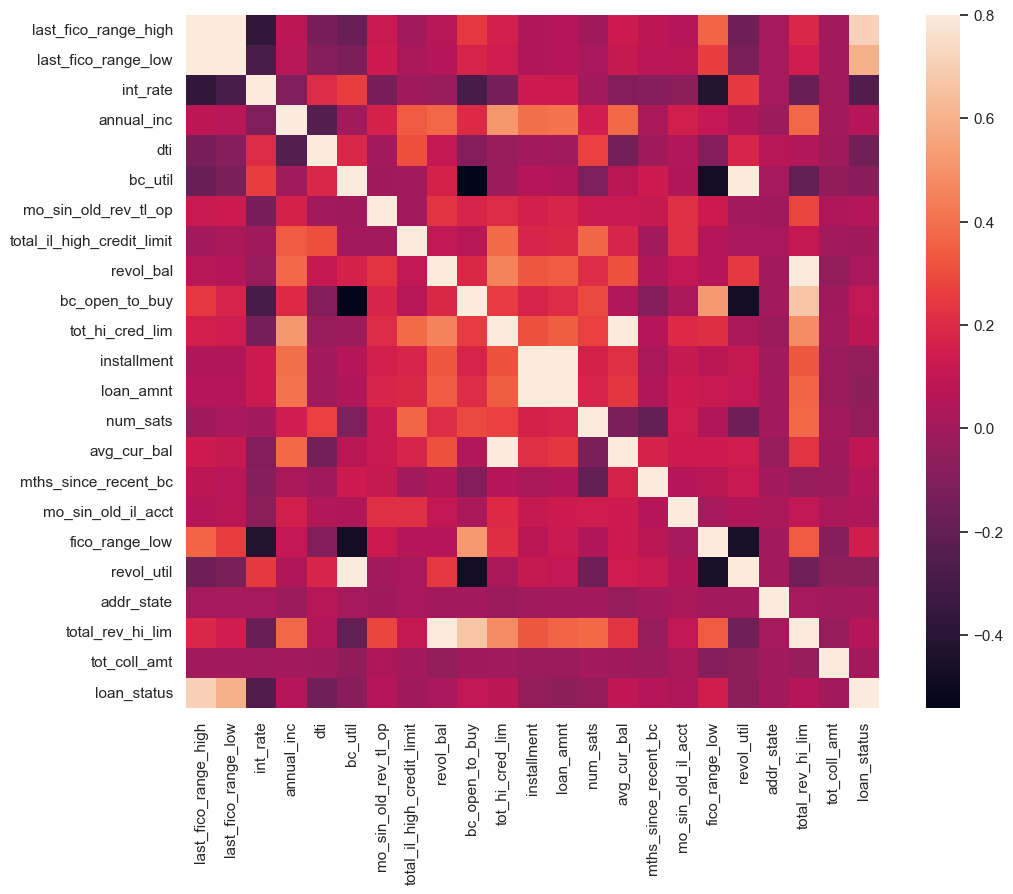

```python
corrmat = Top25DF.corr()
f, ax = plt.subplots(figsize=(12, 9))
sns.heatmap(corrmat, vmax=.8, square=True);
```

I plan to remove one of the features that have a correlation with another such as ...

- last_fico_range_high & last_fico_range_low
- revol_util & bc_util
- revol_bal & total_rev_hi_lim
- tot_high_cred_lim & avg_cur_bal
- loan_amnt & installment
- bc_open_to_buy & total_rev_hi_lim

I will remove the feature that has less importance based on the previous findings.

```python
Top25DF_2 = Top25DF_2.drop(columns = ['last_fico_range_low', 'revol_util', 'total_rev_hi_lim', 'avg_cur_bal', 'loan_amnt', 'bc_open_to_buy'], axis = 1)
Top25DF_2 = Top25DF_2.dropna()
Top25DF_2['loan_status']= df['loan_status']
Top25DF_2 = Top25DF_2.loc[df['loan_status'].isin(['Fully Paid','Charged Off'])]
Top25DF_2['loan_status'] = le.fit_transform(Top25DF_2['loan_status'])
Top25DF_2
```

|  | last_fico_range_high | Days_Last_Cr_Pull | term | int_rate | annual_inc | dti | bc_util | mo_sin_old_rev_tl_op | total_il_high_credit_limit | revol_bal | Days_Earliest_Cr_Line | tot_hi_cred_lim | installment | num_sats | mths_since_recent_bc | mo_sin_old_il_acct | fico_range_low | addr_state | tot_coll_amt | loan_status |
| --- | --- | --- | --- | --- | --- | --- | --- | --- | --- | --- | --- | --- | --- | --- | --- | --- | --- | --- | --- | --- |
| 2 | 704.0 | 306 | 36 | 11.99 | 50000.0 | 29.62 | 66.8 | 166.0 | 78020.0 | 14071.0 | 6667 | 116920.0 | 714.01 | 13.0 | 23.0 | 169.0 | 735.0 | 42 | 0.0 | 1 |
| 3 | 669.0 | 31 | 36 | 13.67 | 64400.0 | 16.68 | 50.9 | 387.0 | 25547.0 | 8057.0 | 12480 | 39547.0 | 340.18 | 9.0 | 3.0 | 54.0 | 675.0 | 38 | 0.0 | 1 |
| 5 | 544.0 | 31 | 60 | 30.74 | 38500.0 | 33.73 | 40.8 | 52.0 | 41935.0 | 12666.0 | 3562 | 64635.0 | 529.88 | 7.0 | 9.0 | 108.0 | 660.0 | 10 | 0.0 | 0 |
| 8 | 754.0 | 31 | 36 | 12.79 | 118000.0 | 26.66 | 83.7 | 240.0 | 22200.0 | 105605.0 | 7762 | 625456.0 | 1175.76 | 31.0 | 9.0 | 145.0 | 665.0 | 4 | 0.0 | 1 |
| 11 | 564.0 | 214 | 36 | 11.99 | 76000.0 | 17.31 | 36.9 | 232.0 | 84285.0 | 12878.0 | 8585 | 115685.0 | 332.10 | 24.0 | 13.0 | 213.0 | 685.0 | 13 | 0.0 | 1 |
| ... | ... | ... | ... | ... | ... | ... | ... | ... | ... | ... | ... | ... | ... | ... | ... | ... | ... | ... | ... | ... |
| 24988 | 704.0 | 579 | 36 | 15.80 | 14988.0 | 23.38 | 45.7 | 309.0 | 0.0 | 5341.0 | 10958 | 10700.0 | 140.24 | 8.0 | 10.0 | 120.0 | 670.0 | 34 | 0.0 | 1 |
| 24991 | 699.0 | 365 | 36 | 11.44 | 140500.0 | 10.10 | 85.2 | 121.0 | 56088.0 | 8181.0 | 5267 | 565688.0 | 98.85 | 7.0 | 18.0 | 159.0 | 700.0 | 19 | 0.0 | 1 |
| 24994 | 774.0 | 31 | 36 | 11.67 | 31000.0 | 21.84 | 69.0 | 378.0 | 103792.0 | 17116.0 | 12753 | 129792.0 | 460.32 | 23.0 | 23.0 | 118.0 | 715.0 | 4 | 0.0 | 1 |
| 24995 | 744.0 | 306 | 36 | 10.16 | 78000.0 | 9.58 | 78.3 | 183.0 | 33279.0 | 10180.0 | 7215 | 263503.0 | 339.60 | 11.0 | 33.0 | 115.0 | 685.0 | 18 | 0.0 | 1 |
| 24996 | 549.0 | 457 | 36 | 14.33 | 82000.0 | 11.75 | 59.8 | 183.0 | 51027.0 | 7711.0 | 8220 | 64327.0 | 412.06 | 12.0 | 14.0 | 211.0 | 690.0 | 32 | 0.0 | 1 |

10860 rows × 20 columns

```python
x, y = Top25DF_2.iloc[:, 0:19], Top25DF_2.iloc[:,19]
```

```python
from sklearn.model_selection import train_test_split
x_train, x_test, y_train, y_test = train_test_split(x, y, test_size=0.3, random_state=42, stratify=y, shuffle=True)
```

```python
# import ML libraries
from sklearn.tree import DecisionTreeClassifier

# Create Decision Tree classifer object
clf = DecisionTreeClassifier(criterion='entropy',random_state=42)

# Train Decision Tree Classifer
clf = clf.fit(x_train, y_train)

#Predict the response for test dataset
y_pred = clf.predict(x_test)
```

```python
y_pred = clf.predict(x_test)
```

**The preivous model and the new model both predicted the likeliness of deafult for 3258 individuals**

```python
from sklearn.metrics import confusion_matrix

cm = confusion_matrix(y_test, y_pred)

tp = float(cm[1][1])
tn = float(cm[0][0])
fp = float(cm[0][1])
fn = float(cm[1][0])

print(cm)
```

```
[[ 513  179]
 [ 193 2373]]
```

There wasn't any significant changes within the sensitivity and specificity. The previous model had a sensitivity of 0.9204988308651598 and the newer model without correlated variables had a slightly higher sensitivity of 0.9247856586126266. Also, the specificity of the prior model was 0.7471098265895953, the newer model had a slight decrease as the specificity was 0.7413294797687862

```python
# Sensitivity: the ability of a test to correctly identify loans that will default.
sensitivity = tp/(tp+fn)

# Specificity: the ability of a test to correctly identify loans that will complete(Without default).
specificity = tn/(tn+fp)

print(sensitivity)
print(specificity)
```

```
0.9247856586126266
0.7413294797687862
```

The overall accuracy has increased slightly which is great to see as highly correlated features were removed as it was 0.883670963781461 in the previous model, but now is 0.8858195211786372.

```python
from sklearn.metrics import accuracy_score
accuracy_score(y_test, y_pred)
```

```
0.8858195211786372
```

```python
Dict = pd.Series(clf.feature_importances_,x_train.columns).to_dict()
Dict
```

```
{'last_fico_range_high': 0.5773701092604889,
 'Days_Last_Cr_Pull': 0.03988462397580368,
 'term': 0.019104815398397205,
 'int_rate': 0.02510207320859036,
 'annual_inc': 0.024018789901809345,
 'dti': 0.028058511742033762,
 'bc_util': 0.025579552094391163,
 'mo_sin_old_rev_tl_op': 0.02159832375629007,
 'total_il_high_credit_limit': 0.02770382845016815,
 'revol_bal': 0.026055070981434128,
 'Days_Earliest_Cr_Line': 0.022520839671911985,
 'tot_hi_cred_lim': 0.030137762156779886,
 'installment': 0.0266402183968252,
 'num_sats': 0.018891155997754865,
 'mths_since_recent_bc': 0.019549490133572524,
 'mo_sin_old_il_acct': 0.016604594269439638,
 'fico_range_low': 0.02000736019950159,
 'addr_state': 0.025244247460792398,
 'tot_coll_amt': 0.005928632944015018}
```

```python
Top25DF_2.corr()
```

|  | last_fico_range_high | int_rate | annual_inc | dti | bc_util | mo_sin_old_rev_tl_op | total_il_high_credit_limit | revol_bal | tot_hi_cred_lim | installment | num_sats | mths_since_recent_bc | mo_sin_old_il_acct | fico_range_low | addr_state | tot_coll_amt | loan_status |
| --- | --- | --- | --- | --- | --- | --- | --- | --- | --- | --- | --- | --- | --- | --- | --- | --- | --- |
| last_fico_range_high | 1.000000 | -0.367850 | 0.077578 | -0.127448 | -0.179012 | 0.124297 | 0.001167 | 0.066162 | 0.155747 | 0.038301 | -0.009115 | 0.086329 | 0.058439 | 0.363727 | 0.013617 | 0.000071 | 0.706508 |
| int_rate | -0.367850 | 1.000000 | -0.106257 | 0.198548 | 0.258168 | -0.128702 | -0.010490 | -0.029802 | -0.134259 | 0.132839 | 0.000839 | -0.086681 | -0.069260 | -0.418858 | 0.014311 | -0.005344 | -0.259209 |
| annual_inc | 0.077578 | -0.106257 | 1.000000 | -0.245633 | -0.006082 | 0.162108 | 0.337392 | 0.374544 | 0.508415 | 0.396239 | 0.141810 | 0.028903 | 0.151855 | 0.104860 | -0.018762 | 0.000375 | 0.051224 |
| dti | -0.127448 | 0.198548 | -0.245633 | 1.000000 | 0.184846 | 0.008210 | 0.307268 | 0.112900 | -0.029674 | -0.000382 | 0.262114 | -0.013442 | 0.047854 | -0.092716 | 0.062656 | -0.011990 | -0.152926 |
| bc_util | -0.179012 | 0.258168 | -0.006082 | 0.184846 | 1.000000 | -0.013033 | 0.007243 | 0.162339 | -0.021148 | 0.055540 | -0.115657 | 0.130455 | 0.045354 | -0.473039 | 0.012175 | -0.051025 | -0.083827 |
| mo_sin_old_rev_tl_op | 0.124297 | -0.128702 | 0.162108 | 0.008210 | -0.013033 | 1.000000 | 0.005344 | 0.227159 | 0.198360 | 0.155474 | 0.124138 | 0.116672 | 0.213770 | 0.125905 | -0.013688 | 0.034071 | 0.051420 |
| total_il_high_credit_limit | 0.001167 | -0.010490 | 0.337392 | 0.307268 | 0.007243 | 0.005344 | 1.000000 | 0.096082 | 0.381023 | 0.177003 | 0.366718 | 0.002692 | 0.215706 | 0.059064 | 0.015235 | 0.005105 | -0.016926 |
| revol_bal | 0.066162 | -0.029802 | 0.374544 | 0.112900 | 0.162339 | 0.227159 | 0.096082 | 1.000000 | 0.450854 | 0.326238 | 0.205604 | 0.040890 | 0.098821 | 0.051953 | 0.005370 | -0.045097 | 0.018800 |
| tot_hi_cred_lim | 0.155747 | -0.134259 | 0.508415 | -0.029674 | -0.021148 | 0.198360 | 0.381023 | 0.450854 | 1.000000 | 0.310320 | 0.260751 | 0.061207 | 0.194874 | 0.208919 | -0.024839 | -0.005927 | 0.086811 |
| installment | 0.038301 | 0.132839 | 0.396239 | -0.000382 | 0.055540 | 0.155474 | 0.177003 | 0.326238 | 0.310320 | 1.000000 | 0.165436 | 0.024378 | 0.115081 | 0.074818 | -0.003069 | -0.024884 | -0.047189 |
| num_sats | -0.009115 | 0.000839 | 0.141810 | 0.262114 | -0.115657 | 0.124138 | 0.366718 | 0.205604 | 0.260751 | 0.165436 | 1.000000 | -0.193523 | 0.134896 | 0.039767 | 0.008746 | 0.004373 | -0.042935 |
| mths_since_recent_bc | 0.086329 | -0.086681 | 0.028903 | -0.013442 | 0.130455 | 0.116672 | 0.002692 | 0.040890 | 0.061207 | 0.024378 | -0.193523 | 1.000000 | 0.051300 | 0.074795 | 0.007128 | -0.019269 | 0.054369 |
| mo_sin_old_il_acct | 0.058439 | -0.069260 | 0.151855 | 0.047854 | 0.045354 | 0.213770 | 0.215706 | 0.098821 | 0.194874 | 0.115081 | 0.134896 | 0.051300 | 1.000000 | 0.013665 | 0.019756 | 0.024531 | 0.031438 |
| fico_range_low | 0.363727 | -0.418858 | 0.104860 | -0.092716 | -0.473039 | 0.125905 | 0.059064 | 0.051953 | 0.208919 | 0.074818 | 0.039767 | 0.074795 | 0.013665 | 1.000000 | 0.004755 | -0.090333 | 0.146206 |
| addr_state | 0.013617 | 0.014311 | -0.018762 | 0.062656 | 0.012175 | -0.013688 | 0.015235 | 0.005370 | -0.024839 | -0.003069 | 0.008746 | 0.007128 | 0.019756 | 0.004755 | 1.000000 | -0.004276 | 0.003295 |
| tot_coll_amt | 0.000071 | -0.005344 | 0.000375 | -0.011990 | -0.051025 | 0.034071 | 0.005105 | -0.045097 | -0.005927 | -0.024884 | 0.004373 | -0.019269 | 0.024531 | -0.090333 | -0.004276 | 1.000000 | 0.005138 |
| loan_status | 0.706508 | -0.259209 | 0.051224 | -0.152926 | -0.083827 | 0.051420 | -0.016926 | 0.018800 | 0.086811 | -0.047189 | -0.042935 | 0.054369 | 0.031438 | 0.146206 | 0.003295 | 0.005138 | 1.000000 |

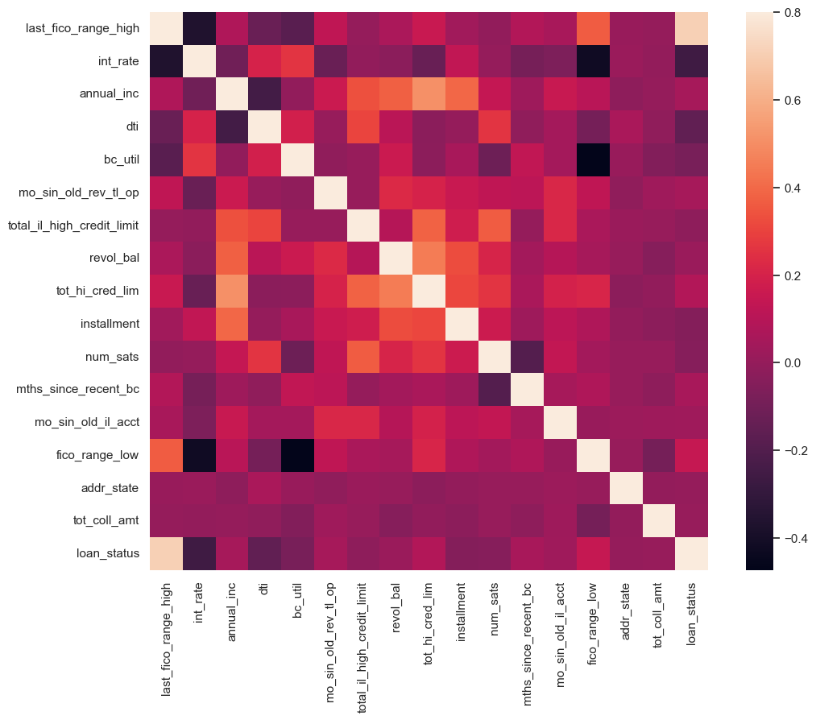

```python
corrmat = Top25DF_2.corr()
f, ax = plt.subplots(figsize=(12, 9))
sns.heatmap(corrmat, vmax=.8, square=True);
```